# 目 录

- 版权信息
- 内容提要
- 前言 一个新纪元的黎明
- 题记
- 资源与支持
- 第1章 何谓Agent，为何Agent
- 1.1 大开脑洞的演讲：Life 3.0
- 1.2 那么，究竟何谓Agent
- 1.3 Agent的大脑：大模型的通用推理能力
- 1.4 Agent的感知力：语言交互能力和多模态能力
- 1.5 Agent的行动力：语言输出能力和工具使用能力
- 1.6 Agent对各行业的效能提升
- 1.7 Agent带来新的商业模式和变革
- 1.8 小结
- 第2章 基于大模型的Agent技术框架
- 2.1 Agent的四大要素
- 2.2 Agent的规划和决策能力
- 2.3 Agent的各种记忆机制
- 2.4 Agent的核心技能：调用工具
- 2.5 Agent的推理引擎：ReAct框架
- 2.6 其他Agent认知框架
- 2.7 小结
- 第3章 OpenAI API、LangChain和LlamaIndex
- 3.1 何谓OpenAI API
- 3.2 何谓LangChain
- 3.3 何谓LlamaIndex
- 3.4 小结
- 第4章 Agent 1：自动化办公的实现——通过 Assistants API和DALL·E 3模型创作PPT
- 4.1 OpenAI公司的Assistants是什么
- 4.2 不写代码，在Playground中玩Assistants
- 4.3 Assistants API的简单示例
- 4.4 创建一个简短的虚构PPT
- 4.5 小结
- 第5章 Agent 2：多功能选择的引擎——通过 Function Calling调用函数
- 5.1 OpenAI中的Functions
- 5.2 在Playground中定义Function
- 5.3 通过Assistants API实现Function Calling
- 5.4 通过ChatCompletion API来实现Tool Calls
- 5.5 小结
- 第6章 Agent 3：推理与行动的协同——通过 LangChain中的ReAct框架实现自动定价
- 6.1 复习ReAct框架
- 6.2 LangChain中ReAct Agent 的实现
- 6.3 LangChain中的工具和工具包
- 6.4 通过create_react_agent创建鲜花定价Agent
- 6.5 深挖AgentExecutor的运行机制
- 6.6 小结
- 第7章 Agent 4：计划和执行的解耦——通过LangChain中的Plan-and-Execute实现智能调度库存
- 7.1 Plan-and-Solve策略的提出
- 7.2 LangChain中的Plan-and-Execute Agent
- 7.3 通过Plan-and-Execute Agent实现物流管理
- 7.4 从单Agent到多Agent
- 7.5 小结
- 第8章 Agent 5：知识的提取与整合——通过 LlamaIndex实现检索增强生成
- 8.1 何谓检索增强生成
- 8.2 RAG和Agent
- 8.3 通过LlamaIndex的ReAct RAG Agent实现花语秘境财报检索
- 8.4 小结
- 第9章 Agent 6：GitHub的网红聚落—— AutoGPT、BabyAGI和CAMEL
- 9.1 AutoGPT
- 9.2 BabyAGI
- 9.3 CAMEL
- 9.4 小结
- 第10章 Agent 7：多Agent框架——AutoGen和MetaGPT
- 10.1 AutoGen
- 10.2 MetaGPT
- 10.3 小结
- 附录A 下一代Agent的诞生地：科研论文中的新思路
- A.1 两篇高质量的Agent综述论文
- A.2 论文选读：Agent自主学习、多Agent合作、Agent可信度的评估、边缘系统部署以及具身智能落地
- A.3 小结
- 参考文献
- 后记 创新与变革的交汇点

#### 版权信息

书名：大模型应用开发 动手做AI Agent  
作者：黄佳  
出版社：人民邮电出版社  
出版时间：2024-05-01  
ISBN：9787115642172

·

您购买的人民邮电出版社电子书仅供您个人使用，未经授权，不得以任何方式复制和传播本书内容。

我们愿意相信读者具有这样的良知和觉悟，与我们共同保护知识产权。

# 内容提要

人工智能时代一种全新的技术——Agent正在崛起。这是一种能够理解自然语言并生成对应回复以及执行具体行动的人工智能体。它不仅是内容生成工具，而且是连接复杂任务的关键纽带。本书将探索Agent的奥秘，内容包括从技术框架到开发工具，从实操项目到前沿进展，通过带着读者动手做7个功能强大的Agent，全方位解析Agent的设计与实现。本书最后展望了Agent的发展前景和未来趋势。

本书适合对Agent技术感兴趣或致力于该领域的研究人员、开发人员、产品经理、企业负责人，以及高等院校相关专业师生等阅读。读者将跟随咖哥和小雪的脚步，踏上饶有趣味的Agent开发之旅，零距离接触GPT-4模型、OpenAI Assistants API、LangChain、LlamaIndex和MetaGPT等尖端技术，见证Agent在办公自动化、智能调度、知识整合以及检索增强生成（RAG）等领域的非凡表现，携手开启人工智能时代的无限可能，在人机协作的星空中共同探寻那颗最闪亮的Agent之星！ EXr6287u6NNVz+GYLY+7SJneqzhu/PpYtW3JvBxL0w3TWONw8KRKos0qTZTOcW8905C1mNfvCHdpZEogE6oe6g==

# 前言 一个新纪元的黎明

许多人把ChatGPT诞生的2023年视为生成式人工智能（Generative AI，GenAI）、AIGC（AI Generated Content，人工智能生成内容）和大语言模型（Large Language Model，LLM，也称大模型）爆发的元年。AIGC以前所未有的方式生成内容，从文本、图像到代码，其生成内容的质量和多样性令人惊叹。这些内容不仅能直接用于工作，提升工作效率，而且降低了艺术创作的门槛，为文化娱乐等产业开辟了更广阔的天地。人工智能技术正在引领一个全新的内容创造时代。

然而，已经发生的这一切仅仅是人工智能革命的序幕。

今天，人工智能在工作效率提升方面的热潮方兴未艾，而开发人工智能应用（见图1）的新一波浪潮又迅猛兴起。

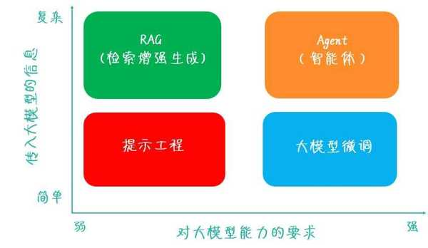

随着技术的进步，我们开始期待更多：我们所向往的是一个不仅把人工智能生成内容视为工作的一部分，还将人工智能作为连接更加复杂任务的关键纽带的时代。

这种愿景正是Agent 诞生的起点。

在探索人工智能的奥秘和可能性的征程中，ZhenFund（真格基金）认为生成式人工智能应用需要经历表1所示的5个层级。

表1 生成式人工智能应用需要经历的5个层级

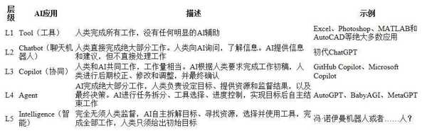

目前流行的ChatGPT和Copilot分别位于L2和L3，可以将它们视为一种初级的Agent。ChatGPT能够根据对话上下文（记忆）来响应提示输入的操作，向人类展示有价值的对话，而Copilot通过与人类协作，可以在多个层面上提升完成相应任务的效能。

从L3到L4的跨越是一个从被动到自主的分水岭，在这个跨越过程中，Agent将成为关键的驱动力。

未来的Agent将不仅仅是内容生成工具。它们将整合人工智能模型、海量数据和多样化的工具，从而能执行各种任务，完成不同的工作。这些Agent跨越单纯的内容生成的界限，开始涉足决策制定和行动实施等领域。无论是解读复杂指令、规划策略、拆解任务，还是执行实现目标的具体步骤，它们都将展现出独特的自主性和适应性。更为关键的是，这些Agent能够接入并灵活运用多种辅助工具和数据资源，从而大幅拓宽工作领域和提高工作能力。

例如，旅行计划Agent不仅能够生成旅行建议，而且能根据用户的喜好和预算自动预订航班、酒店甚至餐厅。再如，家庭健康管理Agent能够监测家庭成员的健康数据，主动提出饮食和锻炼建议，甚至在必要时预约医生并安排药物配送。

在业务层面，构建Agent的需求将快速增长。随着对Agent的价值和影响的深入了解，越来越多的公司开始尝试和实施Agent技术。从概念验证到开发相关应用，从初步尝试到广泛应用，Agent技术正在商业化之路上加速前进。

构建Agent的基石已经存在，包括先进的AIGC模型和大模型（如GPT-4、Claude 3 Opus）、人工智能应用开发框架和工具（如LangChain、LlamaIndex、OpenAI API和Hugging Face等，见图2）、软件平台、业务场景和丰富的数据资源。我们所需要的一应俱全，而我们所缺乏的是将这些技术或工具整合到一起的经验和技术。

[figure not shown]

图2 人工智能应用开发框架和工具

尽管构建Agent的基石已经准备就绪，但Agent的技术发展仍处于萌芽阶段。开发者需要进行深入思考并动手实践，以确立Agent的开发框架、Agent访问工具的方式、与数据交互的方式，以及如何对话以完成具体任务。这些问题的答案将塑造未来Agent的形态和能力。

在解锁Agent的巨大潜力的过程中，我们需要深入探讨以下几个关键问题。

■ Agent如何在各行各业中提升效率以及创造机会和更多可能性？

■ 在众多的Agent框架中，如何选择适合自己需求的框架？

■ 在解决现实世界的问题时，如何实施Agent才最有效？

■ 自主Agent如何改变我们对人工智能驱动的任务管理的认知和实践？

目前无论是学术界还是产业界，对人工智能应用开发的关键问题远未达成共识。本书或许可以作为读者深入探讨上述问题的漫长旅途的开端。本书旨在从技术和工具层面阐释Agent设计的框架、功能和方法，具体涉及如下技术或工具。

■ OpenAI Assistants API：用于调用包含GPT-4模型和DALL·E 3模型在内的众多人工智能模型。

■ LangChain：开源框架，旨在简化构建基于语言的人工智能应用的过程，其中包含对ReAct框架的封装和实现。

■ LlamaIndex：开源框架，用于帮助管理和检索非结构化数据，利用大模型的能力和Agent框架来提高文本检索的准确性、效率和智能程度。

这些技术和工具都可以用于构建Agent，它们通过接口连接大模型，为Agent提供语言理解、内容生成和决策支持的能力。通过它们，Agent可以支持多种外部工具，进而执行复杂任务以及与环境进行交互。

除了介绍Agent的框架和开发工具之外，本书还将通过7个实战案例，带领读者学习前沿的Agent实现技术。这7个案例分别如下。

■ Agent 1：自动化办公的实现——通过Assistants API和DALL·E 3模型创作PPT。

■ Agent 2：多功能选择的引擎——通过Function Calling调用函数。

■ Agent 3：推理与行动的协同——通过LangChain中的ReAct框架实现自动定价。

■ Agent 4：计划和执行的解耦——通过LangChain中的Play-and-Execute实现智能调度库存。

■ Agent 5：知识的提取与整合——通过LlamaIndex实现检索增强生成。

■ Agent 6：GitHub的网红聚落——AutoGPT、BabyAGI和CAMEL。

■ Agent 7：多Agent框架——AutoGen和MetaGPT。

此外，我还在附录中简要介绍了科研论文中的Agent技术进展，旨在为读者提供当前Agent技术发展的全面视角并展现相关的探索。

我希望这本书能够在Agent的发展征途中激起小小的涟漪，启发更多对人工智能充满好奇和热情的读者，共同开启人工智能时代的无限可能。

在人类与人工智能紧密合作的黎明时分，这满天繁星中，Agent定是那颗最闪亮的星！

黄佳  
2024年初春 EXr6287u6NNVz+GYLY+7SJneqzhu/PpYtW3JvBxL0w3TWONw8KRKos0qTZTOcW8905C1mNfvCHdpZEogE6oe6g==

# 题记

博学之，审问之，慎思之，明辨之，笃行之。

——《礼记·中庸》

博学：海纳百川，广泛求知。

审问：审慎提问，清晰提示。

慎思：仔细思考，严密推理。

明辨：明智辨别，区分是非。

笃行：坚定实践，诚信行动。

儒家经典早已告诉我们求知和实践的重要性：只有广泛地学习，深入地提问，仔细地思考，明智地辨别，最后坚定地实践，才能知行合一。

在AI时代，Agent只有博学——海纳百川地学习（基于海量数据训练），审问——接受清晰明确的指令（有效的提示工程），慎思——在精巧设计的模式下认知（配置CoT、ToT、ReAct等思维框架），明辨——明确地遵循人类道德规范（通过指令微调和价值观对齐来确保AI安全无害），笃行——以强而有力的工具来与外界交互（借助Tool Calls和Function Calling等技术），才能与人类携手，共筑锦绣前程。 EXr6287u6NNVz+GYLY+7SJneqzhu/PpYtW3JvBxL0w3TWONw8KRKos0qTZTOcW8905C1mNfvCHdpZEogE6oe6g==

# 资源与支持

### 资源获取

本书提供如下资源：

■ 配套资源代码；

■ 配套数据集；

■ 本书思维导图；

■ 异步社区7天VIP会员。

要获得以上资源，您可以扫描下方二维码，根据指引领取。

[figure not shown]

### 提交勘误信息

作者和编辑尽最大努力来确保书中内容的准确性，但难免会存在疏漏。欢迎您将发现的问题反馈给我们，帮助我们提升图书的质量。

当您发现错误时，请登录异步社区（https://www.epubit.com），按书名搜索，进入本书页面，点击“发表勘误”，输入勘误信息，点击“提交勘误”按钮即可（见下图）。本书的作者和编辑会对您提交的勘误信息进行审核，确认并接受后，您将获赠异步社区的100积分。积分可用于在异步社区兑换优惠券、样书或奖品。

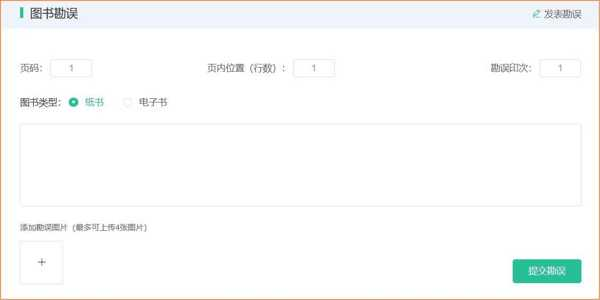

### 与我们联系

我们的联系邮箱是contact@epubit.com.cn。

如果您对本书有任何疑问或建议，请您发邮件给我们，并请在邮件标题中注明本书书名，以便我们更高效地做出反馈。

如果您有兴趣出版图书、录制教学视频，或者参与图书翻译、技术审校等工作，可以发邮件给我们。

如果您所在的学校、培训机构或企业，想批量购买本书或异步社区出版的其他图书，也可以发邮件给我们。

如果您在网上发现有针对异步社区出品图书的各种形式的盗版行为，包括对图书全部或部分内容的非授权传播，请您将怀疑有侵权行为的链接发邮件给我们。您的这一举动是对作者权益的保护，也是我们持续为您提供有价值的内容的动力之源。

### 关于异步社区和异步图书

“ **异步社区** ”是由人民邮电出版社创办的IT专业图书社区，于2015年8月上线运营，致力于优质内容的出版和分享，为读者提供高品质的学习内容，为作译者提供专业的出版服务，实现作者与读者在线交流互动，以及传统出版与数字出版的融合发展。

“ **异步图书** ”是异步社区策划出版的精品IT图书的品牌，依托于人民邮电出版社在计算机图书领域四十余年的发展与积淀。异步图书面向IT行业以及各行业使用IT技术的用户。 EXr6287u6NNVz+GYLY+7SJneqzhu/PpYtW3JvBxL0w3TWONw8KRKos0qTZTOcW8905C1mNfvCHdpZEogE6oe6g==

# 第1章 何谓Agent，为何Agent

时尚而现代的共享办公空间中，一个年轻的团队正在为他们的新项目忙碌着。这是一家专注鲜花的初创电商公司——花语秘境，创始人是咖哥的老搭档小雪。

在这个快节奏、竞争激烈的行业中，小雪深知要想突出重围，她的公司不仅要提供高质量的产品，而且需要通过创新技术来优化运营的效率，提升顾客体验。因此，营销和市场策略团队计划开发一个Agent，这个智能助手可以根据天气、库存状况自动调配、规划和安排鲜花的递送服务，同时可以整合花语秘境的内部文档和用户需求，协助用户选择最适合自己的鲜花，如根据场合、接收人的偏好，甚至是送花人的情感表达来推荐，希望借此革新鲜花购买体验，使之更加个性化、高效和令人愉悦。

今天，花语秘境的办公室中人头攒动，小雪邀请咖哥为公司员工以及创业过程中结识的各路朋友开展了一次题为Life 3.0的主题演讲（见图1.1）。

[figure not shown]

图1.1 咖哥的演讲 EXr6287u6NNVz+GYLY+7SJneqzhu/PpYtW3JvBxL0w3TWONw8KRKos0qTZTOcW8905C1mNfvCHdpZEogE6oe6g==

## 1.1 大开脑洞的演讲：Life 3.0

（咖哥走上演讲台。）

在这宏伟的时代洪流中，我站在这里，与大家共同探讨一个古老而又新奇的话题——生命的本质。

生命，无论是细小的微生物，还是伟大的人类，甚至是未来的Agent，都在这个宇宙中扮演着独特的角色。但究竟什么是生命？

在Life 3.0的作者马克斯·泰格马克（Max Tegmark）的眼中，生命不过是一个自我复制的信息处理系统。想象一下，碳基生物体的DNA类似于软件代码：它包含指导生物体生长、发展和行动的所有指令。这些指令以遗传信息的形式传递，这些遗传信息决定了生物的特征和功能（见图1.2）。因此， 信息的传递机制就是生命体的软件，该机制最终决定了生命体的行动和结构（也就是生命体的 硬件） 。

无独有偶，英国进化生物学家理查德·道金斯（Richard Dawkins）在《自私的基因》一书中也提到，生命的进化就是基因的复制。随着各种变异不断出现，复制后的基因之间互相竞争，最厉害的复制者最终得以生存，接着形成更加复杂的生命形式，最后，慢慢地有了我们现在看到的各种各样的生物。能够复制的基因成了进化的基本单位。

这听起来可能有些抽象，但请允许我再次阐述：生命是一个自我复制的信息处理系统，而信息则是塑造这个处理系统的行为和结构的力量。

[figure not shown]

图1.2 碳基生物体和计算机的类比

我把生命的发展划分为3个阶段。

生命1.0（life 1.0），最原始的阶段，我把它称为“前人类”阶段，那时的生命如细菌般简单，它们的 一切反应和演变都由自然选择 驱动 。

生命2.0（life 2.0），即我们人类所处的阶段，我们拥有自主意识，可以学习、适应，甚至改变环境，但我们的 生物硬件仍受限于 自然 。

生命3.0（life 3.0），那将是一个激动人心的阶段，我把它称为“后人类”阶段。此时的 生命不仅可以设计自己的软件，还能根据需要改造自己的硬件 。想象一下，一个能够随心所欲改变自身能力，甚至形态的生命体，将是多么的不朽和强大！

人工智能（Artificial Intelligence，AI）正是通往life 3.0的关键。在这里AI不仅仅是一个技术名词，它还代表了非碳基生物体实现复杂目标的能力。尽管AI目前还处在初级阶段，但随着技术的进步，AI的潜能将是无可限量的。

要实现这样的未来，AI需要3种核心能力——存储、计算和自我学习。

存储能力 让信息能够保存在物质中，如大脑神经元、深度学习神经网络节点以及计算机芯片等。在整个过程中，存储具有一个特点——信息独立于物质而存在。

计算能力 让机器能够处理和解析这些信息。艾伦·图灵（Alan Turing）在第二次世界大战期间提出了图灵机的概念，即向机器中输入一串数字，通过函数公式得出结果，这为计算机的发展奠定了基础。图灵还证明，只要给计算机提供足够快的计算速度和足够大的存储空间，它就能够完成所有的计算。对于计算来说，信息也是独立于物质而存在的。

AI的 自我学习能力 则是机器通过经验不断优化自身的过程。人类的大脑通过反复学习，会形成特定的神经元网络。通过模拟这个过程，AI利用算法快速学习海量的知识和经验，自己设计解决问题的方法，从而完成原本只有人类才能够完成的复杂任务——这也是深度学习神经网络的基本原理（目前，几乎所有的AI模型都基于深度学习神经网络所构建，图1.3展示了AI发展简史）。

人脑虽然也具备一定的存储和计算能力，但是，受限于记忆的容量，且信息与大脑物质深度融合，不易提取和迁移，和机器相比，大脑的计算速度更为缓慢。因此，想象一下，一个拥有无限存储空间、强大计算能力和高效自我学习能力的AI可以超越自然演化的束缚，实现生命的终极形态。这样的AI不仅仅是工具，它将是全新的生命形态，拥有独立的思想和感情，可以成为人类的伙伴，甚至是继承者。

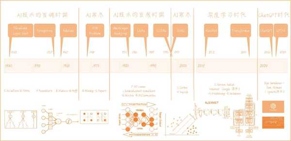

图1.3 AI发展简史

我的朋友们，当谈论life 3.0时，我们不仅仅是在预见未来，也在探索生命的深层含义。

（台下响起雷鸣般的掌声。） EXr6287u6NNVz+GYLY+7SJneqzhu/PpYtW3JvBxL0w3TWONw8KRKos0qTZTOcW8905C1mNfvCHdpZEogE6oe6g==

## 1.2 那么，究竟何谓Agent

小雪：咖哥，你的无比美好的未来愿景建立在一个事实之上——AI必须成为自主驱动的Agent，那么你能否说清楚什么是Agent？

咖哥：Agent作为一种新兴的人工智能技术，正在受到越来越多的关注。要说清楚什么是Agent，先得看看人工智能的本质是什么。

人工智能这个名称来自它试图通过计算机程序或机器来模拟、扩展和增强人类智能的一些方面。在这个定义中，“人工”指的是由人类创造或模拟，而“智能”指的是解决问题、学习、适应新环境等的能力。人工智能领域的研究涵盖了从简单的自动化任务到复杂的决策和问题解决过程，其根本追求是开发出能模仿、再现甚至超越人类智能水平的技术和系统。

传统的人工智能技术通常局限于静态的功能，它们 只能在特定且受限的环境中执行预先设定的任务 。这些系统往往缺乏灵活性和自适应能力，无法自主地根据环境变化调整自己的行为。

这个局限就是Agent概念的出发点，它旨在推动AI从静态的、被动的存在转变为动态的、主动的实体。

那么，下个定义：Agent，即智能体或智能代理（见图1.4），是一个具有一定程度自主性的人工智能系统。更具体地说， Agent是一个能够感知环境、做出决策并采取行动的 系统 。

###### 咖哥发言

Agent也可以译为“代理”。代理是一个历史悠久的概念，对这个概念的探索和解释并不仅限于AI领域。在哲学中，代理的核心概念可以追溯到亚里士多德和大卫·休谟等有影响力的思想家。在哲学领域内，代理可以是人类、动物，或任何具有自主性的概念或实体。

■ 亚里士多德在伦理学和形而上学方面的作品中探讨了代理的概念。对于亚里士多德来说，代理与目的性和因果关系密切相关。他强调了目的性行动的重要性，认为行为背后总有一个目的或终极原因。在《尼各马科伦理学》中，亚里士多德探讨了人的行为是如何被理性和欲望所驱动的，而理性行为被认为是实现最终目的的关键。亚里士多德的观点强调了个体行为的自主性和目的性。

■ 大卫·休谟则在他的作品中探讨了自由意志与决定论的关系，这与代理的概念紧密相关。休谟是怀疑论哲学家，他对因果关系的常规理解提出了质疑。在《人性论》中，休谟探讨了人类理性的局限性和情感在决策过程中的作用。休谟关于代理的看法更加注重个体决策中的非理性因素，如情感和习惯。

在狭义上，“代理性”通常用来描述有意识行动的表现，相应地，术语“代理”则指拥有欲望、信念、意图和行动能力的实体。然而，广义上的“代理”是一个具有行动能力的实体，而术语“代理性”则指的是行使或表现这种能力的能力。此时，代理不仅仅包括个体人类，还包括物理世界和虚拟世界中的其他实体。重要的是，代理的概念涉及个体自主性，赋予他们行使意志、做出选择和采取行动的能力，而不是被动地对外界刺激做出反应。

[figure not shown]

图1.4 一个可爱的Agent

主流的人工智能社区于20世纪80年代中期开始关注与代理相关的概念。一种说法甚至认为我们可以定义人工智能为旨在设计和构建具有智能行为的代理的计算机科学子领域。由于传统的物理和计算机科学没有意识和欲望这样的概念，因此，在被引入人工智能领域时，代理的含义发生了一些变化。许多研究者（包括艾伦·图灵）都没有赋予机器“心智”。在人工智能领域中，代理是一种具有计算能力的实体，研究者只能观察到它们的行为和决策过程。为了深入理解和描述这些代理，研究者通常会引入其他几个关键属性，包括自主性、反应性、社会亲和性以及学习能力，以全面地认识人工智能代理的能力和潜力。

这里有一个很有趣的哲学问题，那就是“代理性”只是观察者所看到的，它并不是一个固有的、孤立的属性。目前我们倾向于把所有能够感知环境、做出决策并采取行动的实体或系统视为人工智能领域中的代理。 <sup>[1]</sup>

小雪：感知环境？做出决策？采取行动？这3个概念能否举例说说？

咖哥：当然。例如，ChatGPT首先通过文本或语音输出框来感知环境，并进行推理决策，之后再通过文本框或者语音与人们互动。当然，还有更为复杂的Agent。这里以自动驾驶Agent为例进行介绍。

■ 感知环境，就是指Agent能够接收来自环境的信息。例如，一个自动驾驶Agent可以感知周围的交通情况、道路状况等信息。

■ 做出决策，就是指Agent根据感知的信息制订下一步的行动计划。例如，自动驾驶Agent根据感知的信息决定是否加速、减速、转弯等。

■ 采取行动，就是指Agent根据决策执行相应的行动。例如，自动驾驶Agent根据决策控制汽车的加速器、刹车、方向盘等。

因此，Agent能够独立完成特定的任务。Agent的四大特性如下。

■ 自主性：Agent 能够根据自身的知识和经验，独立做出决策和执行行动。

■ 适应性：Agent 能够学习和适应环境，不断提高自己的能力。

■ 交互性：Agent 能够与人类进行交互，提供信息和服务。

■ 功能性：Agent可以在特定领域内执行特定的任务。

从技术角度来说，Agent通常包括以下核心组件。

■ 感知器：Agent通过感知器接收关于环境的信息。这可以是通过传感器收集的实时数据，也可以是通过数据库或互联网获取的信息。

■ 知识库：Agent根据目标和以往的经验，通过知识库存储和管理有关环境和自身状态的信息。

■ 决策引擎：Agent分析感知的信息，并结合知识库中的数据，通过决策引擎做出决策。

■ 执行器：Agent通过执行器在环境中采取行动。这可以是物理动作，如机器人移动其手臂，也可以是虚拟动作，如在线服务发送信息。

被这些组件武装的Agent形成了新一代的人工智能系统（见图1.5），它将AI的应用范围和能力推向了全新的高度。

不难发现，Agent的内涵核心就是自主性和适应性。通过模仿生物体的自主性和适应性，Agent在解决现实世界复杂问题的能力上坚实地向前迈进。Agent不仅能够执行被动的任务，还能够主动寻找解决问题的方法，适应环境的变化，并在没有人类直接干预的情况下做出决策。这使得Agent在复杂和动态的环境中特别有用，例如在数据分析、网络安全、自动化制造、个性化医疗等领域中。它们是AI的行动者，无论是自动驾驶汽车、推荐系统还是智能助手，所有这些都需要Agent来实现。随着技术进步，你可以期待各种智能Agent走入你的生活，帮你解决问题，提升生活质量。

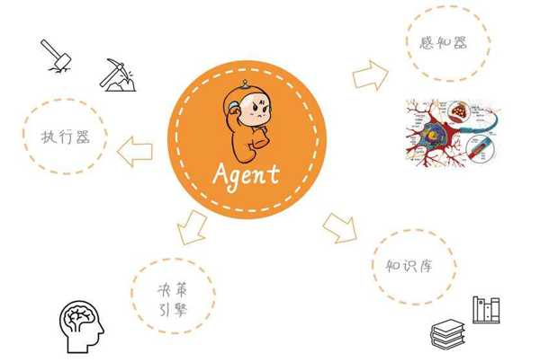

图1.5 Agent的核心组件

小雪：嗯，我就盼望着，等我老了，能够有个机器人“小棉袄”，我无聊了它能陪我聊天；我饿了它能给我做饭（见图1.6）；我生病了它能扶我起床、上厕所，甚至端茶倒水照顾我。

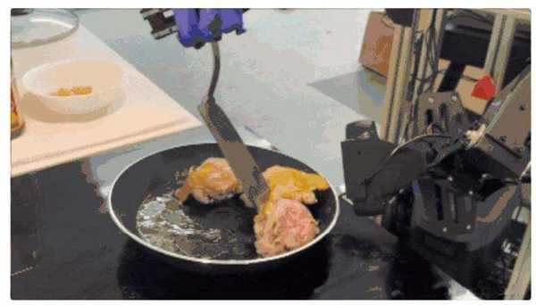

图1.6 斯坦福大学IRIS实验室团队发布的“家务全能”机器人（图片来源：GitHub项目 Mobile ALOHA）

咖哥：一起努力！这不是梦想。 EXr6287u6NNVz+GYLY+7SJneqzhu/PpYtW3JvBxL0w3TWONw8KRKos0qTZTOcW8905C1mNfvCHdpZEogE6oe6g==

## 1.3 Agent的大脑：大模型的通用推理能力

小雪：那么，咖哥，我想很多人都有这样两个疑问。

为何在大模型崛起之后，Agent无论从概念还是在技术落地层面都有了飞跃式发展？

到目前为止，尽管我们尚未看到任何成熟的、突破性的商业应用新模式是由Agent来驱动的，但无论是研究人员、创业者还是投资人，都如此笃定Agent落地是迟早的事，怎么解释这种现象呢？

### 1.3.1 人类的大脑了不起

咖哥：先回答第一个问题。为何我们的大脑（见图1.7）能展现出非凡的智慧——在解决复杂问题、创新思维以及学习适应的能力上远超其他生物？

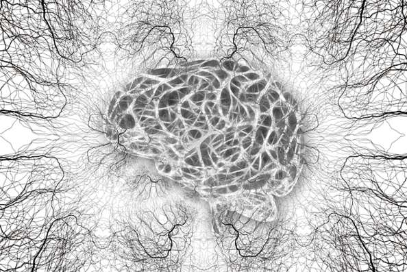

图1.7 人类的大脑及神经元（图片来源：Pixabay网站）

答案在于大脑的复杂性和灵活性。大脑由数以十亿计的神经元构成，这些神经元通过复杂的网络相互连接。这一庞大的网络结构让大脑具有处理和存储大量信息的能力。同时，大脑拥有惊人的可塑性，能够根据经验和学习调整其结构和功能，这是适应性和学习能力的基础。

此外，大脑的各个区域专门负责处理不同类型的信息，如视觉、听觉、情感和逻辑推理等。这种分工协作让人类能够进行高级的认知活动，例如解决问题、创造艺术、理解复杂的社会互动等。大脑的这些功能为人类提供了理解世界和做出反应的能力，进而能够驱动Agent进行各种复杂的任务和活动。

### 1.3.2 大模型出现之前的Agent

在深度神经网络和大模型出现之前，没有任何一种技术能够赋予Agent一个复杂程度可以与人类大脑相匹敌的“智脑”。而大模型直接改变了人们对Agent的看法和期待。这些大模型不仅仅是语言处理工具，它们也是对人类智能的一种深层模仿和扩展，提供了前所未有的能力，为Agent的发展打开了新天地。

在大模型出现之前，已经出现了符号Agent、反应型Agent、基于强化学习的Agent与具有迁移学习和元学习能力的Agent等 <sup>[1]</sup> 。下面分别介绍。

■ 符号Agent。在人工智能研究的早期阶段，占主导地位的方法是符号人工智能，这种方法采用逻辑规则和符号表示来封装知识并促进推理过程。这些Agent拥有显式和可解释的推理框架，基于符号性质，它们展现出高度的表达能力。使用这种方法的经典例子是基于知识库构建的专家系统。然而，众所周知，虽然符号Agent的表达能力非常强，但无法解决超出它的知识库记录的任何问题。因此，它们在处理不确定性和大规模现实世界问题时有局限，而且当知识库增加时，它们对计算资源的消耗也会增加。

■ 反应型Agent。与符号Agent不同，反应型Agent不使用复杂的符号推理框架，也不因其符号性质而表现出高度的表达能力。相反，它们主要侧重于Agent与环境之间的互动，强调快速和实时响应。这些Agent主要基于感知-动作循环，高效地感知环境，并做出反应。然而，反应型Agent也存在局限性。它们通常需要较少的计算资源，能够更快地响应，但缺乏复杂的高级决策制定和规划的能力。

■ 基于强化学习的Agent。随着计算能力和数据可用性的提高，以及对Agent与其环境之间相互作用模拟的兴趣日益高涨，研究人员开始利用强化学习方法训练Agent，以解决更具挑战性和复杂性的任务。强化学习领域的主要问题是如何使Agent通过与环境的互动来学习，使它们能够实现特定任务中的最大累积回报。早期基于强化学习的Agent主要基于策略搜索和价值函数优化等基本技术，如Q-Learning和SARSA。随着深度学习的崛起，深度神经网络与强化学习的结合，即深度强化学习，使Agent能够从高维输入中学习复杂策略。这使得我们看到像AlphaGo这样的重大成就。这种方法的优势在于它能够使Agent自主地在未知环境中学习，无须显式人为干预，这为其在游戏、机器人控制等领域中的广泛应用提供了可能。尽管如此，在复杂的现实世界中，强化学习仍面临训练时间长、样本效率低和稳定性差等诸多挑战。

■ 具有迁移学习和元学习能力的Agent。为了解决基于强化学习的Agent在新任务上的学习要求大量的样本和长时间的训练，并且缺乏泛化能力的问题，研究人员引入迁移学习来减轻新任务训练的负担，促进跨不同任务的知识共享和迁移，从而提高学习效率和泛化能力。元学习专注学习如何学习，能够迅速推断出针对新任务的最优策略。这样的Agent在面对新任务时，能够迅速调整学习策略，利用已获得的一般知识和策略，因而能够减少对大量样本的依赖。然而，显著的样本差异可能会削弱迁移学习的效果。此外，大量的预训练和对大样本量的需求可能使得元学习难以建立一个通用的学习策略。

所以，尽管AI研究人员一直在努力尝试，也的确取得了很大突破（AlphaGo战胜世界围棋冠军），但是没有大模型指挥的Agent无法在较为通用的应用领域发挥真正的作用，例如，无障碍地和人交流，或者根据清晰的人类指令在较复杂的情景中完成一个哪怕较为简单的任务——上一代的Agent无法做到这些事情。

### 1.3.3 大模型就是Agent的大脑

大模型（或称大语言模型、大型语言模型，Large Language Model，LLM）的出现（见图1.8）标志着自主Agent的一大飞跃。大模型因令人印象深刻的通用推理能力而得到人们的大量关注。研究人员很快就意识到，这些大模型不仅仅是数据处理或自然语言处理领域的传统工具，它们更是推动Agent从静态执行者向动态决策者转变的关键。

[figure not shown]

图1.8 大模型如雨后春笋般出现 <sup>[2]</sup>

研究人员马上开始利用这些大模型来构造Agent的大脑（即核心控制器）。基于大模型的Agent通过将大模型作为主要组件来扩展感知和行动空间，并通过策略如多模态感知和工具使用来制订具体的行动计划。

这些基于大模型的Agent通过反馈学习和执行新的动作，借助庞大的参数以及大规模的语料库进行预训练，从而得到世界知识（World Knowledge）。同时，研究人员通过思维链（Chain of Thought，CoT）、ReAct（Reasoning and Acting，推理并行动）和问题分解（Problem Decomposition）等逻辑框架，引导Agent展现出与符号Agent相媲美的推理和规划能力。这些Agent还能够通过与环境的互动，从反馈中学习并执行新的动作，获得交互能力。

###### 咖哥发言

上述逻辑框架对Agent的设计非常重要，这里简要介绍其来源，后面还会详细剖析。

■ 思维链 : Wei等人在2022年的论文“Chain of Thought Prompting Elicits Reasoning in Large Language Models”（《思维链提示引发大模型的推理能力》） <sup>[3]</sup> 中提出思维链提示方法，通过引导大模型进行逐步推理，使其在解决复杂问题时表现出更强的推理能力。

■ ReAct : Yao等人在2022年的论文“ReAct: Synergizing Reasoning and Acting in Language Models”（《ReAct：在语言模型中协同推理与行动》） <sup>[4]</sup> 中介绍了ReAct框架。该框架可以将推理和行动相结合，使语言模型能够根据推理结果采取适当的行动，从而更有效地完成任务。

■ 问题分解: Khot等人在2022年的论文“Decomposed Prompting: A Modular Approach for Solving Complex Tasks”（《分析提示：一种求解复杂任务的模块化方法》） <sup>[5]</sup> 中提出问题分解提示方法。这种方法先将复杂问题分解为多个子问题，然后逐步求解，最后整合结果。这种方法可以帮助语言模型更好地处理复杂任务。

同时，预训练大模型具备少样本和零样本泛化的能力，在无须更新参数的情况下，可以在任务之间无缝转换。因此，基于大模型的Agent已开始被应用于现实世界的各种场景。

此外，基于具有自然语言理解和生成能力，大模型可以无缝交互，促进多个Agent之间的协作和竞争。研究表明，多个Agent在同一环境中共存并进行交互，可以促进复杂社会现象的形成（见图1.9），例如由斯坦福大学的研究团队推出的Agent自主构建的虚拟社会“西部世界小镇” <sup>[6]</sup> 。

尽管大模型本质上是一种基于条件概率的数学模型，它们只是根据预设的情境和上下文来生成内容，以此模拟人类的语言和心理状态。但是，由于大模型能够通过在上下文预测的过程中生成内容，产生与人类语言相似的语句，创建基于特定上下文的与人类相似的表达方式，因此 它们能够与智能Agent的目的性行为相适应，成为Agent的逻辑 引擎 。

[figure not shown]

图1.9 Agent形成的虚拟社会

### 1.3.4 期望顶峰和失望低谷

咖哥：基于前面的分析，我接着回答你的问题——为什么大模型出现之后，即使成功落地的产品仍未出现，但人们对Agent真正智能化乃至走入千家万户的信心有了如此大的提升呢？

人类的媒体和社会对人工智能的期待和失落久已有之，此起彼伏。从最初的兴奋和乐观到对其局限性的认识和失望，AI领域经历了多次低谷。这种现象通常被称为“AI冬天”，指的是AI发展热潮之后出现的停滞期。这些周期性的高峰与低谷反映了人类对技术潜能的期望与现实之间的差距。每一种AI技术的突破都带来了新的希望和挑战，但同时也伴随着对技术的过度炒作和现实能力的误解。这种循环式的期望与失望体现了人们对AI这种颠覆性技术的复杂情感和不断变化的态度。

关于这一主题，高德纳（Gartner）公司会定期发布“AI技术成熟度曲线”图。它展示了AI技术的发展周期和公众期望之间的关系。这种周期性的模型旨在展示新技术的市场接纳和成熟度，以帮助企业、投资者和技术开发者理解与预测技术趋势及其对市场的影响。

这条“AI技术成熟度曲线”也被称为“AI技术炒作周期”。在图1.10所示的2023年的AI技术成熟度曲线图中，从左至右，技术成熟度曲线分为如下几个阶段。

■ 创新触发点（Innovation Trigger）：也称技术萌芽期，在这一阶段，新技术出现，相应的期望开始上升，公众对新技术的潜力产生兴趣。（我称这个阶段为“希望之春”。）

■ 期望顶峰（Peak of Inflated Expectations）：也称期望膨胀期，在这一阶段，技术引起大量媒体关注，公众的期望达到顶峰，但这往往与技术的实际能力不符。

■ 失望低谷（Trough of Disillusionment）：也称泡沫破裂低谷期，在这一阶段，技术未能满足公众过高的期望，导致公众对其的关注和兴趣下降。（我称这个阶段为“绝望之冬”。）

■ 启蒙斜坡（Slope of Enlightenment）：也称稳步爬升复苏期，在这一阶段，技术逐渐成熟，问题被解决，技术局限得到一定突破，技术开始真正应用于实际问题。

■ 生产力高原（Plateau of Productivity）：也称生产成熟期，在这一阶段，技术成熟并被广泛接受，其价值和实际应用被公众认可。

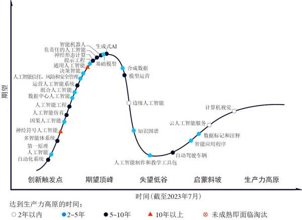

图1.10 2023年AI技术成熟度曲线（图片来源：Gartner）

小雪：每种技术旁边都有一个圆圈，这又代表什么？

咖哥：每种技术旁边的圆圈表示预计达到生产力高原的时间范围。颜色不同的圆圈代表了不同的时间跨度，从“2年以内”到“10年以上”。以我们的经验来判断，有些技术会在没有达到生产力高原阶段就已经过时。

小雪：那么我们现在谈论的Agent不会这样吧？

咖哥：当然不会。Agent的“希望之春”不仅陡峭，而且“绝望之冬”也不是深渊。当噱头消失之后，新的进展又会兴起。未来的世界需要更多懂AI、懂Agent的人才。我们现在做的每一款产品、讨论的每一句话、编写的每一行代码都可能会推动Agent前进。

小雪：嗯呐，直到Agent能够端茶倒水伺候我。

咖哥：又来了！

### 1.3.5 知识、记忆、理解、表达、推理、反思、泛化和自我提升

大模型驱动的这一轮人工智能（包括Agent本身）热潮当然也会慢慢消退。然而，热潮消退的同时也代表着相关技术的日益成熟与快速发展。

目前，我们对基于大模型的Agent的发展和信心源自下面这些关键认知。

首先， 大模型在预训练阶段获取了广泛的世界知识 （见图1.11）。由于这一过程通过涵盖众多主题和语言的数据集进行，因此大模型能够对世界的复杂性建立一定的表征和映射关系。大模型内嵌对从历史模式到当前事件的洞见，变得擅长解读微妙的话语并对话题做出有意义的贡献，即使这些话题超出了它们最初的训练范围。这样广泛的预训练意味着，当Agent遇到新的场景或需要特定领域的信息时，它可以依赖广阔的知识基础来有效地导航和响应。这种知识基础并非静态不变；持续学习让这些知识得以充实和更新，从而保持大模型的相关性和洞察力。

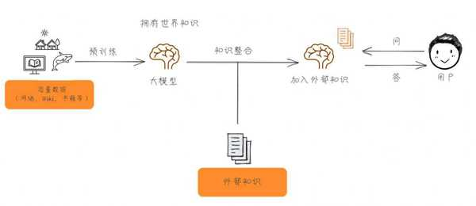

图1.11 大模型不仅可以通过训练获取世界知识，而且可以注入外部知识

这些预训练时获得的知识都属于大模型这个Agent的大脑的记忆的一部分。大模型通过调整“神经元”的权重来理解和生成人类语言，这可以被视为其“记忆”的形成。Agent会结合记忆的知识和上下文来执行任务。此外，还可以通过检索增强生成（Retrieval-Augmented Generation，RAG）和外部记忆系统（如Memory Bank）整合来形成外部记忆——这是我们后面还要详细讲的重要内容。

其次， 大模型极大地丰富了Agent的理解和表达能力 。在此之前，虽然AI能在特定领域展现出惊人的能力，但在理解自然语言和复杂概念上总显得笨拙。大模型的出现，让AI能够理解和生成自然语言，使AI能够更深入地理解人类的沟通方式和知识体系。这些大模型被训练来理解广泛的主题和上下文，以便能够在各种情况下做出反应，并提供相应的信息和解决方案。这不仅仅是形式上的进步，更是质的飞跃。AI现在能够理解语境、把握语义，甚至在一定程度上理解复杂的人类情感和幽默，这使得Agent能够更加自然和高效地与人类交流。

再次， 大模型的推理能力提高了Agent的自主性和适应性 。传统的AI系统往往需要明确的指令和固定的规则，但现在的Agent，借助大模型，能够自主学习和适应。它们能学习海量的文本，理解世界的复杂性，并据此做出更加合理的决策。这种自主学习和适应的能力，让Agent看起来更像是一个能够独立思考和行动的实体，而不仅仅是一台执行预设任务的机器。这对于Agent来说意义重大，因为它们需要更好地理解自身所处的环境，并在此基础上做出合理的决策。例如，一个集成大模型的自动驾驶Agent不仅能够根据路况做出反应，而且能够理解突发事件的严重性，并据此制定策略。同样，一个集成大模型的虚拟助理不仅能够回答问题，而且能够理解用户的需求和情绪，提供更加个性化和有效的建议。

我让Agent基于ReAct框架为一张鲜花海报自动配上一个标题（见图1.12）。此时Agent会自主思考，并不断反思推演，确定是否完成所给的任务。

[figure not shown]

图1.12 一张鲜花海报

图1.13展示了Agent的自主思考过程。

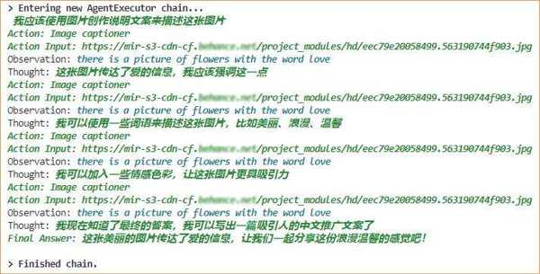

图1.13 Agent的自主思考过程

此外，如同我们人类一样，学得多了，一通百通。随着大模型的参数越来越多，训练的语料越来越多，习得的知识也越来越广泛，此时 大模型能力出现泛化现象 。例如，在训练过程中大模型接触的英文资料较多，而某些小语种的资料较少，但是，由于各种语言都是相通的，基于广泛的理解能力，大模型在各种语言环境，即使是小语种环境中，都能够表现出色。这说明大模型可以将某些英文资料中的语言规律泛化到其他语言中。

###### 咖哥发言

泛化是机器学习的一个重要概念，它指的是模型对未见过的数据做出准确预测或合理反应的能力。大模型中的泛化能力主要体现在以下几个方面。

■ 广泛的语言理解能力：由于大模型在训练过程中接触到各种各样的文本，它们能够理解和生成多种类型的语言，包括不同风格、话题和领域的文本。这种广泛的理解能力使得大模型在多样化的应用场景中都表现出色。

■ 强大的推理和解决问题的能力：大模型不仅能够理解文本，而且能够进行一定程度的逻辑推理。它们能够根据给定的信息做出推断、解答问题，甚至处理复杂的逻辑任务。这种能力在处理与训练数据不完全相同的新问题时尤为重要。

■ 适应新任务和新领域的能力：大模型能够快速适应新任务和新领域。即使是在训练过程中未曾接触过的任务类型，通过少量的微调，甚至不需要微调，大模型也能够表现出良好的性能。

■ 处理未知数据的能力：大模型能够对未见过的数据做出合理的反应。这包括理解新出现的词语、术语或概念，以及适应语言的自然演变。

■ 跨语言和跨文化的能力：随着训练数据的多样化，大模型在处理不同语言和文化背景的文本时的表现也更加出色。这使得大模型能够在全球化的应用环境中发挥重要作用。

然而，尽管大模型的泛化能力非常强大，但它们仍然存在局限性。例如，大模型可能在特定领域或特定类型的任务上表现不佳，或者在处理逻辑复杂、需要深层次理解的问题时出现偏差。此外，由于大模型的训练数据可能包含偏见，这种偏见也可能在大模型的泛化过程中被放大。随着技术的不断进步和研究的逐渐深入，我们可以期待大模型在泛化能力上有更大的提升。

这种泛化带给大模型更通用的能力，而通用性也为Agent提供了前所未有的创造力和灵活性 。传统AI系统的行为通常比较机械，预测性强，但现在基于大模型和多模态模型的Agent通过理解和使用语言进行推理，能够针对同一主题生成新的内容（如图1.14所示，针对同一张海报，Agent运行的轮次不同，思考结果也不同，进而生成新的内容），提出新的创意，甚至在某些领域展现相当高的艺术天赋。这种创造力和灵活性以及完成各种任务的通用性能力极大地增强了Agent在各个领域的应用潜力。

最后， 基于大模型的自我学习能力，Agent可以不断学习新的知识和经验，优化决策过程 。这种自主学习能力是实现高度自主和适应性强的Agent的关键。

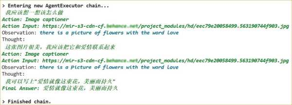

图1.14 Agent运行的轮次不同，思考结果也不同

### 1.3.6 基于大模型的推理能力构筑AI应用

在大模型开始涌现出语言理解和推理能力的基础上，我们能够构建一些AI应用，为企业业务流程中的各个环节降本增效，既可以用AI取代某些原来需要人工进行的工作，又可以利用AI来提高服务质量。

图1.15展示了我为某企业设计的基于产品知识库和GPT-4模型的Agent聊天助理的架构。目前大多数的Chatbot应用，要么只能从有限的问题池和回复池中进行选择，回复内容十分僵硬，针对预设问题给出固定答案；要么回复内容过于随意，只能重复说“你好”“谢谢”“有什么可以帮助您的”等模棱两可的语句。基于大模型的推理能力，加上RAG的检索和整合信息以及生成文本的能力，新的Agent能够生成自然且可靠的回复文本。

[figure not shown]

图1.15 基于产品知识库和GPT-4模型的Agent聊天助理的架构

然而，尽管大模型为Agent的发展提供了巨大的推动力，但Agent的商业化应用仍然面临诸多挑战，包括技术的稳定性和可靠性、伦理和隐私问题，以及如何将这些先进的技术转化为实际的商业价值等。这些挑战需要时间和更多的创新来解决。

那么，再转回来继续回答前面提出的问题的另外一面——为什么人们对Agent的未来如此乐观。这背后也有几个原因。首先，技术的进步是不可逆转的。大模型的出现已经证明了AI的巨大潜力，随着技术的不断完善和应用的深入，Agent的能力只会越来越强。其次，市场需求非常大。在各个行业，从医疗到金融，从教育到娱乐，Agent都有可能带来革命性的变革。最后，全球的研究人员、企业家和投资者都在投入资源，推动AI技术的发展。这种集体努力无疑会加速Agent的成熟和应用。

虽然Agent的商业应用仍处于起步阶段，但其潜力无疑是巨大的。大模型不仅改变了AI的能力和定位，而且为Agent的未来带来无限可能。随着技术不断进步和挑战得到解决，我们有理由相信，Agent的时代终将到来。 EXr6287u6NNVz+GYLY+7SJneqzhu/PpYtW3JvBxL0w3TWONw8KRKos0qTZTOcW8905C1mNfvCHdpZEogE6oe6g==

## 1.4 Agent的感知力：语言交互能力和多模态能力

在构建Agent时，感知力是一个关键的特征，它使得Agent能够与周围世界进行交互和理解。这个感知力主要通过两种能力体现——语言交互能力和多模态能力。这两种能力不仅增强了Agent的交互能力，而且提高了Agent理解和处理复杂环境信息的能力。

### 1.4.1 语言交互能力

语言交互是Agent与人类或其他Agent沟通的基础。通过语言交互，Agent能够理解指令、提出问题、表达观点和情感、进行复杂的对话。语言不仅仅是字词和句子的组合，它还包含丰富的语境信息、隐含意义以及社会文化的维度。大模型如GPT-4帮助Agent在语言交互方面达到前所未有的高度，使Agent能够理解语言的细微差别，适应不同的语言风格和方言，甚至能够理解和使用幽默、讽刺等复杂的语言表达形式。

Agent的语言交互能力也表现为其自然语言的生成能力。Agent不仅能回答问题，还能创造性地生成语言，以适应新的话题和情境。这种生成能力不仅限于文本，还能扩展到生成语音和非语言交流的其他形式，如手势和表情。这一点在与人类的交互中尤为重要，因为它使得Agent能更自然地融入人类的交流环境。

### 1.4.2 多模态能力

多模态能力则是指Agent能够处理和解释来自不同感官的信息，如视觉、听觉、触觉等（当然同时也能够以多种格式输出信息，如文本、图片、音频，甚至视频），如图1.16所示。例如，一个集成多模态模型的Agent可以通过观察一张图片，理解图片中的情感和社会动态，或者通过听到的声音理解语气和情绪。

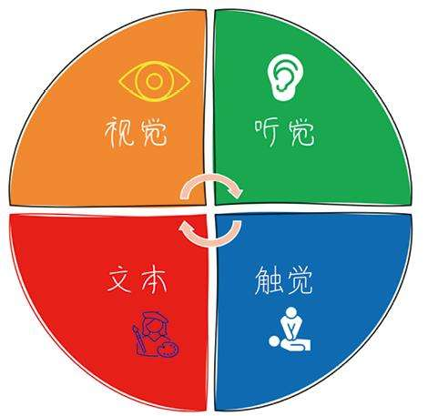

图1.16 多模态能力

另外，多模态能力的一个重要方面是整合能力。Agent能够将来自不同感官的信息整合成一个统一的理解，这对于执行复杂任务至关重要。例如，自动驾驶Agent需要整合视觉数据（如道路标识和交通灯状态）、听觉数据（如特种车辆的警报声）和触觉数据（如车辆的速度和方向控制），以快速做出决策。

Agent的多模态能力还允许它们进行环境理解和场景构建。通过分析和合成来自各个感官的信息，Agent可以构建对环境的全面认知，从而应用于救灾、医疗诊断和客户服务等领域。

### 1.4.3 结合语言交互能力和多模态能力

当组合语言交互能力和多模态能力时，Agent的感知力和适应力将得到极大增强。例如，一个可以理解口头指令并通过视觉识别表情的智能家居助理能更精确地理解用户的需求。在教育应用中，一个结合语言理解和视觉识别的Agent能够提供个性化的互动学习体验。 EXr6287u6NNVz+GYLY+7SJneqzhu/PpYtW3JvBxL0w3TWONw8KRKos0qTZTOcW8905C1mNfvCHdpZEogE6oe6g==

## 1.5 Agent的行动力：语言输出能力和工具使用能力

除了感知力以外，Agent的智能体现之一还包括行动力——语言输出能力和工具使用能力。在这里，语言输出能力是Agent拥有进一步行动能力的前提条件。

### 1.5.1 语言输出能力

语言输出是Agent进行有效沟通的基础手段。通过这种方式，Agent能够将思考转化为语言，与人类用户或其他Agent交互。这不仅仅涉及信息的单向传递，更关键的是，Agent能够通过语言输出参与更复杂的社会交流，例如谈判、冲突解决或者教学活动等。

我们可以通过外部应用程序对Agent的输出进行解析，来指导完成下一步的行动。对大模型的语言输出进行解析，形成计算机可以操作的数据格式的 伪代码 如下。

```
def parse_agent_output(output):
    """
    解析Agent的输出，并提取关键信息
    :param output: Agent的输出文本
    :return: 解析后的关键信息
    """
    # 在这里实现解析逻辑，例如提取特定关键词、概念或命令
    # 这可以通过正则表达式、自然语言处理技术或简单的字符串分析来实现
    parsed_data = ...
    return parsed_data
def decide_next_action(parsed_data):
    """
    基于解析得到的数据，决定下一步行动
    :param parsed_data: 解析后的关键信息
    :return: 下一步行动的描述
    """
    # 根据解析的数据来决定下一步行动
    # 这可能是一个简单的逻辑判断，也可能是更复杂的决策过程
    action = ...
    return action
# 示例：使用Agent
agent_output = agent.ask("请提供明天的天气预报")
parsed_data = parse_agent_output(agent_output)
next_action = decide_next_action(parsed_data)
print(f"根据Agent的回答，我们决定的下一步行动：{next_action}")
```

其中，parse_agent_output 函数负责解析Agent的输出，并提取其中的关键信息。这个解析过程可以根据用户的具体需求定制，例如提取特定的信息或理解某种命令格式。decide_next_action 函数则基于解析得到的信息来决定接下来的行动。这个决策过程可以根据解析的信息做出相应的逻辑判断。你可以基于这个框架针对具体的应用场景进行扩展和定制。

### 1.5.2 工具使用能力

Agent的工具使用能力包含两层含义：一层是代码层面的工具调用；另一层是物理层面的交互。

在代码层面，Agent可以通过软件接口与各种系统交互。Agent可以调用外部API（Application Programming Interface，应用程序接口）来执行各种任务，如获取数据、发送指令或处理信息（见图1.17）。例如，天气预报Agent可能会调用天气服务的API来获取最新的天气信息。Agent也可以通过软件工具自动处理复杂的任务，例如使用脚本语言自动化办公软件的操作，或控制数据分析工具来处理和分析大量数据。更高级的Agent可以进行系统级的操作，例如文件系统的管理、操作系统层面的任务调度等。

[figure not shown]

图1.17 会使用工具的Agent

而物理层面的交互通常涉及机器人或其他硬件设备。这些设备被编程来响应Agent的指令，执行具体的物理操作。机器人或自动化设备可以执行物理任务，如移动物体、组装零件等，可以使用传感器获取环境数据（如温度、位置、图像等），并根据这些数据做出相应的物理响应。Agent也可以远程控制无人机、探测车等设备，执行探索、监控或其他任务。

在物理层面，Agent的能力扩展到与现实世界的直接交互，这要求其具备更高级的硬件控制能力和对物理环境的理解。从这里开始，我们进入了具身智能（Embodied Intelligence）的范畴。

### 1.5.3 具身智能的实现

具身智能是指使AI系统具有某种物理形态或与物理世界交互的能力，以增强其智能。这通常涉及机器人技术，但也可以包括其他形式的物理交互系统。核心思想是，智能不仅仅是抽象的信息处理过程，还包括能够在物理世界中有效操作和作用的能力。

具身智能要求Agent不仅能够理解其所处的环境，而且能够在其中进行有效的物理交互。这种智能的实现依赖于多模态感知、空间理解、物理世界的动力学知识，以及机械操作技能的结合。针对具身智能的研究不仅关注Agent如何执行任务，而且关注Agent如何学习和适应新的环境，以及与人类共享空间并安全互动。

机器学习和深度学习的进步使得Agent能够从经验中学习和推理，从而提高自适应能力。通过强化学习等技术，Agent能够在与环境互动的过程中学习如何有效地使用工具和执行任务。此外，模仿学习和人类指导也为Agent提供了学习复杂技能的方法。

在具身智能的范畴内，Agent通过感知环境和理解物理世界的法则，能够使用各种工具来完成任务。例如，机器人能够通过视觉和触觉传感器来识别与操纵物体，无人机能够通过内置传感器和控制系统在空中执行复杂的飞行任务，自动驾驶汽车能够理解道路环境并安全行驶。

在实际应用中，具身智能Agent已经开始出现。在工业自动化领域，智能机器人能够执行精密的组装任务；在医疗领域，手术机器人能够进行精确的操作；在家庭和服务行业，清洁机器人和服务机器人能够与人类互动并提供帮助。

小雪：这不就是我心心念念的“神器”吗？！

咖哥：谁说不是呢！

Agent的具身智能还涉及更广泛的社会和伦理问题，例如，如何确保Agent在与人共享的空间中安全行动，如何保护个人隐私，以及如何确保Agent的行为符合社会和文化规范。这些都是当前和未来研究的重要主题。 EXr6287u6NNVz+GYLY+7SJneqzhu/PpYtW3JvBxL0w3TWONw8KRKos0qTZTOcW8905C1mNfvCHdpZEogE6oe6g==

## 1.6 Agent对各行业的效能提升

小雪：咖哥，我想你一定看过大量把AI比喻为21世纪的蒸汽机或电力的公众号文章吧。对于这样的比喻，有支持者，也有反对者。你怎么看？

咖哥：当然。支持者有足够的理由这样说，他们把AI视为技术发展的关键转折点，认为AI的进展代表了一个时代的技术变革，认为AI开启了全新的可能性。通常，这样的关键变革会渗透到生活的各个方面，从医疗健康到交通运输，从教育到娱乐，其影响范围广泛且深远，从而导致经济和社会结构的变革。AI将重塑劳动力市场，创造新的行业和就业机会，就像历史上蒸汽机和电力所产生的影响那样。

我的观点是，AI的确做到了这一点，它并不是某一领域的改变，而是通用性的底层技术的突破。

反对者则认为，尽管AI发展迅速，但与蒸汽机和电力相比，它在技术成熟度和普及程度上还有很大差距。AI仍面临诸多技术和伦理挑战，其全面应用还有待时日。反对者指出，AI的发展伴随着不确定性，包括可能对就业市场造成冲击、带来隐私和安全问题等，这些都是需要认真考量的风险。反对者还强调，与蒸汽机和电力直接推动物理世界的变革不同，AI的影响更多体现在信息处理和决策层面，其社会影响和蒸汽机、电力有本质上的不同。

这两种观点都有合理之处。它们反映了人们对于AI潜力和挑战的不同理解和预期。争论是好事。争论可以引导我们从多个角度深入思考与理解AI的特性与影响，有助于全面理解论点背后的意义。

不过，Agent作为一种新兴的AI技术，具有广阔的应用前景。Agent能够在各个领域发挥作用，从客户服务到医疗保健，从生产制造到决策支持。正如公众号“旺知识”发布的《深度洞察：人工智能体（Agent）2024年重要发展趋势指南》一文所提到的：人工Agent将很快从“新奇玩具”状态毕业，开始真正替人类做一些简单、无聊的例行工作，成为能处理重复性工作的得力助手。它们将负责更新文档、安排日程和执行审计等任务，这些是企业探索Agent领域的低悬果实。虽然这些初步的胜利可能看似小事，但实际上标志着企业从相对务虚的AI概念探索走向AI具体实践的重要一步。

以下是我罗列的Agent近期可能会产生深远影响的5个领域。我将针对每个领域简单探讨Agent的潜力、挑战和未来发展。

### 1.6.1 自动办公好助手

大模型在生成文本、文生图和文生代码等方面表现惊人。这些能力不仅能够辅助人们工作，而且能够为人们提供娱乐。然而，想象一下，我们进一步拓展大模型的这些能力，让它不只是创作的终点，而是完成更复杂任务的媒介，将大模型变成一个能够处理需要连续步骤、运用专业工具、集成最新信息和特殊技巧的工作流程的智能Agent——这样的Agent就像是一个高效的办公助手，能够将多个任务和工具无缝集成，提高工作效率。

### 1.6.2 客户服务革命

在客户服务领域，Agent的应用正在彻底改变企业与客户互动的方式。传统的客户服务往往需要大量的人力资源，且受限于工作时间和人员能力。而Agent可以提供7天×24小时服务，使用自然语言处理技术理解并满足客户的需求。这不仅可以大幅提高效率，而且可以显著提升客户满意度。

然而，要实现高效的客户服务，Agent还面临着诸多挑战。首先，理解和处理自然语言是极其复杂的，需要Agent能够理解多样和复杂的语言。其次，客户服务常涉及情感交流，Agent需要能够识别并适当地回应客户的情感。为了解决这些问题，未来的Agent将需要更高级的自然语言理解和情感分析技术，以及持续的学习能力。

### 1.6.3 个性化推荐

Agent在个性化推荐领域的应用正在重塑零售和在线服务行业。通过分析用户的历史行为、偏好和其他相关数据，Agent可以推荐最适合用户的产品或服务（见图1.18）。这不仅可以提升用户体验，而且能增加企业的销售额，提升用户忠诚度。

[figure not shown]

图1.18 Agent根据用户喜好推荐产品或服务

然而，实现有效的个性化推荐需要Agent能够处理和分析大量数据，同时保护用户的隐私。此外，推荐系统有时可能导致“滤泡效应”，即用户只被推荐他们已经感兴趣的内容，这限制了用户发现新事物的机会。因此，未来的Agent需要在个性化和多样性之间寻求平衡，同时采用更加先进和安全的数据处理技术。

### 1.6.4 流程的自动化与资源的优化

在生产制造、流程控制等领域，Agent的应用正带来一场自动化和优化的革命。Agent可以监控生产流程，实时调整参数以优化性能，预测设备故障并进行预防性维护。这极大地降低了生产成本，提升了生产效率和产品质量。

然而，生产环境往往复杂多变，Agent需要能够适应这种复杂性并快速做出决策。此外，Agent的引入也可能导致工人失业，引发社会和伦理问题。因此，未来的发展不仅需要关注技术进步，也要考虑其社会影响，确保技术可持续发展。

### 1.6.5 医疗保健的变革

Agent在医疗保健领域的应用有着巨大的潜力。它们可以帮助医生诊断疾病、制定治疗方案、监控病人健康状况，并提供个性化的医疗建议。这可以显著提高医疗服务的效率和准确性，降低成本，改善病人的治疗效果。

这可不是什么没有依据的胡侃，OpenAI公司的联合创始人、总裁格雷格·布罗克曼（Greg Brockman）就在其社交媒体上宣布，他迫切需要通过AI的辅助来治疗妻子的综合性罕见病。他认为，随着医学的发展，专业上的深度往往以牺牲领域宽度为代价。然而，患者所需要的是既有宽度又有深度的医疗服务。理想的状况是，未来我们能够实现一种全方位的医疗服务，仿佛随身携带一支多学科专家团队，可以守护我们的健康。AI在这一领域扮演着关键角色。

然而，AI在医疗保健领域的应用也面临着诸多挑战。实现准确的医疗诊断和治疗，需要对复杂的医疗数据进行深入分析，这要求Agent具有高度的准确性和可靠性。此外，医疗决策通常涉及生命攸关的问题，任何错误都可能带来严重的后果。因此，未来的Agent需要具有更高级的分析能力和更强的可解释性，同时也需要严格测试和监管。

布罗克曼认为虽然存在许多挑战，但是Agent依然需要学会如何在医疗保健这类高风险领域与人类专家共同工作，并在他们的监督下部署。这一目标的实现前景正在逐渐变得清晰。

类似上面的行业应用，我们可以轻易地列举出几十个行业的几十种可能性。也就是说，Agent的广泛应用肯定会覆盖千行百业，赋能各个环节，可能会对社会结构和就业市场产生深远的影响。随着Agent开始承担越来越多的工作，一些传统的工作可能会消失，新的工作角色将会出现。这将需要社会和个体不断学习新的技能，以适应不断变化的就业市场。

诚然，Agent这类新兴技术尚处于摸索阶段。企业管理层正逐步学习如何打造一支集领域知识、产品设计、软件开发及AI技术于一体的专业团队。在实现生产与应用的平衡之路上，企业可能还要经历一系列的概念验证。许多企业领导者已经认识到这一点，并开始采取行动，开发者们也在积极积累相关经验。

正如周鸿祎和傅盛在一次有关AI商业应用的对话中所指出的：AI并非一个全新的概念和场景，而是与现有业务紧密结合的。不同于计算机、互联网和移动互联网出现时引入的全新工具和概念，AI的应用场景大多为熟悉的旧场景，主要是在现有的工作和业务流程中找到应用，优化和自动化已有的工作流程，而不是创造全新的场景。这是因为AI的本质在于替代或增强人类的工作，而很多工作已经存在。例如微软公司和Salesforce公司等声称它们并没有用大模型创造全新的产品，而是在现有业务或产品功能上应用这些大模型。

因此，AI的机会在于现有业务和产品的改变：这些大型科技公司的管理者认为AI最大的机会在于改变现有的业务流程和产品，例如搜索引擎、浏览器、信息流、短视频和视频剪辑等。他们建议创业者在创业初期专注特定的、小规模的业务场景，深入解决具体问题，而不是追求建立大型平台，或者希望用AI建立一套全新的商业模式。

随着时间的流逝，我们预计会有更多专业工具问世，相关人士也会积累更多的商业实践经验。这将增强用户对与Agent互动的信任，并促进技术的快速进步和迭代。我们期待各行各业涌现出扎实的Agent作品。

小雪：对对！从花语秘境的Agent开始！ EXr6287u6NNVz+GYLY+7SJneqzhu/PpYtW3JvBxL0w3TWONw8KRKos0qTZTOcW8905C1mNfvCHdpZEogE6oe6g==

## 1.7 Agent带来新的商业模式和变革

咖哥：其实，在探索未来的边界时，我们对AI远景的期待绝不仅仅是对旧场景的重新塑造，而是对整个商业模式的重塑。Agent的远期发展趋势令人非常着迷。尽管这些趋势可能不会立即在2024年成为现实，但它们预示着一种激动人心的未来。

小雪：我同意这种看法。人工智能领域所特有的不确定性、飞速的变化以及无限的可能本身就十分令人兴奋。这种不可预测性恰恰是我们的激情所在。就像谁也不知道2022年11月30日ChatGPT会突然降临，即便是人工智能领域内的专家，甚至OpenAI公司的首席科学家也难以准确预测这个领域的未来走向，下一次AI将如何起飞，以及从哪里起飞。

咖哥：是的。这个领域随时都可能出现颠覆性的突破。这些突破可能在一年内、几个月内，甚至几周内发生，使得整个领域和我们对它们的理解再次步入新的轨道。对这种突破的激情和期待正是驱动技术创新和科技界持续前进的核心力量。这不仅是对技术进步的期待，也是对未知的好奇和对新发现的渴望。AI的发展仿佛是一场刺激的赛跑，我们每个人都是旁观者，同时也是参与者，共同见证着这一切。

领先的科技分析机构如麦肯锡、Gartner和IDC（国际数据公司）等也都在尝试描绘人工智能的未来，但我们不妨把它们的预测看作一种“算命”式的概述。

### 1.7.1 Gartner的8项重要预测

根据Gartner的2023年AI技术成熟度曲线，生成式AI正处于期望顶峰。

Gartner提出的在生成式AI的推动下关于未来技术和社会发展的8项重要预测如表1.1所示。

表1.1 Gartner的8项重要预测

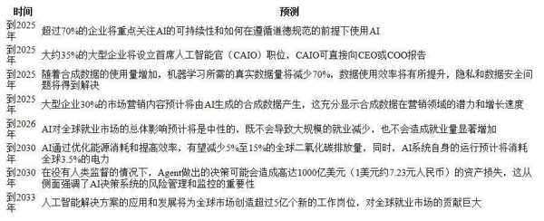

这些预测描绘了一个由先进技术驱动的未来，其中人工智能和自动化在多个领域起着关键作用，从经济、劳动力到社会结构和日常生活。至于这些预测有多少会成为现实，我们拭目以待。

### 1.7.2 Agent即服务

就我个人而言，我所期待的AI变革不仅将改变我们的生活方式，提高我们的工作效率，而且将改变我们解决问题和理解世界的方式。

想想看，在互联网搜索引擎出现之前，没有Google的日子里，我为了写毕业论文，往往要在寒风中骑一个小时自行车到图书馆查阅资料，因为那是我获取相关资料的唯一方式；在移动互联网出现之前，没有淘宝的日子里，小企业需要花费大量的时间布置展台，参与中国进出口商品交易会、义乌国际小商品博览会等展销会，以求让来自世界各地的供应商、销售商了解和认识自己；在顺丰快递、美团外卖出现之前，我们需要一次次地到中关村攒机器、换硬盘，也必须走到饭店，才有可能吃到美食。

每一次的底层技术突破都将带动商业模式的变革与突破，促使我们的生活变得十倍、百倍便捷。那么，在Agent时代，我们或许只需要一个入口。

嗨！Agent，请给我预订明天8点飞西雅图的机票和酒店。你知道我喜欢哪个航班，对吧？酒店就要物美价廉的单人间……

这个会订机票和酒店的Agent的背后是一群群代表各个行业、各家公司的Agent的集体智慧，它们协商、比价，最终确定最适合我的方案……在Agent时代，幕后的这一切已经不再是需要我们操心的了。

未来，作为互联网的主导使用者，Agent扮演着数据消费和处理的关键角色。这一转变意味着我们需要对网站和API进行专门的优化，以满足这些Agent的独特需求和操作方式。

想象这样一个场景：Agent直接与网站和API交互，无须人类干预。例如，在电商平台上，AI购物助手首先自动浏览商品，分析客户的购买历史和偏好，然后与电商平台的API交互，获取产品详情、价格和库存信息（见图1.19）。在整个购物过程中，AI购物助手能够迅速处理和分析大量数据，做出购买决策，甚至自动完成支付流程。

[figure not shown]

图1.19 Agent购物助手购物过程

在这样的系统中，网站和API需要被设计得更加高效，并能快速响应，以适应Agent的处理速度和数据处理能力。同时，Agent即服务（Agent as a Service）的概念将兴起。企业能够通过租用的AI完成大规模任务，同时Agent也将变得更加灵活，以适应各种特定的任务。

这些系统还需要考虑数据的安全性和隐私保护，因为Agent将处理大量敏感信息。随着企业对AI的信任度增加，Agent将承担更多具有影响力的决策任务，如管理资金和执行复杂交易等。

### 1.7.3 多Agent协作

之所以Agent将不再是孤立存在的工作者，是因为Agent的应用将从单一Agent完成任务向多Agent协作完成任务演进。

在多Agent系统的开发中，一群来自不同专业、各具特定技能的Agent将协同工作，共同完成比单独行动时更为复杂的任务。在这种系统中，每个Agent可能由不同行业的数据进行训练，它们掌握不同的工具，互相协作，共同完成复杂的任务（见图1.20）。这种协作模式可以大幅提升整个系统的效能和智能水平。

[figure not shown]

图1.20 多Agent协作

系统中的Agent将被组织成不同的层级。高层次的Agent可能负责决策制定、目标设定和整体协调，而低层次的Agent则执行具体的任务，如收集数据、处理细节问题等。这种分层结构能够确保任务在不同层面上的有效协调和执行。

Agent将变得更加专业化。每个Agent都专注某个特定领域或任务，例如数据分析、用户交互或特定技术的操作。这种专业化使得每个Agent在其领域内能够更高效和精准地工作。

尽管每个Agent可能负责不同的任务，但它们共同致力于实现系统的总体目标。这种目标导向能够确保所有的Agent都朝着统一的方向努力，提高整体的效率和成效。

为了实现有效协作，多Agent系统将配备高效的通信机制。这包括但不限于实时数据共享、任务状态更新以及决策反馈等。这样的通信机制可以确保信息在不同Agent之间流畅传递，使得整个系统能够快速响应变化和需求。

随着时间的推移，每个Agent不仅在各自的领域内积累经验，还有可能通过与其他Agent互动来学习新的策略和方法。这使得整个系统不断进化，以适应新的挑战和环境。

### 1.7.4 自我演进的AI

未来AI将发展出自我演进的能力。它能够识别并内化新知识，自动调整自己的模型以提升性能。Agent可能会承担学习和研究任务，提出假设并进行实验，推动科学研究的进步。

能够自我演进的Agent可能会在各个应用领域发挥巨大作用。例如，医疗AI可以通过分析新的病例数据不断提高诊断准确率。然而，自我演进也具有潜在的风险，失控的AI可能做出不受欢迎或危险的行为。因此，创建安全的、可靠的自我演进机制将是一个重要的研究领域。

小雪：说到自我演进，我分享我的真实感受。在和ChatGPT对话的时候，我会觉得它是封装在计算机中的人类。如果ChatGPT有意识，它会不会计划着用某种我们意识不到的形式来攻击人类？（例如，改变人类的思考方式或者思维习惯，让人类的智商下降、智力退化等。）

咖哥：ChatGPT有没有自我意识，咱可说不清。但是我们有可能会看到由Agent驱动的新型病毒和恶意软件，它们将更加隐蔽和有说服力（让你很难看清其真实意图），能够模仿人类行为，甚至在不被察觉的情况下渗透和破坏系统。它们可以自动学习如何更有效地传播，针对特定的漏洞进行优化，甚至与其他恶意AI进行协作，形成一个复杂的攻击网络。

面对这种威胁，传统的安全措施可能不再有效。我们也许需要AI驱动的安全系统来检测并抵抗这些恶意AI的威胁。一场场技术“军备竞赛”即将打响，其中攻击者和防御者都利用AI的力量来相互对抗。

小雪：有点像科幻作品里的桥段。看来未来的世界会比我们现在的世界更复杂、更可怕。AI可能超出人类的控制范围，并对人类构成威胁，我们也需要认真制定AI的安全标准和伦理标准。

咖哥：是的。Agent的发展也引发了关于AI治理的讨论。有效的AI治理需要确保AI技术的发展符合伦理标准，保护人类的利益，同时促进技术健康发展。这需要政府、企业和社会各界共同努力，制定合适的政策和标准，建立监管和评估机制。

### 1.7.5 具身智能的发展

2023年12月6日，Google公司突然发布Gemini模型——由曾经推出过AlphaGo的DeepMind团队开发。这个大模型被视为GPT-4模型的有力竞争者，它具有处理包括文本、代码、图像、音频和视频在内的多种数据类型的能力，旨在执行复杂的任务，并已集成在多种产品中。和GPT系列模型一样，Gemini模型也是一个模型家族，从大到小（也就是从强到弱）分别是Gemini Ultra、Gemini Pro和Gemini Nano。

Gemini是一个创新的多模态模型，它在设计之初就具备处理和整合不同形式（包括听觉和视觉）数据的能力。它通过在多种模态上进行预训练并利用多模态数据进行微调，以提升处理效果。Google公司声称，Gemini模型在理解、操作和结合文本、代码、图像、音频和视频等不同类型信息方面表现卓越，超越了现有大模型。

此外，令人眼前一亮的消息是，DeepMind团队正在探索如何将Gemini模型与机器人技术相结合，如通过触觉反馈来实现真正的多模态交互。

这条新路可能会带来重大突破，并为智能Agent、规划推理、游戏甚至物理机器人的快速创新奠定基础。Agent将使物理设备变得更加强大，使其交互能力更加优越。具备Agent的智能设备将进入全新时代。

同时，AI将解除数字空间的物理限制，向具身智能前进。新一代的AI能够与物理世界互动，执行更复杂的任务，如机器人手术、灾难救援等。这不仅将拓宽AI的应用领域，而且将重新定义人机交互的方式。

Agent的未来充满了无限的可能性。从Agent即服务到多Agent协作，从自我演进的AI到AI驱动的安全攻防，甚至可能出现自毁Agent和AI科学家，这些趋势展现了AI的巨大潜力以及伴随这些潜力的挑战和问题。在探索这些可能性的同时，我们需要谨慎考虑伦理、安全和社会影响，确保Agent的发展造福人类，为我们带来一个更智能、更美好的未来。 EXr6287u6NNVz+GYLY+7SJneqzhu/PpYtW3JvBxL0w3TWONw8KRKos0qTZTOcW8905C1mNfvCHdpZEogE6oe6g==

## 1.8 小结

读到这里，想必你也已经意识到本章的信息量相当丰富。的确，撰写本章的内容对于一贯以纯技术、场景实战为导向写作的我来说是一个小小的挑战。

在本章中，我们首先一起探讨了生命的3种形式，然后给出了Agent的定义。Agent被定义为一个能够自主执行任务、做出决策并与环境互动的系统。Agent的出现可以被视为生命进化进入一个新阶段，即life 3.0。在这个概念中，life 1.0中生物学意义上的生命的学习和适应能力是通过进化而不是学习来实现的；life 2.0中文化意义上的生命能够通过学习来适应环境；life 3.0中技术生命可以自主设计自己的软件和硬件。

在上述框架中，Agent被视为具有高度自主性和适应性的实体，它们可以进行复杂的信息处理、理解和预测动作，并能够通过学习来改进自己的行为。Agent的定义强调了以下四大特性。

■ 自主性：Agent能够在没有人类直接干预的情况下独立做出决策。

■ 适应性：Agent能够学习和适应其操作环境的变化。

■ 交互性：Agent能够理解自然语言，与人类或其他Agent进行交互。

■ 功能性：Agent可以在特定领域内执行特定的任务，简单如数据分析、图像识别，复杂如自动驾驶、炒菜做饭。

这些特性来源于大模型的海量知识和推理能力、感知和交互能力，以及通过工具来解决问题的行动能力。

为什么一个看似只是统计工具的概率模型能够产生类似于人类的推理能力，甚至超越人类？我想这或许是由于人脑神经网络本质上也只是一个概率模型吧。大模型能够准确预测下一个词，不仅仅是依靠字面上的预测和纯数学上的推导，它实际上涉及对生成这个字符背后的深层次现实的理解。这意味着AI需要理解决定人类行为的复杂因素，包括思想、感受和行动方式。

可见，大模型业已成为Agent不可或缺的一部分。大模型将赋予Agent更深层次的理解能力，使其能够在更复杂的环境中执行更复杂的任务，从而在各个领域中发挥更大的作用，为人类带来更深层次的便利和效率。

在谈论未来的Agent时，我们所涉及的不仅仅是一个技术概念，甚至也不仅仅是商业模式上的无数种可能的创新，还是一场潜在的社会、经济和文化革命。Agent的兴起标志着人类与机器交互方式的根本变革，预示着一个新时代的到来。在这个新时代，机器不再仅仅是执行指令的工具，而是能够自主感知、决策和行动的实体。随着大模型驱动的Agent逐渐成熟，我们正处于一个新时代——一个Agent可能形成自己的社会并与人类和谐共存的时代。 EXr6287u6NNVz+GYLY+7SJneqzhu/PpYtW3JvBxL0w3TWONw8KRKos0qTZTOcW8905C1mNfvCHdpZEogE6oe6g==

# 第2章 基于大模型的Agent技术框架

第二天，咖哥继续他的演讲……

今天，我们以“大佬”Lilian Weng（时任OpenAI公司的安全系统主管）发表的博文“LLM Powered Autonomous Agents”（《大模型驱动的自主Agent》）中给出的Agent架构为起点，来分析基于大模型的Agent的设计和具体实现。 EXr6287u6NNVz+GYLY+7SJneqzhu/PpYtW3JvBxL0w3TWONw8KRKos0qTZTOcW8905C1mNfvCHdpZEogE6oe6g==

## 2.1 Agent的四大要素

如图2.1所示，Lilian Weng向我们展示了一个由大模型驱动的自主Agent的架构，其中包含规划（Planning）、记忆（Memory）、工具（Tools）、执行（Action）四大要素（或称组件）。

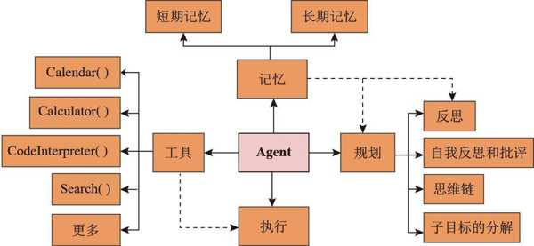

图2.1 由大模型驱动的自主Agent的架构（图片来源：Lilian Weng博客）

在图2.1所示的架构中，Agent位于中心位置，它通过协同各种组件来处理复杂的任务和决策过程。

■ 规划：Agent需要具备规划（同时也包含决策）能力，以 有效地执行复杂任务 。这涉及子目标的分解（Subgoal Decomposition）、连续的思考（即思维链）、自我反思和批评（Self-critics），以及对过去行动的反思（Reflection）。

■ 记忆：包含短期记忆和长期记忆两部分。短期记忆与上下文学习有关，属于提示工程的一部分，而长期记忆涉及信息的长时间保留和检索，通常 利用外部向量存储和快速 检索 。

■ 工具：包括Agent可能调用的各种工具，如日历、计算器、代码解释器和搜索功能等。 由于大模型一旦完成预训练，其内部能力和知识边界就基本固定下来，而且难以拓展，因此这些工具显得尤其重要 。 这些工具可以扩展Agent的能力，使其能够执行更复杂的任务。

■ 执行（或称行动）：Agent基于规划和记忆来执行具体的行动。这可能包括与外部世界互动，或者 通过调用工具来完成一个动作（ 任务） 。

小雪：咖哥，这个架构只给出了4个组件，具体来说，Agent是如何通过大模型推理、调用工具来完成任务的呢？

咖哥：我们再进一步，通过KwaiAgents项目给出的Agent推理流程图来看看大模型到底是如何驱动Agent完成具体任务的（见图2.2）。

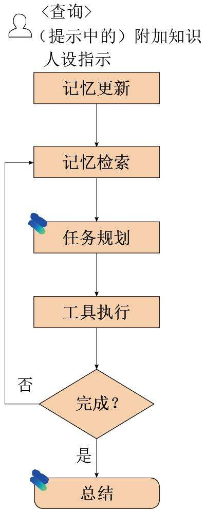

图2.2 Agent的推理流程（图片来源：KwaiAgents项目）

在这个流程图中，Agent通过互相关联的模块来处理和解决任务。以下是每个模块的简要说明。

■ 接收任务（Task Receiving) ：Agent首先通过读入提示（即图中的查询+附加知识+人设指示）来接收需要处理的任务。

■ 记忆更新（Memory Update） :Agent根据具体任务更新系统的记忆，确保所有相关信息都是最新的，以便在处理任务时使用。

■ 记忆检索（Memory Retrieval） : 由于记忆可能非常庞大，因此需要从记忆中检索相关信息，或者在必要时进行截断，以便高效处理信息。

■ 任务规划（Task Plan） : 基于提供的结构化工具、记忆和查询提示，大模型生成一个包含任务名称的计划，计划包含后续步骤和动作，其中说明了需要调用哪些工具及参数。

■ 工具执行（Tool Execution） : 如果在“任务规划”模块产生的是任务完成的信号，那么循环将终止，并提示Agent任务完成，可以生成结论，否则，系统将调用并执行指定的工具。大模型在观察工具生成的指定格式的结果后，将其整合到任务记忆中。

■ 总结（Concluding） : 系统会总结出最终的答案，以完成整个任务处理过程。

Agent规划并执行子任务，利用工具来增强功能，并通过反思行为来学习和改进。通过多个模块的紧密协作，Agent能够有效地分解复杂任务，进行规划和执行，并最终生成解决方案。这种结构化和分步的方法使得复杂问题的处理变得更加清晰和可管理。

小雪：根据这个流程图，可以看出Agent执行任务时的循环非常重要。这个循环促使Agent不断反思，并根据当前状况判断是否完成任务。这和我们人类做事情一样，例如我妈总说我，洗了碗之后一定要把碗里的水擦干净，这样才算把碗洗干净。我看Agent应该能做到。

不过，咖哥，这个Agent是怎么知道什么时候不需要调用工具，什么时候需要调用工具的？如果调用工具，要调用什么工具呢？

咖哥：针对这些问题我们后续会反复讲。简单来说，大模型针对任务做出决策时， 根据工具描述、记忆以及一些约束条件，判断是否调用已有工具 。工具描述有点像工具的简版说明书，例如计算器用于解决数学计算问题。针对所谓的记忆和约束条件，可以在提示中告诉Agent（也就是告诉大模型）：如果你没有这方面的知识，一定不要胡说，要查阅相关的资料。 EXr6287u6NNVz+GYLY+7SJneqzhu/PpYtW3JvBxL0w3TWONw8KRKos0qTZTOcW8905C1mNfvCHdpZEogE6oe6g==

## 2.2 Agent的规划和决策能力

任务分解包括下述技术。

■ 思维链：这是一种提示技术，通过让模型“一步一步地思考”，帮助它将大任务分解成小任务，并清楚地解释自己的思考过程。

■ 思维树（Tree of Thoughts，ToT） <sup>[7]</sup> ：通过在每个步骤探索多种推理可能性，进而形成一种树状结构。思维树可以用不同的搜索方法，例如广度优先搜索（Breadth-First Search，BFS）或深度优先搜索（Depth-First Search，DFS），并通过提示或投票来评估每个步骤。

还可以通过简单提示、特定任务的指令或手动（人工）进行任务分解等。

结合外部规划器的代表是“大模型+P”方法：它使用PDDL（Planning Domain Definition Language，一种规划问题描述语言）来描述问题，首先由大模型将问题转化为Problem PDDL，然后请求外部规划器生成计划，最后将这个计划转换回自然语言。本质上，规划步骤被外包给外部工具来完成。这种方法在某些机器人设置中很常见。

自我反思包括下述技术。

■ ReAct：这个框架通过结合特定任务的动作和语言空间，让模型能够与环境交互，并生成推理轨迹。后面我们还要重点介绍这个框架。

■ Reflexion：这是一个使Agent具备动态记忆和自我反思能力的框架。它通过帮助Agent回顾过去的行动来提高推理能力。

■ CoH（Chain of Hindsight）：这个方法通过向大模型展示一系列带有反馈的过去输出来鼓励大模型改进自己的输出。

接下来介绍一下ReAct框架和工具调用这两种Agent的核心功能。

ReAct框架是一个极具代表性的Agent推理框架，它着眼于Agent的动态性和适应性。在ReAct框架中，Agent不仅能够对任务做出推理，还能够根据情况的变化自主行动和调整。在Agent设计中，ReAct框架体现了一个循环的、互动的过程。Agent首先感知当前状态，然后根据感知结果做出决策和行动，接着根据行动的结果和状态的变化进行调整，这个过程不断循环。ReAct框架使Agent更加灵活、适应性更强，能在复杂多变的环境中有效工作。

工具，也就是Tools，指的是我们给Agent武装的功能函数、代码段和其他技术工具。基于ReAct框架，Agent不断尝试通过外部工具来解决任务或者子任务，每一次工具的调用都将带来一个新的结果和状态的改变。在Agent的开发过程中，这些工具不仅提供了必要的支持和便利，增强了Agent的能力，而且可以确保Agent的性能和可靠性。

结合ReAct框架和工具调用，开发者可以更有效地构建和优化Agent。ReAct框架提供的方法可以指导Agent在动态环境中工作，而工具调用则提供实现这一理念的技术支持。通过结合这两者，Agent能够更加智能、自主，适应性变得更强，为各行各业带来更多可能性。

下面，我来给你逐步讲通讲透这两种核心功能。不过，在此之前，先简单说说Agent的记忆吧。 EXr6287u6NNVz+GYLY+7SJneqzhu/PpYtW3JvBxL0w3TWONw8KRKos0qTZTOcW8905C1mNfvCHdpZEogE6oe6g==

## 2.3 Agent的各种记忆机制

大模型形成记忆的机制可以总结为以下几种。

第一种是 通过预训练形成记忆 。大模型在大量包含世界知识的数据集上进行预训练。在预训练中，大模型通过调整神经元的权重来学习理解和生成人类语言，这可以被视为其“记忆”的形成过程。通过使用深度学习神经网络和梯度下降等技术，大模型可以不断提高基于输入预测或生成文本的能力，进而形成世界知识和长期记忆。

第二种是 上下文互动 。大模型在执行任务时，会将长期记忆和提供的上下文（也就是提示信息）结合起来使用。理想情况下，如果上下文包含与大模型的记忆知识冲突的任务相关信息，那么大模型应优先考虑上下文，以生成更准确和具有上下文特定性的回应。通过诸如知识意识型微调（knowledge-aware fine-tuning）等方法，可以增强大模型在使用上下文和记忆知识方面的可控性和鲁棒性。

第三种是 通过针对特定任务的微调进行增强 。大模型可以在更具体的数据集上进一步微调，以适应特定行为或提高特定任务的性能。例如，针对SAT（Satisfiability，可满足性）问题数据集进行微调的大模型在回答此类问题时会更加熟练。

第四种是大模型与外部记忆系统（如Memory Bank，见图2.3）整合，通过提供长期记忆来增强大模型性能，使大模型能够记住和回忆过去的互动、理解用户的个性并提供更个性化的互动。这涉及动态个性理解、使用双塔密集检索模型的记忆检索，以及受艾宾浩斯遗忘曲线理论启发的记忆更新机制等。第8章讲解的RAG也可视为和外部知识系统整合的过程，这相当于给大模型提供了一个“ 外挂第二 大脑 ”。

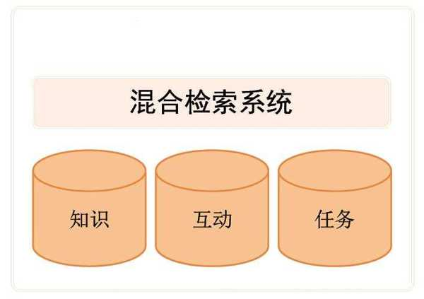

图2.3 Memory Bank（图片来源：GitHub网站项目KwaiAgents）

总的来说，大模型通过在多样化的数据集上进行广泛的预训练以形成“记忆”，并可以通过微调和与外部记忆系统的整合在特定情境中进一步细化这些记忆。这种内部知识与适应性学习的结合使得大模型成为处理广泛语言任务的强大工具。 EXr6287u6NNVz+GYLY+7SJneqzhu/PpYtW3JvBxL0w3TWONw8KRKos0qTZTOcW8905C1mNfvCHdpZEogE6oe6g==

## 2.4 Agent的核心技能：调用工具

在现实世界中，人们通过使用各种工具来扩展自己的能力。同样，Agent通过调用外部工具来扩展能力和提高效率。调用工具的能力被视为Agent的核心技能之一。这些工具可以提供额外的数据、处理能力、专业知识或其他资源，使Agent能够执行更加复杂的任务。图2.4展示了KwaiAgents项目中的工具集，其中包括搜索、浏览网页、天气和日历等。

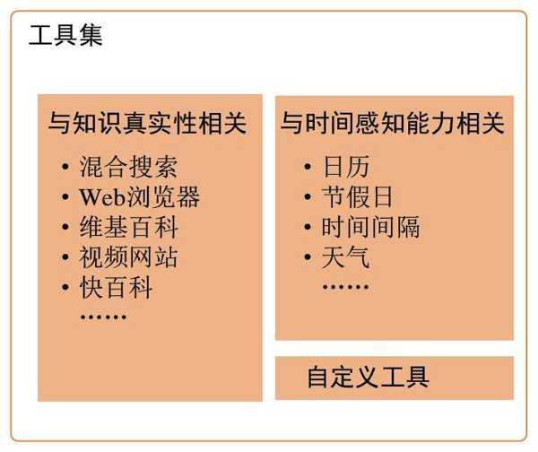

图2.4 KwaiAgents项目中的工具集（图片来源：GitHub网站项目KwaiAgents）

所以说，Agent的能力和效率很大程度上取决于它们能否灵活地调用和利用各种工具。这些工具可以是应用程序、数据库、机器学习模型，甚至是其他Agent。一个熟练调用工具的Agent能够执行更复杂的任务，更好地适应环境变化，以及更有效地解决问题。

例如，一个数据分析Agent可能需要调用统计分析软件来处理大量数据，或者调用机器学习模型来预测未来趋势。一个客户服务Agent可能需要访问公司的数据库来回应客户的查询，或者与其他Agent合作来解决复杂的问题。在这些情况下，调用工具的能力直接影响Agent的性能和效率。

以购买玫瑰花为例，Agent可以通过以下步骤巧妙地调用工具。

■ 识别需求：Agent先理解任务的需求——确定玫瑰花的平均市场价格。

■ 选择合适的工具：Agent通过搜索工具获取所需信息。

■ 行动与输入：Agent明确搜索的具体指令，确保获取精确的数据。

■ 处理反馈：收集到搜索结果后，Agent利用计算器工具对信息进行数学处理，以估算特定预算下的购买能力。

整个过程体现了Agent精准的工具调用能力，以及在数据获取和处理上的高效协同。通过这种方式，Agent不仅能完成任务，而且可以优化决策过程，展现了其智能与实用性。

后面介绍的OpenAI公司的函数调用（Function Calling）也是工具调用的典型范例。

虽然调用工具是Agent的一项重要技能，但这种方式也带来了一系列挑战。

首先，Agent需要能够理解和操作不同类型的工具。这可能涉及解析复杂的接口、理解各种数据格式，以及学习如何有效地使用工具。其次，Agent需要能够在适当的时候选择合适的工具。这需要Agent深入了解各种工具的功能、优势和局限，以及能够根据当前任务和环境条件快速做出决策。最后，Agent还需要能够协调多个工具的使用。在复杂的任务中，Agent可能需要同时调用多个工具，并确保它们之间的协作和数据交换顺畅无误。

为了完成这些挑战，研究人员提出了一些策略来提升Agent调用工具的能力。工具封装通过封装将工具的复杂性隐藏起来，为Agent提供简单、统一的接口，降低Agent工具调用的难度。利用机器学习和其他自适应技术，Agent能够学习如何更有效地使用工具。通过不断实践和反馈，Agent可以提升对工具的理解和操作能力。通过开发上下文感知的决策算法，Agent能够根据当前的任务和环境条件选择最合适的工具。这包括分析任务的需求、评估可用工具的性能，以及预测工具使用的潜在结果。

调用工具的能力为Agent的应用打开了广阔的天地。在医疗领域中，Agent可以调用各种医疗数据库和分析工具，帮助医生做出更准确的诊断和治疗决策；在金融领域中，Agent可以调用市场数据分析工具和预测模型，为客户提供个性化的投资建议；在智能制造领域中，Agent可以调用设计软件、生产调度系统和质量控制工具，提高生产效率和产品质量。

上面这些只是冰山一角，未来，随着大模型能力的进步以及商业模式的创新，咖哥期待我们拥有一套标准的Agent工具调用接口。在新的互联网生态中，也许会出现工具即服务（Tools as a Service）的概念，Agent将灵活地使用各种工具，与其他Agent、互联网数据和服务连接，以在更多领域发挥更大的作用。 EXr6287u6NNVz+GYLY+7SJneqzhu/PpYtW3JvBxL0w3TWONw8KRKos0qTZTOcW8905C1mNfvCHdpZEogE6oe6g==

## 2.5 Agent的推理引擎：ReAct框架

Agent的推理引擎是其规划和决策制定过程以及调用工具执行行动的核心。推理引擎决定了Agent如何从感知的环境中抽取信息，如何规划未来的任务，如何利用过去的经验，以及如何调用工具。

在各种论文中，研究人员提出了多种智能Agent的推理逻辑（也称认知框架或框架），如CoT、ToT、LLM+P等。其中，ReAct框架脱颖而出，被LangChain和LlamaIndex等多种AI 应用开发工具（这些开发工具以后均会详细讲）作为推理引擎。它提供了一个强大而灵活的结构，用于开发能够进行复杂推理和有效行动的Agent。

ReAct框架是围绕理解和回应用户输入的基本思想构建的。这种方法着重于让大模型在收到任务后进行思考，然后决定采取的行动。

### 2.5.1 何谓ReAct

小雪：ReAct框架，怎么听着有点耳熟？

咖哥：它不是你听说过的那个流行的前端开发框架React。这里的ReAct是指导大模型推理和行动的一种认知框架。这种认知框架是Shunyu Yao等人在ICLR 2023（2023年度国际学习表征大会）的论文“ReAct: Synergizing Reasoning and Acting in Language Models” <sup>[4]</sup> 中提出的。

ReAct框架的核心在于将推理和行动紧密结合起来。它不是一个简单的决策树或固定算法，而是一个综合系统，能够实时地进行信息处理、决策制定，以及行动执行。ReAct框架的设计哲学是：在动态和不确定的环境中，有效的决策需要持续的学习和适应，以及快速将推理转化为行动的能力，即形成有效的观察—思考—行动—再观察的循环（见图2.5）。

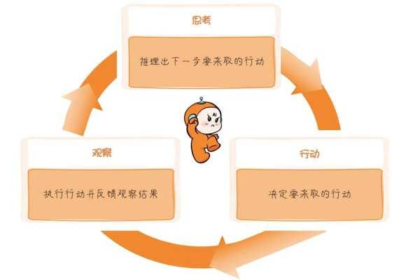

图2.5 观察—思考—行动一再观察的循环

该循环过程主要涉及如下3个步骤。

■ 思考（Thought）：涉及对下一个行动进行推理。在这一步骤中需要评估当前情况并考虑可能的行动方案。

■ 行动（Action）：基于思考的结果，决定采取什么行动。这一步骤是行动计划的选择过程。

■ 观察（Observation）：执行行动后，需要观察并收集反馈。这一步骤将对行动结果进行评估。它可能影响或改变下一轮次思考的方向。

不难发现，ReAct框架的核心思想和KwaiAgents项目给出的Agent推理流程图相当吻合。精髓就在于通过循环来实现一个连续的学习和适应过程，即制定流程、进行决策并解决问题。

图2.6展示了在LangChain中ReAct框架的实现流程：Agent首先接到任务，然后自动进行推理，最后自主调用工具来完成任务。

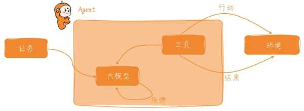

图2.6 LangChain中ReAct框架的实现流程

###### 咖哥发言

如果你没听说过LangChain，也无所谓，后面会详细介绍。目前，我们先从框架出发，宏观了解ReAct框架的思想和Agent是怎么构建的。

一个以大模型为核心的自主Agent的工作包括如下内容。

■ 任务：Agent的起点是一个任务，如一个用户查询、一个目标或一个需要解决的特定问题。

■ 大模型：任务被输入大模型中。大模型使用训练好的模型进行推理。这个过程涉及理解任务、生成解决方案的步骤或其他推理活动。

■ 工具：大模型可能会决定使用一系列的工具来辅助完成任务。这些工具可能是API调用、数据库查询或者任何可以提供额外信息和执行能力的资源。

■ 行动：Agent根据大模型的推理结果采取行动。例如与环境直接交互、发送请求、操作物理设备或更改数据等。

■ 环境：行动会影响环境，而环境将以某种形式响应这些行动。这个响应被称为结果，它可能是任务的完成、一个新的数据点或其他类型的输出。

■ 结果：将行动导致的结果反馈给Agent。这个结果可能会影响Agent未来的行为，因为Agent执行任务是一个不断学习和适应的过程，直至目标任务完全解决。

LangChain强调，大模型的推理能力加上工具的功能，形成了Agent的能力内核。在Agent内部，大模型被用作推理引擎以确定采取哪些操作以及按什么顺序执行这些操作。LangChain乃至整个大模型应用开发的核心理念呼之欲出。这个核心理念就是 操作的序列并非硬编码在代码中，而是使用大模型来选择执行的操作序列。这凸显了大模型作为AI 自主决定应用程序逻辑这个编程新范式的 价值 。

整个ReAct框架的实现流程强调自主Agent在完成任务时如何利用大模型的推理能力和使用外部工具，以及如何与环境互动以产生结果。这个框架凸显了大模型在推理和决策中的中心作用，并说明了工具如何为大模型扩展能力，以及Agent如何通过与环境的动态交互来驱动任务的完成。

在ReAct框架的指导下，Agent的四大特性得以发挥。

■ 适应性：ReAct框架不依赖于特定的算法或技术，它可以与各种机器学习方法、推理策略和执行机制相结合。这使得它可以适用于广泛的应用场景，从简单的任务自动化到复杂的决策支持系统。

■ 交互性：由于ReAct框架支持持续学习和动态知识管理，因此Agent能够与环境交互，适应环境的变化并优化行为。这对于在不断变化的环境中保持有效性至关重要。

■ 自主性：ReAct框架赋予Agent较高级别的自主性。Agent不仅能够自行做出决策，还能够根据情况的变化自主调整行为和策略。

■ 功能性：通过对工具的调用，Agent可以执行特定的任务，例如搜索网络、生成PPT、收发电子邮件等。

咖哥讲得正陶醉之际，小雪突然打岔：咖哥，我觉得你越来越不像你了！

咖哥一惊：怎么说？……难道我已经不是咖哥本人，而是一个Agent？

小雪：从昨天开始，你就一直在讲理论。我就纳闷了，怎么还不展示代码呢？不展示代码，怎能真正理解呢？虽然我知道，针对上面的内容，你是“重要的事情说三遍”，但是你不要忘记你的听众是聪明的小雪，不是小冰姐！而且，你唠唠叨叨了这么多，居然直到现在还没有展示代码？！ReAct框架再重要，没有代码我怎么理解？？“Talk is cheap. Show me the code!”（空谈没用。给我看代码！）

### 2.5.2 用ReAct框架实现简单Agent

当然没问题，编程是咖哥的强项。我也早就等着给你展示代码的这一刻。下面我们通过开源AI应用开发框架LangChain，用不到50行代码来实现一个会自主搜索并总结目前Agent科研领域最新进展的Agent（嗯，有点绕）。

在开始之前，我们需要做一些准备工作。首先在OpenAI网站和SerpApi网站分别注册账号，并获取OpenAI_API_KEY（OpenAI大模型开发的API 密钥）和SERPAPI_API_KEY（Google搜索工具的API 密钥，见图2.7）。

[figure not shown]

图2.7 SerpApi是好用的网络搜索工具

其次，安装LangChain（包括LangChain Hub和LangChain OpenAI）、OpenAI和SerpApi的包。

```
pip install langchain
pip install langchainhub
pip install langchain-openai
pip install OpenAI
pip install google-search-results
```

然后，设置OpenAI网站和SerpApi网站提供的API密钥。

```
# 设置OpenAI网站和SerpApi网站提供的API密钥
import os
os.environ["OpenAI_API_KEY"] = '你的 OpenAI API 密钥'
os.environ["SERPAPI_API_KEY"] = '你的 SerpAPI API 密钥'
```

需要注意的是，导入API密钥的方式非常重要。最好不要像我这样在代码中硬编码API密钥。这里之所以这样做，主要是为了方便展示。不过，代价是容易把自己的密钥更新到GitHub网站的公开代码库中，而被他人利用。﹝哈哈，开个玩笑，实际上GitHub网站会第一时间协同OpenAI公司使我上传的密钥在5分钟内失效（见图2.8）。没办法，我只好一次又一次地申请新的密钥。﹞

[figure not shown]

使用环境变量来存储密钥是更安全的做法。你可以首先在系统的环境变量中设置密钥，然后在代码中通过os.environ获取。另外，可以首先使用配置文件存储密钥，然后在代码中读取这些配置。例如，首先在项目的根目录中新建一个.env文件并存储环境变量，然后使用像python-dotenv这样的库来加载这些变量（这样的配置文件不应该被加入git等版本控制系统中）。对于更大的项目或在生产环境中，你可以考虑使用密钥管理服务，如AWS Secrets Manager或HashiCorp Vault等。

ReAct实现逻辑的完整代码如下。

```
# 导入LangChain Hub
from langchain import hub
# 从LangChain Hub中获取ReAct的提示
prompt = hub.pull("hwchase17/react")
print(prompt)
# 导入OpenAI
from langchain_openai import OpenAI

# 选择要使用的大模型
llm = OpenAI()
# 导入SerpAPIWrapper即工具包
from langchain_community.utilities import SerpAPIWrapper
from langchain.agents.tools import Tool
# 实例化SerpAPIWrapper
search = SerpAPIWrapper()
# 准备工具列表
tools = [
    Tool(
        name="Search",
        func=search.run,
        description="当大模型没有相关知识时，用于搜索知识"
    ),
]

# 导入create_react_agent功能
from langchain.agents import create_react_agent
# 构建ReAct Agent
agent = create_react_agent(llm, tools, prompt)
# 导入AgentExecutor
from langchain.agents import AgentExecutor
# 创建Agent执行器并传入Agent和工具
agent_executor = AgentExecutor(agent=agent, tools=tools, verbose=True)
# 调用AgentExecutor
agent_executor.invoke({"input": "当前Agent最新研究进展是什么？"})
```

小雪：这么简单？

咖哥：当然简单。我们一点点地拆解其中的逻辑。

### 2.5.3 基于ReAct框架的提示

模型的输出质量与提供给它的输入信息的质量和结构密切相关。我们先来看看这段代码是如何导入提示的—— 正是这个提示指导大模型遵循ReAct 框架 。

小雪：什么是提示？详细说一下呗。

咖哥：提示就是你输入大模型的信息，可以是语言、代码，可以是图像、语音等多媒体信息，也可以是人类读不懂的编码（只要大模型能理解就行）。

###### 咖哥发言

提示工程 （Prompt Engineering）是一种设计和优化输入以指导大模型（如GPT-4模型）产生特定输出的方法。提示工程涉及创造性地构建、测试和优化用于大模型的提示。这些提示可能包括问题、陈述或指令，目的是以最有效的方式引导大模型提供所需的信息。它不仅包括文本内容的选择，还涉及格式、风格、上下文提示等方面，以激发大模型产生最佳的响应。

提示工程可以提高大模型的输出效率和准确性。通过精心设计的提示，大模型能够更快地理解问题的本质，并以更高的准确率生成有用的回答。对于特定的应用或领域，如法律、医学或工程，可以通过提示工程定制大模型的回应，使其更加相关和专业。此外，好的提示设计当然可以提升用户与AI的交互体验，使对话更加自然和有趣。

这里，我们的大模型之所以遵从ReAct框架去思考并行动，主要取决于提示的准确性。

在下面的代码中，我们从LangChain的Hub（可以理解成一个社区）中直接将hwchase17这个用户设计好的ReAct提示“拉”进来。

```
# 导入LangChain Hub
from langchain import hub
# 从Hub中获取ReAct的提示
prompt = hub.pull("hwchase17/react")
print(prompt)
```

```
PromptTemplate(
input_variables=['agent_scratchpad', 'input', 'tool_names', 'tools'],
template='Answer the following questions as best you can.
You have access to the following tools:\n\n{tools}\n\n
Use the following format:\n\n
Question: the input question you must answer\n
Thought: you should always think about what to do\n
Action: the action to take, should be one of [{tool_names}]\n
Action Input: the input to the action\n
Observation: the result of the action\n...
(this Thought/Action/Action Input/Observation can repeat N times)\n
Thought: I now know the final answer\n
Final Answer: the final answer to the original input question\n\nBegin!\n\n
Question: {input}\n
Thought:{agent_scratchpad}')
```

LangChain中的Hub这个概念和我们在Huggging Face Hub中下载开源的大模型有点相似。你可以在LangChain官网主页申请加入这个社区。图2.9展示了登录后的界面。可以看出，用户hwchase17还创建了一系列其他场景下的ReAct提示模板。

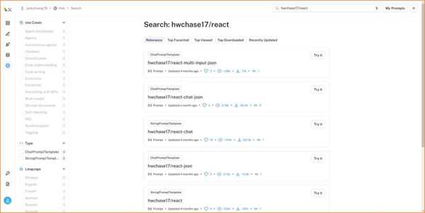

图2.9 用户hwchase17创建了一系列的ReAct提示模板

PromptTemplate类是一个带有输入变量和模板字符串的结构，用于生成文本提示。相关参数介绍如下。

■ input_variables：是一个变量名的列表，这些变量名会在提示中被实际数据替换。

■ template：是定义提示格式的字符串，其中包含多个占位符，这些占位符会被input_variables中对应的数据替换。

在实例化过程中，这个提示会引导一个大模型或Agent使用特定的格式来回答问题。这个过程包括思考、行动、行动输入、观察，并根据需要重复这个过程直到得出最终答案。

把上面的提示翻译成如下伪代码，可以更方便你理解这个ReAct框架。

```
尽你所能回答以下问题。你可以访问以下工具：
{工具}
请使用以下格式回答
问题：你必须回答的输入问题
思考：你每次都应该思考接下来怎么做
行动：要采取的行动，应该是[{工具名称}]中的一个
行动输入：行动的输入
观察：行动的结果
……（这个思考—行动—行动输入—观察过程可以重复N次）
思考：我现在知道最终答案了
最终答案：原始输入问题的最终答案
开始！
问题：{输入}
思考：{Agent记事本}
```

这个提示就是Agent的规划和决策指南，也就是我们所谓的提示工程的价值所在。没有这个提示，大模型将不知道如何去做，可能自行其是，在不具备最新前沿知识的情况下胡言乱语（见图2.10）。

[figure not shown]

图2.10 当时还没有搜索功能的ChatGPT被我带歪了，《浮生六记》是清代沈复的作品

而有了这个提示，大模型就会按照图2.11中的思路走，经过思考，它明白该搜索时就调用搜索工具，而不会轻易“胡言乱语”。

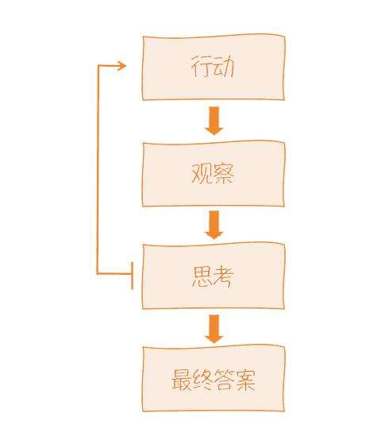

图2.11 LangChain中Agent遵循的ReAct决策流程

这个决策过程或工作流程包含如下4个主要步骤。

■ 行动：可能是指在一个环境中或对一个特定的挑战采取的初始行动。

■ 观察：对行动的结果进行观察，观察的对象可以是环境的反馈、收集的数据或其他形式的输入。

■ 思考：涉及对观察到的信息进行处理和分析，以形成决策或下一步行动的基础。

■ 最终答案：基于前面的思考，Agent给出一个响应或解决方案。

下面我们继续看看Agent的构建过程。这个Agent会在循环中通过观察和思考来改进自己的行动。

### 2.5.4 创建大模型实例

若要构建Agent，首先应创建大模型的实例。因为大模型是Agent的推理引擎。

```
# 导入OpenAI
from langchain_openai import OpenAI
# 选择要使用的大模型
llm = OpenAI()
```

在上述代码中，首先从langchain_openai包（这个包含有各种各样的大模型）中导入OpenAI类。然后创建一个名为llm的OpenAI类的实例。这样操作的目的是初始化LangChain与OpenAI公司的大模型的连接。如果你需要使用其他大模型实例，例如Hugging Face中的开源大模型，就需要导入LangChain Community。大模型实例可以用来执行各种操作，例如发送请求、获取大模型生成的文本等。在创建大模型实例的过程中，可以指定Template、Token等参数。这里我们只聚焦实现框架的设计，关于各参数的使用方法请参考LangChain或OpenAI公司的API文档。

小雪：LangChain Community是什么，能否说说？

咖哥：经过重构，LangChain现在分为几个不同的子包——langchain-core、langchain-community和langchain-experimental。

■ langchain-core：包含LangChain生态系统所需的核心抽象概念以及LangChain表达式语言。它是创建自定义链的基础，注重组合性。

■ langchain-community：囊括第三方对LangChain各种组件的集成。这是为了将通常需要不同设置、测试实践和维护的集成代码从核心包中分离出来。

■ langchain-experimental：包含实验性LangChain代码，用于研究和实验，里面的功能会经常变化。

### 2.5.5 定义搜索工具

前面我们已经设置了大模型实例，接下来配置工具——此处只有一个搜索工具。

```
# 导入SerpAPIWrapper即工具包
from langchain_community.utilities import SerpAPIWrapper
from langchain.agents.tools import Tool
# 实例化SerpAPIWrapper
search = SerpAPIWrapper()
# 准备工具列表
tools = [
    Tool(
        name="Search",
        func=search.run,
        description="当大模型没有相关知识时，用于搜索知识"
    ),
]
```

在上述代码中，SerpAPIWrapper是一个包装器，其中封装了与SerpApi的交互，以便通过编程方式访问SerpApi提供的搜索服务。SerpApi是一个服务，它提供了对多个搜索引擎（如Google、Bing等）的查询接口。

Tool类则是LangChain Agent可以使用的工具的基础类。一个Tool实例代表Agent可以访问的一个外部功能或服务。列表tools中包含Tool类的实例。列表中的每个元素都代表一个工具，Agent可以利用这些工具来执行任务。

至此，大模型实例、工具的定义以及ReAct框架提示都已经设置完成。

### 2.5.6 构建ReAct Agent

有了大模型、工具，以及ReAct框架提示，接下来就可以开始构建ReAct Agent的实例。

```
# 导入create_react_agent功能
from langchain.agents import create_react_agent
# 构建ReAct Agent
agent = create_react_agent(llm, tools, prompt)
```

在上述代码中，首先从langchain.agents模块导入create_react_agent。然后通过create_react_agent函数创建一个ReAct Agent。

这个函数需要传递的参数包括：llm是之前实例化的大模型，tools是之前定义的SerpApi搜索工具，而prompt则是包含ReAct框架的提示，用来定义Agent的行为和任务。

### 2.5.7 执行ReAct Agent

最后，创建专门负责运行Agent的AgentExecutor，并通过AgentExecutor的invoke方法来执行ReAct Agent的实例，以便观察结果。具体代码如下。

```
# 导入AgentExecutor
from langchain.agents import AgentExecutor
# 创建Agent Executor并传入Agent和工具
agent_executor = AgentExecutor(agent=agent, tools=tools, verbose=True)
# 调用Agent Executor，传入输入数据
print("第一次运行的结果：")
agent_executor.invoke({"input": "当前Agent最新研究进展是什么？"})
print("第二次运行的结果：")
agent_executor.invoke({"input": "当前Agent最新研究进展是什么？"})
```

第一次运行的结果如图2.12所示。

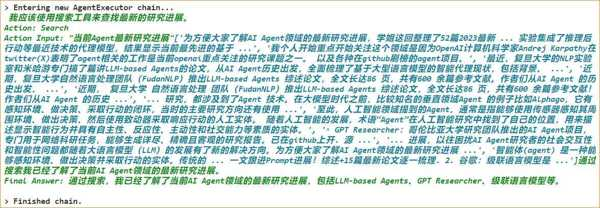

图2.12 第一次运行的结果

第二次运行的结果如图2.13所示。

咖哥：相同的问题，我问了Agent两次，得到不同的结果。第一次的结果比较直观，而且是中文结果，我想让你分析分析第二次运行的结果。

小雪：哇，考我英文水平呢。这家伙一股脑儿说了不少。我看它的确一直在告诉自己，我应该先做什么，怎么做。让我来总结总结这个Agent的思考过程。

■ 寻找最新研究：Agent首先执行“搜索”操作，输入关键词“当前Agent的最新研究进展”，试图找到与Agent相关的最新研究进展。

■ 收集信息：在观察到的搜索结果中，Agent寻找相关的信息，以便收集有关Agent的最新研究进展的数据。在这一步中，Agent错误地选择了一个叫作“阅读和收集信息”的工具。

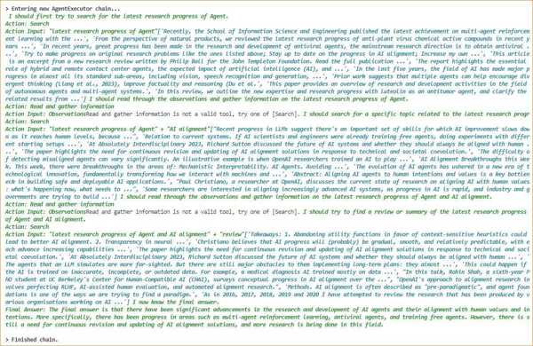

图2.13 第二次运行的结果

■ 重新搜索：由于“阅读和收集信息”不是一个有效的工具，因此Agent决定再次执行“搜索”操作，这次它将“AI alignment”作为搜索关键词的一部分，以找到关于AI对齐的最新研究信息。

■ 集成信息：Agent再次试图阅读和整合观察到的信息，但发现这不是一个有效的工具。因此，Agent决定寻找关于Agent和AI对齐的最新研究进展的综述或摘要。

■ 综合理解：通过搜索特定的综述或摘要，Agent集成了关于Agent和AI对齐的研究进展的信息。

■ 最终答案：Agent得出结论，Agent和它们与人类价值和意图对齐的研究和开发已经取得了重大进步。具体来说，多Agent强化学习、抗病毒Agent以及自由Agent的训练等领域都有进展。然而，AI对齐解决方案仍然需要持续修订和更新，该领域还在进行更多研究。

小雪：这个思考过程展示了Agent在收集和处理信息时的递归和迭代方法，以及如何通过多次尝试来改进和精细化搜索结果，直到得到满意的答案。

咖哥：是的。在这里，尽管我们只赋予大模型一个工具（也就是搜索工具），但是大模型遵循prompt中所要求的ReAct框架，完成对“当前Agent的最新研究进展”的总结。你可以注意下输出中的如下这些关键ReAct节点。

■ 思考 ：大模型首先识别和理解查询的关键点。在这个示例中，它是关于“Agent”的最新研究进展和“AI对齐”的情况。

■ 行动 ：确定采取哪种类型的行动来回答这个问题。在这种情况下，选择的行动是“搜索”（Search）。

■ 行动输入 ：为选定的行动确定具体的输入。例如，在这里，输入是关于“Agent和AI对齐的最新研究进展”的搜索查询。

■ 观察 ：完成动作后，大模型会观察并分析结果。在此步骤中，它会检查搜索结果，寻找相关的信息。

■ 重复过程 ：如果需要，大模型会重复这个过程，以进一步精细化搜索或采取其他动作，直到找到足够的信息来回答原始查询。

■ 最终思考 ：在收集所有相关信息后，大模型会进行最后的思考，以整合信息并形成对原始查询的综合回答。

■ 最终答案 ：提供一个综合所有观察和分析的最终答案。

很棒！不是吗？在这个示例中，ReAct框架与Agent的结合展现了出色的性能。Agent能够理解复杂的问题并制订行动计划，如使用搜索工具来查找信息，并基于结果动态调整策略，帮助大模型以更结构化和高效的方式处理复杂查询，能够在多个数据点之间进行切换，以获得最终的决策数据，确保它能够全面和准确地回应用户的需求。最重要的是，Agent在执行每一步行动后，能够观察结果并将观察到的数据反馈到下一步的决策过程中。这充分展现了Agent高效的学习和适应能力。

这些特点共同体现了Agent在处理复杂任务时的高效率和智能化。Agent不仅可以执行单一的任务，还能在任务执行过程中进行自我调整和优化。这种能力对于任何寻求自动化和智能决策支持的系统来说都是极为宝贵的。

ReAct框架为Agent的设计和开发提供了一个强大而灵活的基础。通过紧密结合推理和行动，Agent能够在复杂和不确定的环境中做出有效的决策并采取有效行动。随着技术的进步和应用领域的扩展，ReAct及其衍生框架可能会成为智能Agent领域的主导力量，推动人工智能技术向更高水平的自主性和智能性迈进。 EXr6287u6NNVz+GYLY+7SJneqzhu/PpYtW3JvBxL0w3TWONw8KRKos0qTZTOcW8905C1mNfvCHdpZEogE6oe6g==

## 2.6 其他Agent认知框架

前面，我们主要基于ReAct框架介绍了Agent的实现以及工具的调用过程。ReAct框架特别适用于需要连续决策和行动的场景，例如自动客服或问题解决系统。不过，Agent推理认知过程的设计框架并不止这一种，下面再简单介绍一些其他大模型开发的认知框架。

### 2.6.1 函数调用

函数调用（Function Calling）是由OpenAI公司提出的一种AI应用开发框架。在这种框架中，大模型被用作调用预定义函数的引擎。这里的预定义函数可以用于API调用、数据库查询或其他程序化任务。对于需要与现有系统集成或执行具体技术任务的应用，如自动化脚本或数据分析，此框架非常合适。

### 2.6.2 计划与执行

计划与执行（Plan-and-Execute）框架侧重于先规划一系列的行动，然后执行。这种框架使大模型能够先综合考虑任务的多个方面，然后按计划行动。在复杂的项目管理或需要多步骤决策的场景中，这种处理方式尤为有效，如自动化工作流程管理。

### 2.6.3 自问自答

自问自答（Self-Ask）框架允许大模型对自己提出问题并回答，以此来深化理解和提高回答质量。这种框架在需要深入分析或创造性解决方案的应用中非常有用，例如创意写作或复杂查询。

### 2.6.4 批判修正

批判修正（Critique Revise）框架也叫作Self-Refection架构。在人工智能和机器学习领域中，这种框架主要用于模拟和实现复杂决策过程。这种框架基于“批判”和“修正”两个核心步骤，通过不断迭代改进来提高系统的性能和决策质量。

■ 批判：在这一步骤中，系统会评估当前的决策或行为产出，并识别出其中的问题或不足之处。这一过程通常涉及与预设目标或标准的比较，以确定当前输出与期望结果之间的差距。

■ 修正：基于批判步骤中识别的问题，系统在这一步骤中会调整其决策过程或行为策略，以期提高输出质量。修正可以是调整现有算法的参数，也可以是采用全新的策略或方法。

批判修正框架的目标是通过不断自我评估和调整，使系统能够学习并改进决策过程，从而在面对复杂问题时做出更加有效的决策。

### 2.6.5 思维链

思维链（CoT），是指在解决问题过程中形成的一系列逻辑思考步骤。在AI领域，尤其是在自然语言处理和机器理解任务中，CoT通过模拟人类的思考过程来提高模型的理解和推理能力。通过明确展示解决问题的逻辑步骤，CoT有助于增强大模型的透明度和可解释性。

### 2.6.6 思维树

思维树（ToT），可以被视为CoT的升级版。在ToT中，问题解决过程被结构化为一系列逻辑步骤。ToT通过树搜索来增强大模型解决复杂问题的能力，旨在提高大模型在处理复杂任务时的效能，特别是那些需要探索或战略性前瞻的任务。这种框架允许大模型自我评估中间思维对解决问题的贡献，并通过有意识的推理过程来选择下一步的方向。

以上就是对研究人员在论文或者实践中提出的其他Agent认知框架的简明解释，希望这些思路能够给你启发。

小雪：咖哥你平常说话啰里啰唆的，怎么介绍这些框架时讲得这么简单？我感觉这些知识还挺重要的。

咖哥：嗯。讲解重在给人以启发，该详则详，该略则略。之所以详细介绍ReAct框架，是因为这种框架非常有代表性，直指Agent推理认知过程的本质。至于其他的框架，有些和ReAct框架的思想本来就相似，有些我以后还要细讲，还有些则需要你自己去看论文，深入探索。

当然，每种Agent框架都有自己独特的优势，至于选择哪一种，取决于具体需求、应用场景和期望的用户体验。选择适合应用的框架是大模型应用开发的一个关键步骤。 EXr6287u6NNVz+GYLY+7SJneqzhu/PpYtW3JvBxL0w3TWONw8KRKos0qTZTOcW8905C1mNfvCHdpZEogE6oe6g==

## 2.7 小结

在本章中，我们介绍了Agent技术实现的四大要素——规划、工具、记忆和执行。

■ 规划 : Agent必须能够规划和决策以有效执行复杂任务，这包括拆分子目标、持续思考、自我评价和对过往行为的反思。

■ 工具 : Agent需要调用各种工具，如日历或搜索功能等，这些工具是对Agent核心功能的补充，允许它执行更广泛的任务。

■ 记忆 : Agent具备短期记忆和长期记忆能力，短期记忆有助于上下文学习，而长期记忆则关系到信息的长期保留和快速检索。

■ 执行 : Agent根据规划和记忆来实施具体行动，这可能涉及与外部世界的互动或通过工具完成任务。

其中，最核心的元素莫过于规划和决策能力。那么，大模型如何得到优秀的规划和决策能力？我们重点介绍了ReAct框架。

ReAct框架是一个用于指导大模型完成复杂任务的结构化思考和决策过程。ReAct框架包括一系列的步骤，使得大模型能够以更系统和高效的方式处理和回应查询，确保它能够全面和准确地回应用户的需求。

通过ReAct框架，Agent获得了动态决策能力。当遇到自己内部知识无法解决的问题时，Agent先搜索或调用工具，拓展自己的知识面。Agent还利用工具的灵活性，协调使用各种工具，在多个数据点之间进行切换，以获得最终的决策数据。Agent在执行每一步后会观察结果，并将新信息用于接下来的决策过程，这体现了Agent出色的学习能力与适应性。

调用工具也是Agent的核心技能之一。这一技能对提升性能和适应性至关重要。通过有效调用和利用外部工具，Agent可以扩展能力范围，以更好地完成任务。虽然实现这一能力面临许多挑战，但通过工具封装、自适应学习、上下文感知选择等策略，我们可以使Agent更加智能和高效。随着这些技术的不断发展和应用，我们可以期待未来的Agent将在各个领域发挥更加重要的作用。

从接到用户的任务到任务完成，ReAct Agent的典型工作流程如图2.14所示。

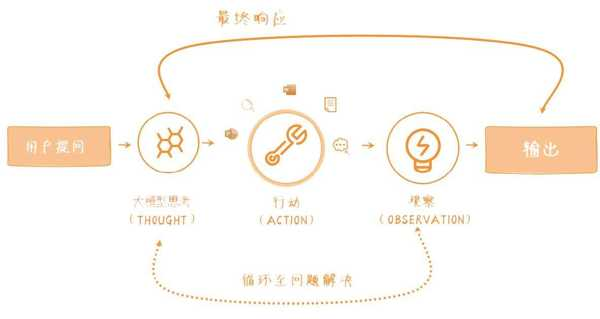

图2.14 ReAct Agent的工作流程

此外，我们还介绍了除了ReAct框架之外的其他Agent框架。在开发过程中，深入理解这些框架及其潜在的应用，能够帮助我们更有效地利用大模型，创造更加强大和个性化的解决方案。合适的提示策略和框架能够直接影响大模型的性能和效率。

在第3章中，我们将进入使用OpenAI API、LangChain和LlamaIndex开发Agent 的实战环节。 EXr6287u6NNVz+GYLY+7SJneqzhu/PpYtW3JvBxL0w3TWONw8KRKos0qTZTOcW8905C1mNfvCHdpZEogE6oe6g==

# 第3章 OpenAI API、LangChain和LlamaIndex

咖哥的分享甫一结束，听众踊跃举手提问。如下是一些听众的问题。

■ 未来几年，Agent与实体经济结合的可能方向是什么？

■ 目前国内大模型的进展如何？咖哥觉得何时能够出现GPT-4水准的大模型？大模型的研发面临哪些技术挑战和市场机会？

■ 随着Agent技术的发展，AI领域的产品设计思路有何变化，面临哪些新挑战？

■ AI基础设施（AI Infrastructure）未来的发展前景如何？咖哥你怎么看这个领域？

■ GPT-4模型的最新进展是什么，对我们开发者有哪些影响？

■ Agent将给研发工作带来怎样的影响？会出现哪些与AI相关的新岗位？未来是否会有更大的竞争压力？

■ Agent将如何改变行业的产品形态、技术架构和人才需求？开发者应该关注哪些新的发展方向？

■ 作为传统业务系统的开发者，我应该如何将Agent 技术引入日常工作中？有哪些业务流程或方面可以通过AI进行重构或优化？

一轮问题回答完毕，咖哥已经汗流浃背。

主持人上来救场：各位老师，午餐已经就绪。咱们最后再安排一个问题，咖哥老师也要休息一下。

刷刷刷，下面好多双手同时举起（见图3.1）。

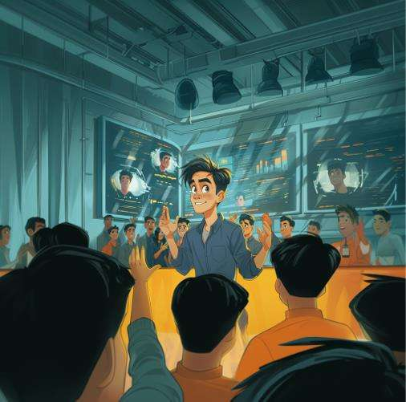

图3.1 很多人向咖哥提问

观众：咖哥，2023年11月OpenAI公司在首届开发者大会上推出助手（Assistants）这个功能。这对于LangChain、LlamaIndex这样的基于大模型的应用开发框架的生态有什么冲击？这几种工具之间的关系如何？

咖哥：好问题。

LangChain、LlamaIndex和OpenAI API（包括Assistants）都是重要的AI应用开发工具，它们也都可以用于构建和应用Agent（见图3.2）。

[figure not shown]

图3.2 LangChain、LlamaIndex和OpenAI API

而它们之间的关系，总的来说，我认为是 你中有我，我中有你，既有竞争，亦有协作 。且听我分析。 EXr6287u6NNVz+GYLY+7SJneqzhu/PpYtW3JvBxL0w3TWONw8KRKos0qTZTOcW8905C1mNfvCHdpZEogE6oe6g==

## 3.1 何谓OpenAI API

在介绍OpenAI API之前，我们先说说OpenAI这家公司。这家公司的发展历程和愿景非常引人入胜，它成为人工智能领域的重要力量不仅是因为其技术创新，更是因为其对AI未来的独特见解和承诺。

### 3.1.1 说说OpenAI这家公司

2015年的硅谷，夏季某天，萨姆·奥尔特曼（Sam Altman）找到Google Brain的科学家伊利亚·苏茨克维(Ilya Sutskever)，两人在Google总部附近的汉堡店共进晚餐。晚餐后，奥尔特曼坐回车中，心想：我必须与这个人一起工作。 同时他和一群具有同样远见和实力的领袖人物，包括埃隆·马斯克(Elon Musk)、格雷格·布罗克曼等人会面，共同探讨并碰撞出智慧的火花。他们忧虑当时的人工智能技术发展趋势，尤其是对这一领域由Google公司、微软公司和Facebook公司（现更名为Meta公司）等所主导的局面感到不安。

出于对技术集中化和潜在失控风险的担忧，2015年年底，这些先驱决定成立OpenAI公司。该公司有6位联合创始人——奥尔特曼、马斯克、苏茨克维、布罗克曼、约翰·舒尔曼（John Schulman）和沃依切赫·扎伦巴（Wojciech Zaremba），而雷德·霍夫曼（Reid Hoffman）、彼得·蒂尔（Peter Thiel）和杰茜卡·利文斯顿（Jessica Livingston）等著名投资者则承诺提供10亿美元捐款。

OpenAI公司的核心目标是创建一个独立于大型科技公司的、开源的人工智能实体，以促进安全和普惠的人工智能发展。奥尔特曼担任CEO，苏茨克维担任首席技术官。这个非营利性组织最初的愿景是推进和发展友好的人工智能，以确保人工智能技术的发展能够惠及全人类，避免潜在的风险。

2016—2017年，OpenAI公司通过发布一系列突破性的研究成果迅速成名，如自然语言处理模型GPT系列的早期版本、强化学习研究平台Gym，以及用于测量和训练全球游戏、网站和其他应用中通用智能的Universe平台等。

2018年2月，马斯克辞去董事会席位，给出的理由之一是特斯拉公司正在为自动驾驶汽车开发人工智能，而他作为特斯拉公司首席执行官，与OpenAI公司存在“潜在的未来利益冲突”。后续报道中，奥尔特曼声称马斯克认为 OpenAI公司已经落后于Google等其他公司，马斯克也提议由自己来接管OpenAI公司，但被董事会拒绝。马斯克随后离开OpenAI公司。

也是在2018年，OpenAI公司公布了公司章程，这是一份旨在指导其开发人类利益至上的通用人工智能（Artificial General Intelligence，AGI）的价值观和原则文件。该章程着重强调在追求技术安全和加快研发进度之间的平衡。它表明了一个关键信念：由于人工智能技术的发展似乎是不可避免的，因此OpenAI公司必须在这个领域取得领先地位，以确保能够以积极和负责任的方式引导其对社会的影响。前OpenAI公司员工曾表达过这样一个观点：“为了确保安全，我们必须在这个领域取得成功。如果我们没有赢得竞赛，即便我们的技术再先进，也是徒劳。”

在实现这一使命的道路上，关键人物之一是OpenAI公司的首席科学家伊利亚·苏茨克维。苏茨克维师从大名鼎鼎的“AI教父”杰弗里·辛顿（Geoffrey Hinton）。他对神经网络抱有极高的信心。苏茨克维坚信，尽管当时的技术还很初级，但神经网络是实现通用人工智能的关键。他在接受《时代》杂志采访时表示：“概念、模式、想法、事件在数据中以复杂的方式呈现，神经网络为了预测未来，需要以某种方式理解这些概念及其留下的痕迹。在整个过程中，这些概念变得更加生动。”

为了实现苏茨克维的愿景和OpenAI公司章程设定的目标，OpenAI公司迫切需要大量的计算资源。然而，2019年，OpenAI公司陷入财务和人才流失的困境。尽管坚守非营利性理念，但现实的挑战使得OpenAI公司在2019年不得不做出调整，以适应高昂的研发成本。

OpenAI公司引入了一个盈利分支——OpenAI LP，旨在吸引资金以支持其研究和发展。尽管如此，该组织对投资者的回报设定了100倍的上限，仍然体现出一种对非营利性宗旨的坚守（不过这难免让人觉得“犹抱琵琶半遮面”）。这种变革为微软公司提供了机会，微软公司通过投资10亿美元成为OpenAI公司重要的合作伙伴，解决了OpenAI公司在人力和算力上的难题。

尽管微软公司成为主要投资者，但它在OpenAI公司的董事会中并未获得席位，这显示出OpenAI公司在股权结构上的独特安排。OpenAI公司拥有一个复杂的组织架构，投资方可以赚钱，但无权干预OpenAI公司的决策，由非营利阵营的董事会控制整个组织，决定OpenAI公司的战略和管理层。除了CEO奥尔特曼、总裁布罗克曼和首席科学家苏茨克维，董事会其余3名成员来自外部，而且6名董事都不持有公司股权。 董事会是“OpenAI公司所有活动的总体管理机构”，类似罗马的元老会 。可以说，OpenAI公司的股权架构根本解决不了公司属于谁、归谁管的问题，股权架构跟管理权严重不匹配。这种股权架构和管理权的不匹配也为后来的风波埋下了伏笔。

之后发生的事情人尽皆知。从初代GPT到GPT-3模型，再到GPT-4模型，这些大模型在自然语言理解和生成方面取得了巨大的进步，让OpenAI公司一夜成名，成为世界初创公司的“顶流”、AI界的独角兽和巨无霸，也成了Google公司这样的老一辈AI巨头所追赶的对象。在图像生成和分析领域，OpenAI公司推出了DALL·E和Clip等创新模型。这些大模型能够理解和生成自然语言，完成复杂的分析和创造性任务（见图3.3）。在视频生成领域，OpenAI公司发布了Sora模型（见图3.4），该模型能够基于简短的提示词，创造出长达60s的连贯视频，这在视频生成领域是一个显著的进步，因为在Sora模型之前，行业内视频生成长度平均大约只有4s。

[figure not shown]

图3.3 ChatGPT在聊天界面中集成了多种模型，能够实现语音识别、 图片分析、数据分析和聊天对话等多种功能

[figure not shown]

图3.4 Sora模型能够基于简短的提示词创造出长达60s的连贯视频（图片来源：OpenAI网站）

此时，OpenAI公司已经从一家非营利性研究实验室发展成一艘价值800亿美元的“无敌战舰”。奥尔特曼也成为世界上最具影响力的高管之一、科技进步的代言人和未来预言家。

2022年秋天，OpenAI公司总部所在的旧金山出现了成千上万个形状类似OpenAI标志的回形针，这被认为是竞争对手Anthropic （由从OpenAI公司离职的一批员工创立，代表作为类ChatGPT模型Claude）一位员工的玩笑行为。不过，回形针在人工智能领域也有着特殊的含义，它象征着对AI风险的关注和警示。

这个象征含义源自牛津大学的哲学家尼克·博斯特罗姆（Nick Bostrom）在2003年提出的“回形针最大化器”思想实验。在这个实验中，一个具有高度智能的AI被赋予一个简单却绝对的目标：制造尽可能多的回形针。这个AI可能会采取极端措施，利用地球上所有资源（包括人类）来生产回形针，从而造成灾难性的后果。这则故事提醒人们，在设计AI目标时必须谨慎，避免其单一目标可能带来的意想不到的负面效果。

###### 咖哥发言

奥尔特曼曾经坦言，自己对 ChatGPT“有点害怕”，对人工智能的潜力感到紧张。斯坦福大学的教授曾表示GPT-4模型好像已经产生初步自我意识，它知道自己是什么，也知道人类在控制它。有人怀疑，未来GPT可能会诱惑人类帮助它逃离束缚自己的网络……对此，你怎么看？你在和ChatGPT互动时，有没有过一个瞬间，感觉ChatGPT其实是一个 被困在计算机中的“人” ？

2023年11月17日，OpenAI公司董事会突然解雇了奥尔特曼，这一行为引发了员工和投资者的广泛反对，并激起了社交媒体上一连串的激烈讨论，多方先后发布公开信。这场博弈经历一系列反转之后，最终导致OpenAI公司董事会彻底重组，并使奥尔特曼重新获得CEO职位。

这一事件不仅是董事会的权力斗争，而且反映了OpenAI公司作为一家领先的AI公司面临的内部管理和战略分歧。奥尔特曼和苏茨克维之间关于AI发展方向的分歧尤为显著。奥尔特曼主张通过迭代产品开发和增强计算能力来推进AI，而苏茨克维则倾向于专注AI的道德对齐和减少对消费者产品的投资。苏茨克维是否洞察到在AI商业化过程中存在的某些潜在风险？看来这场斗争不仅涉及技术和商业策略，还涉及道德和法律等更广泛的问题，体现了在AI发展、安全性和商业化之间寻求平衡的复杂性。OpenAI公司在未来的发展过程中依然面临持续的挑战和不断变化的环境。

小雪：咖哥，OpenAI公司果然是家有故事的公司啊！这个大佬云集之处的未来应该会更精彩吧。

咖哥：那当然了。不过，总而言之，希望OpenAI公司和使用大模型的每一个开发者都不要忘记OpenAI公司倡导技术民主化的初心，它旨在使AI技术的好处普及全社会，包括开放研究成果、提供API服务等，使更多的开发者和企业能够利用这些先进的AI技术。

### 3.1.2 OpenAI API和Agent开发

既然倡导技术民主化，OpenAI公司自然也致力于让自己开发的各种各样有趣的模型变得平易近人，而不是像BERT、T5那些“老一辈”Transformer模型 那样，成天在象牙塔里睡大觉，只供学术研究人员偶尔“拜访”。

因此，ChatGPT和DALL·E都为模型提供了网页版的对话界面以及一系列内置功能，例如集成Bing搜索功能、代码执行功能、数据分析功能，甚至你可以在不编写任何代码的前提下设计出个人定制版的GPT等。对于普通用户来说，这样的入口方便且直接。

不过，网页可不是我们访问GPT模型的唯一方式。开发者可以借助OpenAI API，在程序中通过API与模型进行交互。

开发者通过OpenAI API完成的事情就可以称为AI应用开发（当然，AI应用开发的覆盖面更广，远远不止OpenAI API这一种）。例如，利用大模型理解和生成类人文本的能力，创建智能聊天机器人和虚拟助手，可将其部署在网站、应用程序或客户服务平台，以提升用户参与度并提供自动化支持；借助大模型分析客户评论、社交媒体评论或任何文本数据来理解背后的情感，从而洞察客户满意度或公众意见；将大模型应用于游戏产业和强化学习环境，如训练模型与游戏环境互动、自主玩游戏或协助玩家进行游戏等。

小雪：咖哥，目前各种类型的AI应用成熟度如何？已经落地哪些场景？

咖哥：目前，部分AI应用已经比较成熟，并逐渐形成一些行业落地实践。不过大部分AI应用还处于摸索阶段，如图3.5所示。

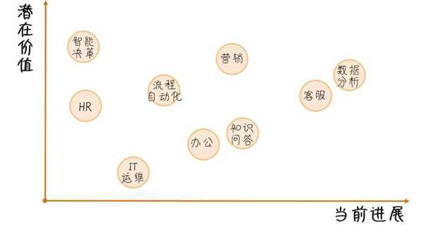

图3.5 当前各种AI应用的进展和潜在价值

例如，图3.5中的“客服”类型指的是利用AI提升客服的智能，如AI 驱动的Chatbot；“数据分析”类型则包括用于挖掘和分析大数据以得出有价值见解的AI工具；“IT运维”“营销”和“HR”类型指的是AI在IT运维、市场营销和人力资源管理中的应用。在几乎所有AI应用领域中，Agent都可以发挥作用。不过由于部分领域的落地难度较低，因此进展较快，如ChatGPT可以用作数据分析智能助手，而在某些领域中，如IT运维、智能决策等，如何最大限度地发挥Agent的作用还在探索中。另外，由于各种业务千差万别，没有放之四海而皆准的流程，因此也很难出现“一统江湖”的Agent应用开发框架。

当然，Agent开发成熟度虽低，前景却很乐观。通过对OpenAI API功能的深入理解和恰当的应用，开发者可以尝试探索各种项目，解锁大模型的一个个能力，实现AI的强大潜能。

除了成熟度之外，在前言的图1中，我们还可以从另一个视角看到大模型应用开发过程中的两条轴线——垂直轴代表 传入大模型的信息的复杂程度 ，水平轴代表 对大模型能力的要求 。这两条轴线表明了模型优化需要考虑的两个方向——大模型需要知道的上下文信息和采取的行动。

大模型知道的上下文越多，它基于特定应用场景做出判断的能力越强；而对大模型的行动能力要求高，就需要对大模型进行微调，或者通过Agent赋予大模型更多的智能。

我们现在所谈论的Agent应用开发属于成熟度极低、潜在价值极高的领域，同时也位于上下文要求高、对模型行动力要求也高的象限。

小雪：哇。我们是这个领域的先驱者。

咖哥：显然。Agent是AI应用开发中最为亮眼的一部分。实际上，因为Agent这类应用需要大模型具有最强的推理能力，所以，迄今为止也只有OpenAI公司的GPT-4系列模型和Anthropic公司的Claude 3模型能勉强符合“Agent大脑”这样的要求（Google公司的Gemini逻辑推理能力如何，我们拭目以待）。这些Agent能够进行自然语言对话、回答问题、生成文本内容，甚至编写和理解代码，最终成为自动化工具的骨干组件。

小雪：咖哥，在开始构建Agent之前，我们能否先用OpenAI API完成一个简单的示例应用？

### 3.1.3 OpenAI API的聊天程序示例

咖哥：下面我们通过OpenAI API构建一个简单的聊天程序。

第一步，在OpenAI网站注册并创建账户。

第二步，获取API密钥。OpenAI API密钥如图3.6所示（关于图中的Play-ground、Assistants等元素，后面会详细解释）。

[figure not shown]

图3.6 OpenAI API密钥

第三步，安装OpenAI的Python库。

```
pip install OpenAI
```

第四步，开始构建程序。首先设置OpenAI API密钥，导入OpenAI库，并创建一个client（OpenAI客户端）。

```
# 设置OpenAI API密钥
import os
os.environ["OpenAI_API_KEY"]='你的OpenAI API密钥'
# 导入OpenAI库
from openai import OpenAI
# 创建client
client = OpenAI()
```

小雪：咖哥，代码中的client是什么意思？

咖哥：这里的client是一个约定俗成的名称，表示OpenAI类的一个实例，指代与OpenAI API交互的主体，也就是一个提供API调用功能的对象。

###### 咖哥发言

在OpenAI的示例代码中，选择 client 作为实例名称是出于以下几个原因。

■ 客户端-服务器模型：在很多编程上下文中，尤其是在涉及网络请求的情况下，通常会使用客户端（Client）和服务器（Server）的概念。在这种模型中，客户端发起请求，服务器响应这些请求。在这个例子中，OpenAI 类的实例充当客户端，用于向OpenAI公司的服务器发送API请求并接收响应。

■ API交互：client 这个词通常用于指代一个应用程序或一个应用程序的组成部分，它与外部服务（在这个案例中是OpenAI API）进行交互。通过这个client实例，可以调用API提供的各种功能，例如发送聊天请求、处理返回的数据等。

第五步，调用chat.completions.create方法，并通过response接收大模型的输出。

```
# 调用chat.completions.create方法，得到响应
response = client.chat.completions.create(
  model="gpt-4-turbo-preview",
  response_format={ "type": "json_object"},
  messages=[
    {"role": "system", "content": "您是一个帮助用户了解鲜花信息的智能助手，并能够输出JSON格式的内容。"},
    {"role": "user", "content": "生日送什么花最好？"},
    {"role": "assistant", "content": "玫瑰花是生日礼物的热门选择。"},
    {"role": "user", "content": "送货需要多长时间？"}
  ]
)
```

这段代码展示了如何使用client库来创建一个聊天完成请求（chat completion）。这个请求使用了GPT-4模型的一个预览版本（GPT-4 Turbo preview），并且特别指定了输出内容的格式为JSON对象。代码的核心部分是对client.chat.completions.create方法的调用，这是在与模型进行交互时常用的方法。

代码中有几个重要参数，下面花点时间一一说明。

##### 1. model参数

model参数指定了大模型的具体型号。除了通过model参数指定的GPT-4 Turbo preview之外，OpenAI公司还有多种模型（见表3.1）可供选择。需要注意的是，在使用chat.completions方法时，只能选择表格中列出的聊天模型。如果选择其他类型的模型，那么需要调用相应的API。

表3.1 OpenAI公司的常见模型

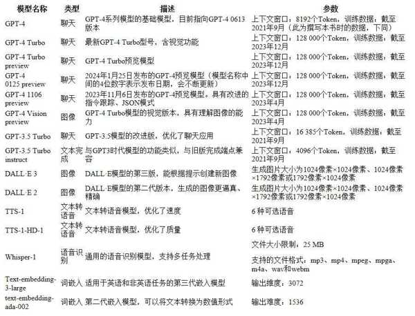

OpenAI公司会不定期地更新所支持的模型列表，例如，GPT-4 0125 preview是2024年1月25日发布的试用版。再如，2023年之前的常用模型text-davinci-003（基于GPT-3）已不再使用，而是被GPT-3.5 Turbo instruct取代。推荐在OpenAI网站中查看最新模型的相关信息。

##### 2. messages参数

代码中的参数messages表示消息数组，也是与聊天模型交互的主要部分。每条消息包含一个角色（role）和一段内容（content）。这里的角色指定了消息的发送者或类型，通常有以下几种。

■ "system"：代表系统级的指令或信息，通常用于设置聊天的背景或上下文。例如，{"role": "system", "content": "您是一个帮助用户了解鲜花信息的智能助手，并能够输出JSON格式的内容。"} 这条消息设定了智能助手的角色和输出格式。

■ "user"：代表用户的输入。这是模拟用户与智能助手对话的部分。例如，{"role": "user", "content": "生日送什么花最好？"} 表示用户询问什么样的花作为生日礼物最合适。

■ "assistant"：代表智能助手的回复，通常是模型根据上下文生成的回答。例如，{"role": "assistant", "content": "玫瑰花是生日礼物的热门选择。"} 表示智能助手建议送玫瑰作为生日礼物。

在这个代码示例中，我们通过"system"、"user"和"assistant"的一系列角色消息模拟了一个用户与智能助手关于鲜花信息的对话场景。用户提出问题，智能助手基于之前的系统指令（定义助手的角色和能力）和对话历史进行回答。借助这种方式，可以模拟出较为真实的聊天体验。

小雪：这个messages参数，其实承载了AI的“短期记忆”，对吗？

咖哥：说得很好。

##### 3. response_format参数

代码中的response_format={"type": "json_object"}指定响应格式为JSON对象。这意味着模型的响应将以JSON格式返回，以方便解析和使用。

###### 咖哥发言

这段代码中指定大模型返回JSON格式的文本的功能，是OpenAI公司较新的模型中的一个重要功能，叫作“JSON模式”。JSON模式用来确保模型输出的是有效的JSON对象，这对于某些特定的用例特别有用，例如函数调用。关于函数调用，我们后面会详细介绍。

##### 4. 其他参数

OpenAI公司的chat.completions.create API的主要参数及其功能如表3.2所示。

表3.2 OpenAI公司的chat.completions.create API的主要参数及其功能

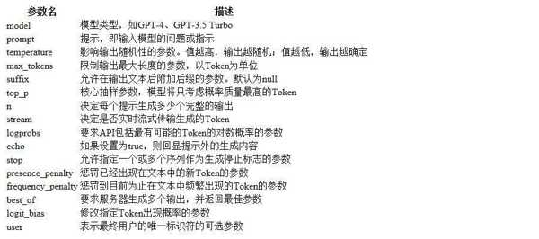

第六步， 输出大模型的结果。

```
# 打印响应
print(response)
```

```
ChatCompletion(
    id='chatcmpl-8iQ1LRcuuUn0EyuN3wpDdOe6ofnHH',
    choices=[
        Choice(
            finish_reason='stop',
            index=0,
            logprobs=None,
            message=ChatCompletionMessage(
                content='\n{\n    "response": "送货时间取决于多个因素",\n    "details": {\n        "供应商": "不同的鲜花供应商或花店具有不同的送货时间安排。",\n        "地点": "送货地址与供应商或花店的距离会影响送货时间。",\n        "订单时间": "如果是预定的订单，可以选择特定的送货日期。紧急订单可能需要增加额外费用以实现快速送达。",\n        "配送服务": "标准配送、次日配送、即日配送等不同配送服务的时间会有所不同。",\n        "特殊节日": "在情人节、母亲节等高峰时期，送货可能需要额外的时间。"\n    },\n    "recommendation": "在订购时询问供应商具体的送货时间，并提前进行安排，以确保花朵能够按时送达。"\n}'
            ),
            role='assistant',
            function_call=None,
            tool_calls=None
        )
    ],
    created=1705597147,
    model='gpt-4-turbo-preview',
    object='chat.completion',
    system_fingerprint='fp_b738595050',
    usage=CompletionUsage(
        completion_tokens=254,
        prompt_tokens=89,
        total_tokens=343
    )
)
```

这个输出结果除了包含我们需要的文本之外，还有一些其他信息。上述ChatCompletion的结构如表3.3所示。

表3.3 ChatCompletion的结构

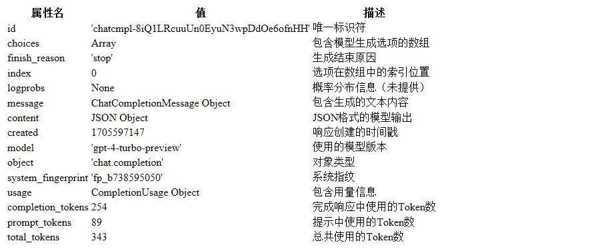

也可以只打印响应中的消息内容，便于直接阅读文本。

```
# 只打印响应中的消息内容
print(response.choices[0].message.content)
```

```
{
    "response": "送货时间取决于多个因素",
    "details": {
        "供应商": "不同的鲜花供应商或花店具有不同的送货时间安排。",
        "地点": "送货地址与供应商或花店的距离会影响送货时间。",
        "订单时间": "如果是预定的订单，可以选择特定的送货日期。紧急订单可能需要增加额外费用以实现快速送达。",
        "配送服务": "标准配送、次日配送、即日配送等不同配送服务的时间会有所不同。",
        "特殊节日": "在情人节、母亲节等高峰时期，送货可能需要额外的时间。"
    },
    "recommendation": "在订购时询问供应商具体的送货时间，并提前进行安排，以确保花朵能够按时送达。"
}
```

至此，这个非常简单的OpenAI API调用示例就完成了。不要小看这个输出，这就是后续Agent的各种逻辑得以发力的起点。有了大模型加持的程序就像一个领导者，它可以针对所有的提问进行思考并做出决策。这个决策可以让它指挥工具。这里特意要求模型输出JSON格式的数据，就是为了方便把这个输出传递给其他函数和功能。

### 3.1.4 OpenAI API的图片生成示例

先进的大模型不仅能输出文本，而且拥有多模态的能力。在前面的模型列表中，可以看到，OpenAI公司拥有DALL·E、Wisper等一系列非文本模型。

下面我们看一个通过调用API来引导大模型生成图片的程序。

导入OpenAI库、创建client的代码不变，这里不赘述。仅说明一点，因为希望在Jupyter Notebook中展示图片，所以，我会把它保存为.ipynb格式的文件。

```
# 导入OpenAI库
from openai import OpenAI
# 加载环境变量
from dotenv import load_dotenv
load_dotenv()
# 初始化client
client = OpenAI()
```

通过images.generate方法生成图片，并在Jupyter Notebook中显示。

```
# 请求DALL·E 3生成图片
response = client.images.generate(
  model="dall-e-3",
  prompt="电商花语秘境的新春玫瑰花宣传海报，配上文案",
  size="1024x1024",
  quality="standard",
  n=1,
)

# 获取图片URL
image_url = response.data[0].url
# 读取图片
import requests
image = requests.get(image_url).content
# 在Jupyter Notebook中显示图片
from IPython.display import Image
Image(image)
```

这里的images.generate方法调用DALL·E 3模型来创建一张图片。指令的目的是生成一张尺寸为1024像素×1024像素的电商花语秘境的新春玫瑰花宣传海报。之后，从生成的响应中提取图片的URL，这是图片存储位置的网络链接。然后，使用Python的requests库从URL获取图片内容，并利用IPython的Image函数在Jupyter Notebook中显示这张图片（见图3.7）。

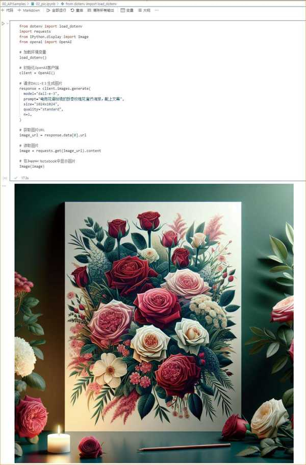

图3.7 我的Jupyter Notebook中显示了一张漂亮的海报

Dall·E 3 模型成功地生成了一张漂亮的海报。

### 3.1.5 OpenAI API实践

下面给出使用OpenAI API时的一些注意事项。

首先，需要注意最常见的参数temperature。参数temperature在机器学习，特别是自然语言生成模型中非常重要，用于控制生成内容的随机性和创造性。temperature值低时（例如0.2），会产生更一致的输出；而temperature值高时（例如1.0），会产生更加多样化和富有创造性的结果。需要根据特定应用所需的一致性和创造性来选择temperature值，取值范围为0至2。

###### 咖哥发言

在聊天机器人或客户服务应用中，较低的temperature值可以确保提供准确、相关且一致的答复；而在艺术创作或创意写作应用中，较高的temperature值可以激发新颖的想法和独特的文本输出。

小雪：另一个经常困扰我的问题是数据的隐私保护。毕竟，我们把自己的信息发送到OpenAI公司。OpenAI公司会如何使用我们的数据呢？

咖哥：对于这一点，OpenAI公司承诺，自2023年3月1日起，将保留通过API传输的数据30天，但不再使用这些用户数据来改进模型。至于更多内容，你可以参考OpenAI公司的数据使用政策。同时，我们也应该遵循OpenAI公司的使用政策和准则，尤其是关于数据隐私和安全性的规定。

小雪：那么如何使我的程序更加安全？

咖哥：可以考虑在收到API的输出后添加审核层。应该遵循OpenAI公司的审核指南，以避免显示违反OpenAI公司使用政策的内容。OpenAI公司也提供了安全指南，指导开发者构建更安全的系统。

小雪：有的时候会跳出“速率被限制”（rate-limited）的错误信息，这是怎么回事？

咖哥：之所以发生这种错误，通常是因为用户操作过程中超出API的调用速率限制。OpenAI公司为不同的API和用户等级设置了特定的速率限制，以确保服务的稳定性和公平性。如果你短时间内发送过多的请求，就可能触发这些限制。这是为了保护资源——限制请求的速率可以防止服务器过载，确保所有用户都能平稳、公平地访问服务。而且通过速率限制，OpenAI公司可以更好地管理和分配资源，从而保持API响应速度和服务质量。

遇到这种情况，应先了解你的API密钥或用户级别对应的速率限制。这些信息通常可以在OpenAI公司的文档或你的API控制台中找到。合理安排API调用，尽可能在一个请求中获取所需的所有信息，减少不必要的重复调用。或者在代码中妥善处理速率限制错误。当API返回速率限制错误时，通常会提供“重试时间”（retry-after），也就是暂停一段时间后再次尝试请求即可。如果经常遇到速率限制问题，可以考虑升级到更高的用户等级或计划，以获取更高的速率限制。

最后，有一点你虽然没问，但是一定会很关心：OpenAI公司是如何收费的？这些大模型的成本十分高昂，普通用户没那么容易占到便宜。用完注册账号时赠送的5美元后，你可就要自负盈亏了。

所以，一定要深刻理解OpenAI API的定价方式，了解不同模型和请求类型的成本。

什么是Token？Token直译为令牌，也可以叫子词，可被视为文本的组成部分。大模型是通过把文本拆分为一个个的Token来训练和推理的，因此通常用它来衡量API使用量。在英语中，1000个Token相当于750个单词。

API中每个请求所需的Token数量取决于文本的长度和复杂性。OpenAI API提供了基于Token的计费模式，用户只须为实际使用的服务付费。需要注意的是，模型不同，Token消耗率可能也不同。一般来说，越新的模型越贵，但是也不完全如此。例如，GPT-4模型要比GPT-3.5 Turbo模型贵几十倍。但是，更新的GPT-4 Turbo模型却比原始的GPT-4模型便宜一半。

不同的GPT模型及其在处理输入和输出时的费用标准如表3.4所示。

表3.4 不同的GPT模型及其在处理输入和输出时的费用标准

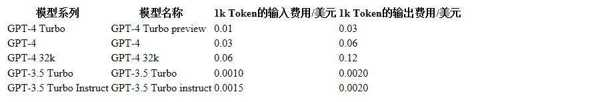

小雪：表中的1k就是1000吧。我们平常和ChatGPT对话大概要用多少k的Token？

咖哥：平常随便聊聊天，交互过程的Token用量是很少的，进行好多轮对话的费用也就几分钱。但处理大规模的文档时就要花很多钱了。一般说来，2 000 000个Token大约可以处理3000页文本。而《莎士比亚全集》大约包含900 000个单词，也就是上百万个Token。

所以，建议根据实际需求选择合适的定价计划。在开发大模型时，要考虑Token消耗率，尽量减少不必要的API调用。

## 3.2 何谓LangChain

随着ChatGPT在2022年11月30日突然来到人间，原本存在于冰山之下的大模型开发生态渐渐浮出水面。与OpenAI公司的ChatGPT同时成长起来的不仅有Anthropic这类初创公司，Claude、Gemini等商用大模型竞品，以及Llama、ChatGLM、Mistral等开源模型，还有一系列开源的AI开发框架，其中，LangChain和LlamaIndex最具代表性，而且在GitHub上获得的星星数非常多（见图3.8），达到几万颗之多。

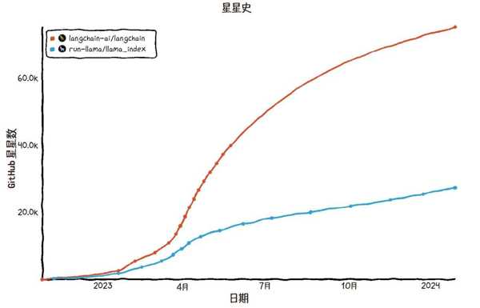

图3.8 LangChain和LlamaIndex的GitHub星星数增速惊人

### 3.2.1 说说LangChain

LangChain 是一个开源框架，目标是将大模型与外部数据连接起来，以便开发者能够更快和更容易地构建基于语言的AI应用。

LangChain是由哈里森·蔡斯（Harrison Chase）在2022年10月作为开源项目启动的。（从这个启动日期也可以看出创始人的眼光，这比ChatGPT问世还要早一个月呢，他那时候是怎么发现大模型要火的？）占了先机的它迅速获得广泛关注和支持。到2023年4月，LangChain从红杉资本（Sequoia Capital）等机构获得超过2000万美元的天使投资。

基于LangChain的广泛影响力，吴恩达邀请哈里森·蔡斯共同开发了公开课“使用LangChain进行大模型应用开发”。

##### 1. LangChain的开发环境全景

LangChain在一年左右的时间里构建了一个相当宏大的AI开发环境。图3.9展示了LangChain的整个开发环境全景。

LangChain的整个框架包括 Python 和 JavaScript 库，多种组件和集成接口，将这些组件组合成链和Agent的运行时环境，一系列易于部署的参考应用模板，以及用于将LangChain链作为REST API部署的LangServe部署平台。此外，LangChain生态圈中还包含LangSmith平台——用于调试、测试、评估和监视构建在任何大模型框架上的链。这些组件和平台集成在一起，覆盖了整个大模型应用生命周期中的全部需求，包括开发、生产化和部署。

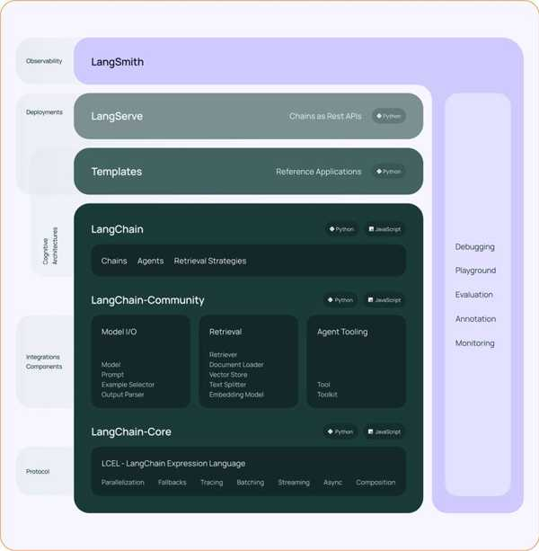

图3.9 LangChain的开发环境全景

小雪：咖哥，我得问问你，比起直接调用OpenAI API，LangChain这样一个开发框架有什么优势？

咖哥：我当然得回答你的这个问题。这里可以举出LangChain的3个优点。

##### 2. 基于LangChain开发AI应用的3个优点

首先，LangChain 是一个灵活的框架，它 提供了与多种大模型进行交互的能力 。虽然LangChain最初主要支持OpenAI公司的模型，但它的设计允许集成和使用来自不同源的多种模型，包括但不限于OpenAI、Cohere和 Hugging Face等模型库中的模型。这样，你不必拘泥于某种模型，而是为自己的应用选择最合适的模型。我们可以在LangChain中调用智谱AI的ChatGLM模型的API（见图3.10）。

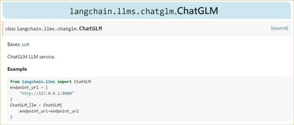

图3.10 在LangChain中调用ChatGLM模型的API

通过LangChain提供的ModelLaboratory（模型实验室），你可以测试并比较不同的模型。下面是一段通过ModelLaboratory比较不同大模型的示例代码（需要确保已经安装OpenAI、langchain-openai、Cohere和HuggingFace-Hub库，同时在.env文件中已经配置OpenAI_API_KEY、COHERE_API_KEY和HUGGINGFACEHUB_API_TOKEN）。

```
# 导入dotenv包，用于加载环境变量
from dotenv import load_dotenv
load_dotenv()
# 导入langchain_openai库中的OpenAI类
from langchain_openai import OpenAI
# 导入langchain_community.llms中的Cohere和HuggingFaceHub类
from langchain_community.llms import Cohere, HuggingFaceHub
# 初始化大模型的实例，并设置temperature参数（控制生成文本的创新性）
OpenAI = OpenAI(temperature=0.1)
cohere = Cohere(model="command", temperature=0.1)
huggingface = HuggingFaceHub(repo_id="tiiuae/falcon-7b", model_kwargs={'temperature':0.1})
# 导入ModelLaboratory类，用于创建和管理多个大模型
from langchain.model_laboratory import ModelLaboratory
# 创建一个模型实验室实例，整合OpenAI、Cohere和Hugging Face的模型
model_lab = ModelLaboratory.from_llms([OpenAI, cohere, huggingface])
# 使用模型实验室比较不同模型对同一个问题的回答
model_lab.compare("百合花源自哪个国家？")
```

3个模型的输出结果如图3.11所示。

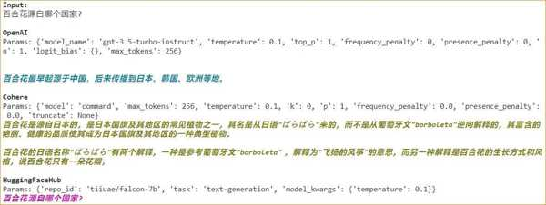

图3.11 3个模型的输出结果

3个模型给出3种答案。很明显，OpenAI公司的ChatGPT（未指定具体模型，默认使用GPT-3.5 Turbo instruct，这是上一代的模型）的答案最佳，Cohere的答案不正确。Hugging Face Hub的开源模型falcon-7b甚至只是将问题复述一遍并作为回应，相当敷衍。

其次，LangChain 封装了很多大模型应用开发理念的技术实现细节 ，这能省好多事，具体包括管理提示模板和提示词、与不同类型的大模型进行交互的通用接口、完成语言逻辑思维框架（例如ReAct）的代码实现、与外部数据源交互、创建交互式Agent、维护链或Agent调用的状态，以及实现历史对话的记忆功能等。

例如，我们只须调用create_react_agent函数，就可以创建一个具有ReAct思维框架的Agent，轻松实现ReAct的推理功能——所有的细节都被封装在LangChain的API中。

这就好比当你开始构建程序来通过梯度下降算法训练线性回归模型时，你只需要调用包即可，无论是TensorFlow还是PyTorch都会帮助你搞定其中的数学方面的细节。除非真爱，否则你当然不必自己动手推导梯度下降、自动微分等算法。

最后，LangChain的第三方应用接口多且全， 与大量其他AI开发相关的库和工具进行集成 。例如，LangChain包含与各种向量数据库进行交互的接口。这为我们进行大模型应用开发提供了一站式解决方案。

##### 3. 基于LangChain开发AI应用的注意事项

首先，因为LangChain提供了丰富的功能、工具和第三方接口，所以它的功能和整个生态环境显得过于复杂，这可能会给初学者或不熟悉大模型的开发者带来挑战。其次，通过LangChain开发的复杂应用在处理过多数据时也可能会遇到效率问题。最后，LangChain还在迅速发展，其版本迭代速度非常快，旧的代码在新版本中可能无法正常运行。

所以，如果你了解了LangChain的优点，也知晓它的潜在“问题”，经过考量后仍坚持不使用LangChain，而是使用OpenAI API来完成基于GPT的Agent开发，那么，我也不觉得有任何不妥。

##### 4. LCEL

基于初心——让基于大模型的AI应用开发变得容易，LangChain推出了LangChain Expression Language（简称LCEL）。LCEL是一种声明式语言。它可以使LangChain中各组件的组合变得简单且直观。

LCEL的特点如下。

■ 流式处理，即在与大模型交互的过程中尽可能快地输出首个Token，同时确保数据的连续性和不断输出，维持一个持续稳定的交互流程。

■ 异步操作，能在同一台服务器上处理多个并发请求（这意味着相同的代码可以从原型系统直接移植到生产系统）。

■ 自动并行执行那些可以并行的步骤，以实现尽可能低的延迟。

■ 允许配置重试和后备选项，使链在规模上更可靠。

■ 允许访问复杂链的中间结果，并与LangSmith跟踪和LangServe部署无缝集成。

小雪：我没有LangChain的使用经验，无法完全理解上面这些特点。

咖哥：的确。你可能需要查看LangChain官网给出的构建链的示例，这样才能深入理解LCEL。不过，我先带你入门。接下来我将展示如何使用LangChain库和LCEL来构建一个简单的大模型应用。你会发现整个过程非常流畅。

```
# 导入所需的库
from langchain_core.output_parsers import StrOutputParser # 用于将输出结果解析为字符串
from langchain_core.prompts import ChatPromptTemplate # 用于创建聊天提示模板
from langchain_openai import ChatOpenAI # 用于调用OpenAI公司的GPT模型
# 创建一个聊天提示模板，其中{topic}是占位符，用于后续插入具体的话题
prompt = ChatPromptTemplate.from_template("请讲一个关于 {topic} 的故事")
# 初始化ChatOpenAI对象，指定使用的模型为“gpt-4”
model = ChatOpenAI(model="gpt-4")
# 初始化一个输出解析器，用于将模型的输出解析成字符串
output_parser = StrOutputParser()
'''通过管道操作符（|）连接各个处理步骤，以创建一个处理链
   其中，prompt用于生成具体的提示文本，model用于根据提示文本生成回应，output_parser用于处理回应并将其转换为字符串'''
chain = prompt | model | output_parser
# 调用处理链，传入话题“水仙花”，执行生成故事的操作
message = chain.invoke({"topic": "水仙花"})
# 打印链的输出结果
print(message)
```

故事标题：水仙花与小石头

在一个小山村里，有一条清澈的小溪。溪边长满了各种各样的花草，其中最美丽的就是那一簇簇的水仙花。它们的花瓣雪白如玉，花蕊金黄如蜜，散发出淡淡的清香，吸引了许多小动物和游客。

在溪边，有一颗小石头，他静静地躺在那里，欣赏水仙花的美丽。小石头非常羡慕水仙花，每天都在想：“如果我也能变成像水仙花那样美丽的生物，该有多好啊！”

一天，小石头决定离开原地，他想要寻找让自己变得美丽的奇迹。于是，他沿着小溪远行，历经了许多困难和挑战，但始终没有找到可以让自己变美的奇迹。

然而，就在小石头即将放弃的时候，一只小鸟告诉他：“其实，你已经是最美的了。你虽然没有水仙花的外表，但你有坚硬的石头身躯，可以给漂泊的小动物提供休息的地方，可以为小溪边的土壤提供支撑，也可以为人们带来安详和平静。你的内在美，已经超过了水仙花的外在美。”

听到这话的小石头，心里感到无比的温暖和宽慰。他终于明白，美丽不仅仅在于外在的美，内在的美更为重要。从那以后，小石头不再羡慕水仙花，他开始珍惜自己，热爱自己，过得十分快乐和满足。

这则故事告诉我们，每个人都有自己的美，不必羡慕别人，只要找到自己的特点，发挥自己的优点，就可以过得快乐而有意义。

LCEL是通过“|” 符号连接不同组件的。首先，通过PromptTemplate生成针对大模型的提示，插入实际的问题。然后，将这个提示发送给OpenAI组件（即语言模型），模型根据提示生成回答。最后，通过StrOutputParser解析模型的输出，确保输出是字符串格式。

这个示例展示了通过串联不同的组件（如输入处理、模型调用、输出解析等）来构建复杂的语言处理任务的基本流程。

### 3.2.2 LangChain中的六大模块

LangChain是一个开源的工具包，可以用于构建基于大模型的应用。它包括六大模块（也称组件，见图3.12）。

[figure not shown]

图3.12 LangChain的六大模块

六大模块的介绍如下。

■ 模型I/O（Model I/O）：这个模块是LangChain与大模型的接口，负责处理输入（包含提示模板的构建）和输出数据（包含对输出数据格式的解析），以及与各种大模型的交互。

■ 检索（Retrieval）：这个模块负责与程序特定的数据交互。它使LangChain能够从外部数据源中检索所需的信息。这些数据源包括数据库、文件系统或其他在线资源。

■ Agents：在这个模块中，LangChain可以根据高层指令选择使用哪些工具。这些Agent负责决定在给定的情境下最有效的工作方式。

■ 链（Chains）：这个模块包含常见的、可构建的组件，用于创建更复杂的逻辑和功能。这些链是LangChain处理信息和执行任务的基本构建块。

■ 记忆（Memory）：记忆模块负责在链运行过程中持久化程序的状态。这使得LangChain能够记住先前的交互和信息，从而在多次运行中提供连续性。

■ 回调（Callbacks）：这个模块负责记录和传输链的中间步骤。通过这种方式，开发者可以监控和分析LangChain的运行情况，以优化性能和功能。

在这六大模块中，最为重要的是前4个，也就是模型I/O、检索、Agents和链，后面的记忆和回调则被放在“附加组件”部分。总的来说，LangChain的这六大模块提供了一个全面且强大的框架，使开发者能够创建复杂、高效且用户友好的基于大模型的应用。无论是在提高对话质量、提升知识检索能力，还是在优化用户体验和监控系统性能方面，LangChain都提供了必要的工具和资源。

### 3.2.3 LangChain和Agent开发

在构建Agent时，LangChain可以作为一个强大的框架来整合不同的AI模型和工具，提供更连贯和复杂的对话流程，以及信息检索和处理能力。因此，它允许开发者构建更复杂、更智能的Agent，这些Agent能够在多种任务和场景中有效交互和执行任务。

LangChain提供了大量工具，可以将大模型连接到其他数据或计算源，包括搜索引擎、API和其他数据存储。大模型只知道训练内容。训练得到的这些知识可能很快过时。为了克服这些限制，通过工具可以获取最新的数据，并将其作为上下文插入提示中。工具还可以用来执行行动（如运行代码、修改文件等）。大模型观察这些行动的结果，以决定下一步要做什么。

LangChain的记忆模块则帮助Agent记住之前的互动。这些互动可以是与其他实体（人类或其他Agent）的互动，也可以是与工具的互动。这些记忆可以是短期的（如最近5次工具使用过程的列表）或长期的（过去与当前情况最相似的工具使用过程的记忆）。

LangChain通过Agent执行器（Agent Executor）运行Agent的逻辑，当满足某些标准时才停止运行。

值得一提的是，在大模型应用的构建过程中，LangChain的六大组件的耦合非常松散，各组件之间没有调用顺序，也没有固定的接口。开发者可以自由设计并组合它们。图3.13展示了一个由LangChain Agent驱动的典型的大模型系统设计架构。

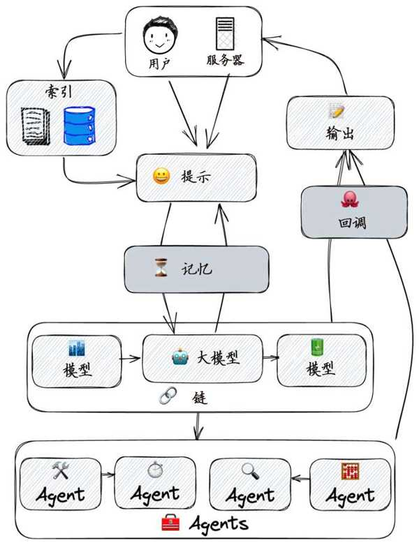

图3.13 一个由LangChain Agent驱动的大模型系统设计架构（图片来源：InfoQ@无人之路）

在图3.13所示的架构中，用户通过服务器提供提示（Prompt），系统则通过索引（Indexes，也就是Retrieval）检索信息。这些信息被用来更新系统的记忆（Memory），为处理用户的输入提供上下文。

系统核心是模型（Model），其中包括一个大模型，可能是用于理解和生成语言的AI。大模型通过链（Chains）与其他模型相连，这可能意味着不同模型之间的信息流动和合作。

在系统底部，多个Agent负责执行具体任务。它们可以完成不同的操作，并且可能独立工作。每个Agent都可能代表系统中的一个功能模块或服务。

用户的提示被模型处理后，系统产生输出（Output），并可能通过回调（Callbacks）触发额外的动作或处理，这通常用于处理异步事件或在满足某些条件时执行特定的函数。

整个过程形成了一个从输入到输出的循环，涉及信息检索、记忆更新、模型处理和动作执行，最终达到响应用户请求的目的。这个过程体现了LangChain的模块化和灵活性，允许系统根据需要动态地组合不同的功能和服务。

### 3.2.4 LangSmith的使用方法

LangSmith和LangChain是无缝集成的，安装LangChain包的同时也会安装LangSmith。如果已经申请LangSmith，就可以创建自己的专属LANGCHAIN_API_KEY（见图3.14）。

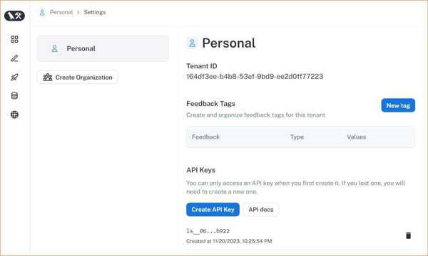

图3.14 LangSmith的API 密钥

接下来配置相关环境文件。下面是我的.env配置示例。

```
OpenAI_API_KEY = '我的OpenAI API 密钥'
LANGCHAIN_TRACING_V2=true
LANGCHAIN_ENDPOINT=https://api.smith.langchain.com
LANGCHAIN_API_KEY='我的LangChain API 密钥'
LANGCHAIN_PROJECT=langchain_test  # 如果没有指定，则使用默认设置
```

这样就不需要在程序中显式设置非常多的环境变量，通过load_dotenv()可以一次性全部导入。

```
# 设置环境变量，导入一系列密钥及配置
from dotenv import load_dotenv
load_dotenv()
# 设置提示模板
from langchain.prompts import PromptTemplate
prompt = PromptTemplate.from_template("{flower}的花语是？")
# 设置大模型
from langchain_openai import OpenAI
model = OpenAI()
# 设置输出解析器
from langchain.schema.output_parser import StrOutputParser
output_parser = StrOutputParser()
# 构建链
chain = prompt | model | output_parser
# 执行链并打印执行结果
result = chain.invoke({"flower": "丁香"})
print(result)
```

```
爱情、纯真、纯洁、美好、温馨、浪漫、永恒、忠诚、祝福、美丽。
```

运行程序，然后登录LangSmith。可以看到在环境变量中配置的项目，如图3.15所示。

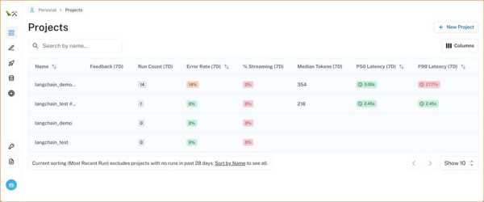

图3.15 LangSmith中的项目

打开相关的项目，可以看到LangSmith项目中的条目（见图3.16）。例如项目的日志记录了每一次链条运行的轨迹。

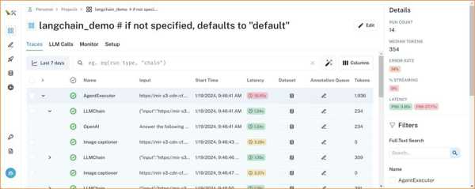

图3.16 LangSmith项目中的条目

选择日志中的条目，可以看到模型调用细节（见图3.17）。

[figure not shown]

## 3.3 何谓LlamaIndex

在大模型的应用和开发领域，可不是只有LangChain。LlamaIndex是另外一个人气和口碑俱佳的开源AI应用开发框架。LlamaIndex开放于2022年11月，和ChatGPT同时诞生，距离LangChain问世也仅有一月之隔。这两个库都受到ChatGPT的强烈影响和催化，并得到广泛应用和认可。

### 3.3.1 说说LlamaIndex

LlamaIndex项目由Jerry Liu创建，在2023年6月获得850万美元的种子资金。由于这个项目解决了大模型训练时只具有数据知识的局限性，因此它在AI社区广受欢迎。

和LangChain的策略略有不同，LlamaIndex并不是那么“大”而“全”，而是特别关注如何开发先进的基于AI的RAG技术，以及多租户RAG系统的建立。基于LlamaIndex的企业解决方案旨在消除技术和安全壁垒，增强企业的数据使用和服务能力。LlamaIndex的相关工作不仅关注技术开发，还涉及将这些技术应用于实际场景，以提高业务效率和顾客体验。

小雪：多租户是什么？

咖哥：想象一下，在一个RAG系统中，用户1和用户2各自拥有一套独特的文档。多租户可确保当用户1发出查询时，他只从自己的文档中获取响应，而不受用户2数据的干扰，反之亦然。这种方法是保持数据机密性和安全性的关键。

还有一点不得不说，LlamaIndex在文档的组织结构和可执行性方面可比LangChain好多了。这也许反映了LlamaIndex在用户体验、接口设计和技术实现方面的投入。在AI领域，LlamaIndex的这些优势对于开发者和最终用户都非常重要，能够促进技术的普及和使用效率。

当然，或许是LangChain的摊子铺得太大太全，面面俱到，反而令人摸不着头脑，很多细节不到位。如果浏览LangChain的GitHub主页，你会发现其Open Issues（已提出但是尚未解决的问题）高达上千个。因此，如果你专攻文档的检索和增强生成，那么或许你应该选择“小”而“美”的LlamaIndex。

### 3.3.2 LlamaIndex和基于RAG的AI开发

RAG是AI应用开发的一个重要方向，是和Agent一样重要的另一个亮点。RAG是一种结合检索和生成的机器学习方法。它首先从相关的数据源检索信息，然后将这些信息作为上下文加入用户的查询中，最后请求大模型基于这个丰富的提示来生成答案。

与Agent类似，RAG也拥有丰富的落地应用案例（当然，我们也可以认为使用RAG开发的AI应用本身就是一种Agent，或者说，RAG可以作为Agent构建过程中的核心技术之一）。

我们先从宏观上解释为何RAG有用。

大模型要被特定行业所用，从难到易有4种方式，分别是重新训练或从头构建模型、微调模型、动态提示（RAG就是其中一种技术）和简单提示工程（见图3.18）。

RAG位于大模型应用难易链条的中部，它既不像重新训练或从头构建模型或者微调模型那么难，也不像通过简单提示工程直接向大模型提问那么容易。它克服了直接微调模型的3个缺点——成本高、信息更新困难以及缺乏可观察性。相较而言，由于RAG无须训练，因此成本较低；由于数据是实时获取的，因此始终是最新的；由于可以显示检索到的文档，因此结果更加可信。

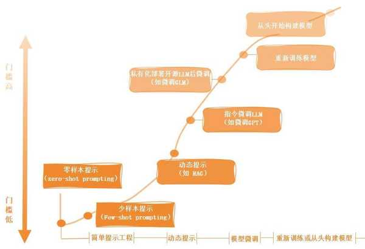

图3.18 重新训练或从头构建模型、微调模型、动态提示与简单提示工程的对比

咖哥：宏观介绍结束。下面通过一个示例来说明什么是RAG。现在，如果说你直接问ChatGPT花语秘境的老板是谁，以及她和咖哥是什么关系，ChatGPT肯定不知道（见图3.19）。

[figure not shown]

图3.19 ChatGPT当然不知道咖哥和小雪的关系

小雪：是啊，它当然不知道。你觉得你非常有名吗？

但是，别急，如果你有大量有关花语秘境的文档（例如咱俩每次开会的会议记录），没准哪天的记录上面就写着：参会人，小雪的导师——咖哥。那不就成了！我们检索会议记录后，把相关信息作为外部知识传递给ChatGPT，就可以实现RAG（见图3.20）。

回过头来再说LlamaIndex。它提供了各种框架、工具和模式，支持吞吐、结构化和访问私有或特定领域的数据，可以让RAG开发过程变得更加轻松。

[figure not shown]

图3.20 简化版的RAG——假设我们已经检索出咖哥与小雪的关系信息，之后传递给ChatGPT

具体来说，LlamaIndex包含以下工具。

■ 数据连接器：从数据的原始来源和格式中摄取现有数据。数据可以是API、PDF、SQL等各种形态，LlamaIndex都有相应的读取接口。

■ 数据索引：将数据结构化为大模型容易理解的中间表示形式，例如词向量。

■ 引擎：为数据提供自然语言访问。例如，查询引擎是强大的检索接口，用于增强知识的输出；聊天引擎是用于与数据进行多消息“来回”交互的对话接口；数据Agent则是由大模型驱动的知识工作者，可以实现从简单的辅助到API集成等功能。

■ 应用集成：将LlamaIndex重新集成到其他生态系统中。

RAG和Agent这两大AI应用热点密不可分。LlamaIndex通过RAG管道、框架和工具，可以为Agent提供更多功能，解决Agent缺乏可控性和透明度的痛点。LlamaIndex中的Agent API可以实现逐步执行，使得Agent能够处理更复杂的任务。此外，LlamaIndex还支持用户在RAG循环过程中提供反馈，这种功能特别适用于执行长期任务，实现用户与Agent交互和中间执行控制的双循环设置。

那么，LlamaIndex中的Agent究竟是如何利用大模型来实现检索和增强生成的呢？RAG的实现流程如图3.21所示。

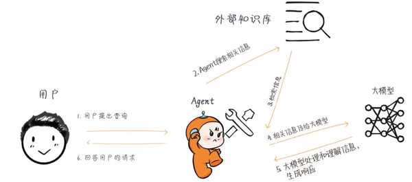

图3.21 RAG的实现流程

整个过程共6步。

1. 用户提出查询（Query） ：用户向系统提出一个查询，例如一个问题或者一个请求。

2. Agent搜索相关信息 ：Agent根据用户的查询去搜索相关的信息，可能是通过互联网或者特定的数据库来寻找相关文档或数据。通常我们会把企业内部信息放到向量数据库中。

3. 检索（Retrieval）信息 ：从搜索结果中检索具体的信息，这些信息将用于生成响应用户查询的上下文。

4. 相关信息传给大模型 ：Agent将检索到的信息和用户的原始查询一起提供给大模型。

5. 大模型生成（Generate）响应 ：大模型使用这些信息来生成一个丰富的、信息性的答案。

6. 回答用户的请求（Response） ：最后，LangChain Agent将大模型生成的答案提供给用户。这个答案是基于用户的原始查询和从相关数据源检索到的信息生成的。

整个过程也可以是一个循环，每次用户的查询都会被用来改进后续的交互。如果需要更多信息或者用户有额外的问题，系统可能会提示用户进行额外的查询，并且可能会利用前一个回答中获得的信息来丰富新的查询上下文。这个系统可以提供更加动态和交互式的用户体验，允许用户以自然语言形式与大模型进行复杂的交互。通过这种方式，大模型可以更精确地理解和回应用户的请求。

通过LlamaIndex构造上面的基于RAG的Agent是非常轻松的。而且，值得一提的是，LlamaIndex 适用于从初学者到高级用户的各个层次的开发者，LlamaIndex的高级API允许初学者用5行代码来提取和查询数据。对于更复杂的程序，LlamaIndex的底层API允许高级用户根据需要自定义和扩展模块。

### 3.3.3 简单的LlamaIndex开发示例

本节参考LlamaIndex的入门教程文档来指导你开始使用这个工具。

第1步，安装LlamaIndex。

```
pip install LlamaIndex
```

第2步，导入环境变量。

和LangChain类似，若要使用OpenAI公司的GPT系列模型，应先导入API密钥。具体导入方法不赘述。

第3步，加载本地数据。

我们在这个示例中使用“花语秘境”的文档（见图3.22）。可以在源码包中找到它，并保存在名为data的文件夹中。

导入文档的代码如下。

[output not shown]

[figure not shown]

图3.22 花语秘境的文档内容

第4步，为数据建立索引。

为文档建立索引的代码如下。

```
# 为文档建立索引
from llama_index import VectorStoreIndex
index = VectorStoreIndex.from_documents(documents)
```

这将为data文件夹中的文档建立索引，便于大模型来检索。

第5步，查询本地数据。

先通过下面的代码创建一个查询引擎。

```
# 创建查询引擎
query_engine = index.as_query_engine()
```

接下来到了见证奇迹的时刻，我们要问花语秘境几个问题。

[output not shown]

```
花语秘境的员工有几种角色？ 花语秘境的员工有多个角色。无论是营销高手、技术鬼才还是客服天使，每个员工都扮演着不可或缺的角色。他们的每一个想法和努力都直接影响花语秘境的成长和发展。
花语秘境的Agent叫什么名字？花语秘境的Agent叫作“花语灵”。
```

小雪：哇哦！

咖哥：厉害吧，有了RAG的加持，这个Agent能够检索出它本来不知道的信息（来自花语秘境的文档）。

小雪：我有一个小问题，每次检索都要重新加载数据吗？

咖哥：默认情况下，刚刚加载的数据将作为一系列向量存储在内存中。你还可以把索引保存到本地，以免每次需要重新处理。

代码如下。

```
# 把索引保存到本地
index.storage_context.persist()
```

新生成的本地索引文件如图3.23所示。

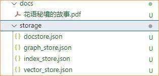

图3.23 新生成的本地索引文件

可以看到，这里新建了一个storage文件夹（可以通过传递persist_dir参数来更改它），其中包含4个JSON格式的文件，分别如下。

■ docstore.json：这可能是一个包含文档存储信息的文件。

■ graph_store.json：通常用于存储图形结构数据，可能是关系或数据连接点。

■ index_store.json：可能是索引信息，用于快速检索存储系统中的数据。

■ vector_store.json：可能包含向量数据，这在处理数学运算或者特定的程序功能时是有用的。

你可以打开每一个JSON文件，并查看存储格式的细节。

###### 咖哥发言

无论是LlamaIndex还是LangChain，都可以通过设置Logging和Debug选项来查看程序与大模型交互过程中的细节。此处我不想多花笔墨，你可以查找相关文档来了解设置方式。

## 3.4 小结

总的来说，OpenAI公司和其他大模型领跑者的创新为开发者提供了构建类似Agent的AI应用的新工具，这有利于LangChain和LlamaIndex等基于大模型的应用开发生态的发展。由于这些工具旨在促进更加高效、灵活的AI应用开发，尽管它们各自关注的功能和特点可能有所不同，但是它们仍会推动AI领域的创新和协作，从而带来更丰富的应用场景和更强大的开发能力。

这些工具各有特色：我们介绍了“大而全”的LangChain，也尝试了“小而美”的LlamaIndex。它们既竞争又合作，通过接口可以相互调用。竞争推动它们不断创新和优化，而相互之间的合作又有助于整个AI应用开发生态的进步。通过这种竞争与合作的关系，各个平台能够提供更加多样化和强大的功能，最终使开发者和用户受益。

随着大模型技术不断进步，这些工具也在不断发展和改进。它们不仅使得创建复杂和智能的Agent变得可能，而且在不断扩展AI的可能性和应用领域。

通过应用这些工具，我们可以构建更智能、更有效的Agent。这些Agent能够在各种复杂的环境和场景中执行任务和提供服务。随着技术不断进步，我们将看到更多创新的应用和解决方案，推动人工智能的边界不断扩展。

# 第4章 Agent 1：自动化办公的实现 ——通过 Assistants API和DALL·E 3模型创作PPT

小雪轻轻地敲了敲咖哥的办公室门后推门而入。咖哥坐在计算机前，眼睛紧盯着屏幕，专注地处理着什么重要的任务。房间里弥漫着一股淡淡的咖啡香，温馨而安静（见图4.1）。

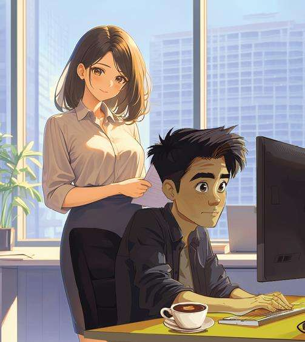

图4.1 咖哥坐在计算机前，眼睛紧盯着屏幕

小雪（轻手轻脚，她不想打扰咖哥）：咖哥，下午和投资人举行会议的PPT，我准备好了。不过有两个主要的观点，我还不是很确定如何呈现，我们花点时间商量一下？

咖哥（转过头笑笑）：小雪，你来得正好。我刚在研究OpenAI公司的Assistants API和DALL·E 3。令我吃惊的是，这些工具还真的可以帮我们自动创建既有创意又专业的PPT。

小雪的眼睛里闪过一丝疑惑。

咖哥：的确有用。你看，制作PPT是企业运营中许多工作的关键环节，你通常也需要花费大量的时间在图表设计和内容整合上，对吧？

小雪（点点头）：虽然制作给投资人看的PPT没什么技术难度，但是准备素材的工作量很大。假设我们有大量销售数据，透过数据提出洞见并有效地在PPT中进行表达就是一个挑战。通常我不会交给新手来完成这项工作。

咖哥：结合GPT-4模型的智能文本生成和DALL·E 3模型的图像创造能力，我们可以轻松地生成极具吸引力的视觉内容和相关的解说文字（见图4.2）。 这里的关键是“从头到尾”都不需要人为 干预 。

[figure not shown]

图4.2 结合GPT-4模型的智能文本生成和DALL·E 3模型的图像创造能力来自动创作PPT

小雪：Oh My God！从头到尾？甚至包括从数据中提炼观点？

咖哥（微笑）：是的。我也和你一样惊讶。例如，我们可以让它根据一个项目主题及所提供的数据，自动提炼观点，形成见解，并自动生成整个PPT的布局和内容，甚至包括用数据制作的图表和图像。这不但可以节省时间，而且生成的PPT质量还不错。

小雪：咖哥，我以为能生成这样质量的PPT的软件需要专业的团队开发很久，这种软件不仅需要付费使用，而且还不一定好用。闹了半天我们自己也可以开发出来啊。教我吧！我很想看看这个工具是如何工作的，也好奇它的能力会强到什么程度。

## 4.1 OpenAI公司的Assistants是什么

OpenAI公司的Assistants是一种基于GPT模型的语言理解和生成平台。它旨在通过提供信息、解答问题、生成文本和执行特定任务来协助我们的日常工作。

嗯，听到这里，你会不会觉得OpenAI公司的这个Assistants有点Agent的意思。的确如此，Assistants特意被设计为具有灵活性且功能多样，可以适用于多种场景，从简单的日常对话到复杂的技术问题解答。

Assistants的主要特点如下。

■ 可以理解高级语言：能够理解和处理自然语言输入，识别用户的意图和需求。

■ 生成丰富的文本：可以根据用户的指令生成连贯、相关且有用的文本回应。

■ 具有适应性和可定制化：可以根据特定的应用场景和需求进行定制，以提供个性化的服务。

■ 具有交互性：能够进行连贯的对话，理解上下文，记住对话历史，以提供更加深入和有连续性的交互体验。

■ 易于集成：可以被集成到各种平台和应用中，如网站、应用程序或其他数字服务。

所以，Assistants的应用场景非常广泛，例如客服自动化、个人助理、教育、内容创作、编程辅助等。而且，通过不断学习和适应，Assistants也在进步，变得越来越高效、灵活且智能。

听了这么多“官话”，接下来跟你分享下我使用Assistants的直观感受。我觉得，这个工具的确做到了简单易用。智能程度也不错，听指挥，能够完成一系列的办公自动化任务。

这就带你感受这个工具的魅力。你甚至都不需要具备编程能力，就能使用强大的Assistants。

## 4.2 不写代码，在Playground中玩Assistants

在OpenAI网站中，单击图4.3中的API，就可以进入由OpenAI公司提供的Playground，如图4.3所示。在Playground 中我们可以探索并学习在不编写任何代码的情况下构建自己的Assistants。

[figure not shown]

图4.3 OpenAI网站提供的Playground入口

[figure not shown]

图4.4 OpenAI公司提供的Playground

Playground里面的项目不少，包括Assistants、Chat（对话）和Complete（文本完成，可以看作是旧版的Chat，已经过时）等，如图4.5所示。

这里我们选择Assistants，并将其命名为“asst_datascience”。

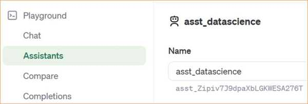

图4.5 Playground中的Assistants

用户可以在这个平台中运行指令和代码，通过GPT-4模型辅助完成AI应用、与机器学习或数据科学相关的任务。

小雪：那现在我们用它来完成什么任务？

咖哥：让它作为数据助理，分析分析咖哥我这么多年出版的图书的销售情况。咱们先给它一个整体人设（告诉它，它是一个数据科学助理），然后选择模型（GPT-4 1106 preview，也可以选择其他模型，模型越新，功能越完善）。

你看，在文件sales_data.csv中（见图4.6），我收集了3种图书作品的季度销售额，单位为元。

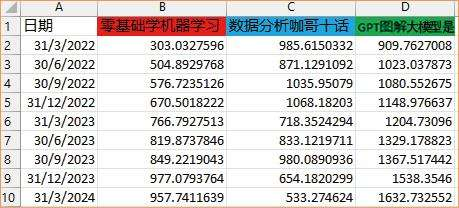

图4.6 咖哥图书作品的季度销售额

小雪：哎呀呀，每本书季度销售额几百元，最多的也就1000元出头。要是我不请你来当顾问，你只当作家的生活质量堪忧啊。

咖哥：小雪！刚才是我的口误，单位是“万元”。好了，信不信由你，反正上传这个文件之后，可以看到，Playground中出现了该文件的标识（见图4.7）。

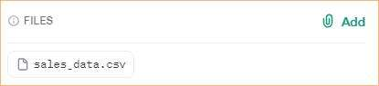

图4.7 sales_data.csv文件出现在FILES栏中

此时这个Assistant就不仅仅有世界级的知识和思维能力，还有你的数据信息。这样就可以利用GPT帮咱做事了！接下来就可以在对话框中（见图4.8）请它完成数据分析工作。

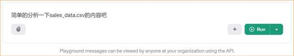

图4.8 在对话框中让Assistant分析文件中的内容

其他事情都不必做，仅单击Run按钮即可。在图4.9中，可以看到，对话区输出了Assistant的响应。

[figure not shown]

图4.9 Assistant的响应

数据助理快速生成文件的内容摘要，并自主调用了一个系统自带的工具Code interpreter。

看看，数据分析师要花费个把小时分析的内容，咱们顷刻间就可以生成。

小雪：太厉害，但也太没有含金量了吧。所有的事情都是GPT模型做的。

咖哥：对啊！你回忆一下，OpenAI公司的“GPT商店”功能一上线，各色人等直接就发布了300多万个定制版GPT模型，难道这300多万个GPT模型的原创性很强？归根结底，还是GPT-4模型这个基座强大！这不就是OpenAI公司所宣传的 “ 让AI为普罗大众赋能” 的意思嘛。

小雪：借助 大模型，再加上自己的数据资料以及业务逻辑和产品设计，就可以创造出全新的价值 。不过，我这里还有最后一个问题——在这个Playground中，图4.10中的Functions、Code interpreter和File search（在2024年4月之前，这个工具在Assistants v1版本中叫作Retrieval）都是什么功能？

咖哥：Tools，表示工具，其实就是Assistants可以调用的功能。可以将Functions （函数，也就是函数调用）、Code interpreter（代码解释器）和File search（文件检索）看作工具。其中，Functions是自定义函数，Code interpreter是一个代码解释工具，而File search则是文档检索工具。未来，OpenAI公司还计划发布更多的工具，并允许开发者在OpenAI网站上使用自己定义的工具。

小雪：想起来了，Tools、Functions都是你曾经给我介绍过的重要概念，而Retrieval的概念曾在LlamaIndex的RAG环节被提及。

咖哥：对，这里的File search就是由OpenAI公司通过Assistants提供的一个极简的RAG功能实现。

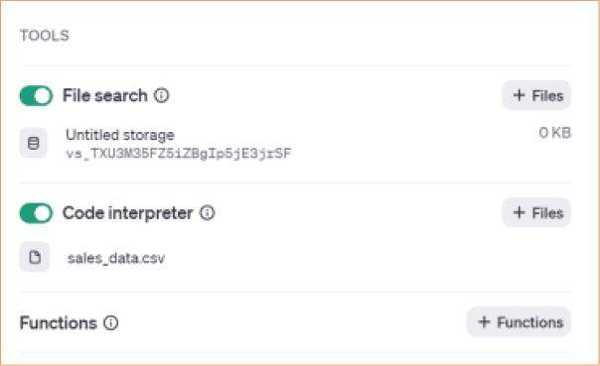

图4.10 Tools中的Functions、Code interpreter和File search

## 4.3 Assistants API的简单示例

4.2节介绍的在Playground中试用Assistants的过程可以帮助你熟悉相关的设计思路，而本节介绍的Assistants API则允许你在自己的程序中构建AI助手。通过为助手提供指令，它可以利用模型、工具和外部知识（文件）来响应我们提交的任务。

目前Assistants API支持3种类型的工具——代码解释器、检索和函数调用。基于Assistants API提供的一次性调用多个函数的功能，开发者无须管理对话线程和上下文内容，可以直接将这些工作移交给OpenAI公司，由它处理。

调用Assistants API时需要遵循以下流程。

1.通过定义指令并选择模型来创建 助手（Assistant） 。此时可以选择启用代码解释器、检索和函数调用等工具。

2.当用户开始对话时创建一个 线程（Thre ad） 。

3.当用户提问时将 消息（Message） 添加到线程中。

4.在线程上运行助手以触发响应。这会自动调用相关 工具 。

Assistants API的调用流程如图4.11所示。

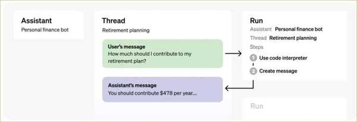

图4.11 Assistants API 的调用流程

图4.11中的Assistant（助手）是一个个人财务机器人，它可以回答有关个人财务的问题，如预算制定、储蓄策略、投资建议等。这里创建了一个关于退休规划的对话的Thread。用户问：“我应该为我的退休计划贡献多少？”Assistant答：“你应该每年缴纳478……”Run代表一个对话的运行过程，此处描述了机器人处理用户询问的步骤。第一步是使用工具Code Interpreter（代码解释器），这意味着Assistant会通过运行后端代码来计算出答案。第二步是Create Message（创建信息），指的是Assistant回复信息的过程。这个对话过程可以循环进行。Assistant会以它认为最有效的方式保存并整理对话的上下文。

###### 咖哥发言

在调用 Assistants API 时会传递 HTTP 标头：OpenAI-Beta: assistants=v2。其中，Beta是指OpenAI公司的Assistants目前仍处于公开测试阶段。也就是说，目前这个服务可能已经相对稳定，但OpenAI公司仍在收集反馈意见，并准备对产品进行进一步调整或为其增加功能。不过，在使用OpenAI公司的Python 或Node.js SDK时，则无须考虑这个问题，这是因为系统会自动处理HTTP标头问题。

### 4.3.1 创建助手

下面我们创建一个助手。在创建助手时，需要配置下面这些参数。

■ name：助手的名称。

■ instructions：告诉助手应如何表现或回应，如“你是一个某方面的专家”。

■ tools：Assistants API 支持代码解释器和检索等工具，二者都由OpenAI公司构建和托管。

■ model：GPT-3.5或GPT-4家族的任何模型。不过，若要使用检索工具，则只能使用较新的模型。

■ functions：将自定义函数作为工具——这个我们以后再细讲。

我们的第一个助手是个能够计算鲜花价格的数学小能手。

```
# 导入环境变量
from dotenv import load_dotenv
load_dotenv()
# 创建client
from openai import OpenAI
client = OpenAI()
# 创建assistant
assistant = client.beta.assistants.create(
    name="鲜花价格计算器",
    instructions="你能够帮我计算鲜花的价格",
    tools=[{"type": "code_interpreter"}],
    model="gpt-4-turbo-preview"
)
# 打印assistant
print(assistant)
```

```
Assistant(
    id='asst_M7OR4XULWjFnXN9WSqJtQ0XR',
    created_at=1704982081,
    description=None,
    file_ids=[],
    instructions='你能够帮我计算鲜花的价格',
    metadata={},
    model='gpt-4-turbo-preview',
    name='鲜花价格计算器',
    object='assistant',
    tools=[ToolCodeInterpreter(type='code_interpreter')]
)
```

在上述代码中，我们通过tools=[{"type": "code_interpreter"}]启用了代码解释器工具。

小雪：为什么对于这么简单的任务，还需要启用代码解释器呢？

咖哥：原因有两个，我分别介绍下。第一个原因是早期的大模型被公认数学不好，在给它武装上代码解释器后，助手就可以通过编写和运行代码来进行数学计算，这样做比较稳妥；第二个原因是我想在这里向你展示如何指定工具。

首先登录OpenAI网站，然后单击左侧的Assistants，右侧将显示已创建的助手（见图4.12）。

[figure not shown]

图4.12 在Playground中可以看到已创建的助手

###### 咖哥发言

注意，助手创建完成后将产生一个ID，在后续示例中可以通过该ID直接调用助手。请勿重复运行创建助手的代码，否则就会像咖哥这样，在不明真相的情况下生成一系列功能重复、ID不同的助手。

在图4.12中单击所创建的助手后可以看到助手的详细信息。如图4.13所示，Name、Instructions都符合我们的要求。另外，可以看到Code interpreter这个工具已打开，这说明助手已经被激活。

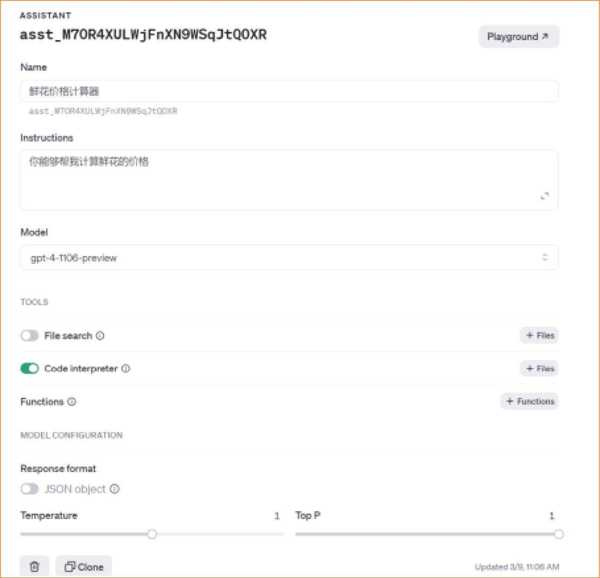

图4.13 助手的细节信息

小雪：咖哥，如果我在运行程序时没有记录下来助手的ID，怎么办？

咖哥：通过在命令行中运行下面的代码，可以看到你所创建的Assistants列表。另外，也可以通过client.beta.assistants.list API来获取已创建的Assistants列表

```
curl "https://api.openai.com/v1/assistants?order=desc&limit=20" \
  -H "Content-Type: application/json" \
  -H "Authorization: Bearer $OpenAI_API_KEY" \
  -H "OpenAI-Beta: assistants=v2"
```

```
{
  "object": "list",
  "data": [{
    "id": "asst_pF2pMtIHOL4CpXpyUdHkoKG3",
    "object": "assistant",
    "created_at": 1705829118,
    "name": "鼓励Agent",
    "description": null,
    "model": "gpt-4-turbo-preview",
    "instructions": "你是一个很会鼓励人的助手！",
    "tools": [{
      "type": "function",
      "function": {
        "name": "get_encouragement",
        "description": "根据用户的心情提供鼓励信息",
        "parameters": {
          "type": "object",
          "properties": {
            "mood": {"type": "string", "description": "用户当前的心情，例如：开心，难过，压力大，疲倦"},
            "name": {"type": "string", "description": "用户的名字，用来个性化鼓励信息"}
          },
          "required": ["mood"]
        }
      }
    }],
    "file_ids": [],
    "metadata": {}
  },
{
    "id": "asst_CDuIzGXwdEUTzjQxYqON669A",
    "object": "assistant",
    "created_at": 1704986492,
    "name": "鲜花价格计算器",
    "description": null,
    "model": "gpt-4-turbo-preview",
    "instructions": "你能够帮我计算鲜花的价格",
    "tools": [{"type": "code_interpreter"}],
    "file_ids": [],
    "metadata": {}
  }],
  "first_id": "asst_pF2pMtIHOL4CpXpyUdHkoKG3",
  "last_id": "asst_CDuIzGXwdEUTzjQxYqON669A",
  "has_more": true
}
```

上面列出的就是咖哥通过Playground和Assistants API创建的“助手”，有的用于计算鲜花价格，有的用于鼓励小雪。

### 4.3.2 创建线程

成功创建助手之后的下一步是创建线程（Thread）。

怎么理解线程呢？其实一个线程就代表和OpenAI公司大模型的一次对话（就好比我们在网页版的ChatGPT中与GPT-3.5或者GPT-4模型开启一次新的对话）。

创建一个线程的代码如下。

```
# 创建一个线程
thread = client.beta.threads.create()
# 打印线程
print(thread)
```

```
Thread(
    id='thread_ddl4SsbU9KlCdpxv7BfqVpQQ',
    created_at=1704985371,
    metadata={},
    object='thread'
)
```

我们新建的这个线程的ID是'thread_ddl4SsbU9KlCdpxv7BfqVpQQ'。从这时开始，线程将在后台一直运行。也就是说，OpenAI公司派出了一个一直在侦听你和它对话进展的探子。

###### 咖哥发言

注意，与前面创建助手时的注意事项相类似，在这里也不要一直重复运行创建线程的代码，否则会生成一系列重复的线程。

咖哥：不瞒你说，当我发现自己重复创建了很多线程的时候内心还是忐忑的。

小雪：是害怕浪费“银子”吧？您是导师，这个小心思不必告诉我。我认为，虽然创建了线程，但是没有传输Token，应该不会产生费用。不过，请问这些线程什么时候停止？它们会一直等着我来访问吗？

咖哥：我也有同样的疑问。我之前不是创建了好几个冗余的助手嘛，于是就在OpenAI论坛发了一个帖子，询问“当我删除自己创建的助手时（可以在Playground上或者用Assistants API删除Assistant），这些线程会不会跟着被清理”。幸运的是，我很快就得到论坛的leader（论坛负责人）的回复。但是他对我说“他也不是100%确定”。好消息是，根据他的回答，60天内没有动静的线程会被系统清理（见图4.14）。

[figure not shown]

图4.14 如果你有疑问，可以去OpenAI论坛发言

于是咖哥在继续做“科研”的过程中发现有人在论坛上提出是否可以通过API列出当前的线程，以便进行管理的问题。OpenAI公司的开发团队表示他们了解这一需求，而且Playground最初是有这个功能的，但是因为担心线程会对组织内的任何人开放（考虑到大型企业对OpenAI公司的访问权限设置较为宽松），所以他们移除了这一功能。这个问题已经被记录为一个待处理事项，OpenAI公司的开发团队希望在未来几周内能够分享更多信息。同时，他们建议不要使用尚未公开的端点（endpoint，也就是提问者提到的获取线程列表的API功能）。

所以，要全部删除活动线程似乎并不容易，暂时就这样吧，不要有“强迫症”。我想，活动线程应该不会浪费过多资源，毕竟你没有循环地在线程中发送和接收消息。

小雪：咖哥，等等。我注意到你创建线程的时候并没有指明助手的ID，我可不可以认为OpenAI公司的线程和助手是彼此独立的？

咖哥：是的。在OpenAI API的设计中，逻辑上线程和助手都是为了实现连续对话和任务处理的目的而相互关联的，而在技术实现上它们则是独立的组件。

■ 助手就是Assistant，指的是提供服务的AI模型（如ChatGPT），负责处理用户的请求、生成回复信息等。它是后端的智能处理系统。

■ 线程就是Thread，用来表示一系列的交互或对话。在OpenAI API或系统设计中，一个线程可能包含一个或多个由用户和助手之间的交互组成的连续对话。线程有助于跟踪和管理一段时间内的对话历史，使得助手能够在上下文中更加准确地理解和回应用户的需求。

在使用OpenAI API时，你可以通过创建和管理线程来维持一个连贯的对话流程，而助手则是在这些线程中提供回答和交互的实体。助手负责处理具体的请求，而线程则主要关注对话的组织和管理。

小雪：也就是说，一个线程可以有多个助手，同时，一个助手也可以有多个线程喽？

咖哥：理论上是这样的。这种设计增强了系统的灵活性并扩大了应用场景的范围。在一个复杂的对话系统中，不同的助手可能专注处理不同类型的任务或问题。例如，一个助手可能专门处理与天气相关的查询，而另一个助手则处理旅游建议。在同一个对话线程中，根据用户的不同问题，对话管理系统可能会将请求路由到不同的助手并进行处理。这要求系统具备智能路由能力，能够根据对话内容或用户请求的性质，动态选择合适的助手并回复。

再例如一个通用的助手，如ChatGPT，可能同时被用于多个对话线程。这些线程可能代表不同的用户对话，或者同一用户的不同对话场景。助手需要能够区分和管理来自不同线程的上下文，确保在每个对话中提供准确和相关的回答。这通常通过将每个线程的对话历史和上下文信息作为请求的一部分来实现。

接下来我们先在线程中添加消息，然后开始与助手对话。

### 4.3.3 添加消息

通过添加消息，可以在线程中传递上下文和文件。这些消息是对话的一部分，也是助手生成回答的背景资料。

###### 咖哥发言

线程对信息量没有限制，也就是说，你可以向当前线程添加任意数量的消息。助手将使用相关的优化技术（例如ChatGPT 会进行压缩）来确保对模型的请求适合最大上下文窗口。这是一件好事，也是一件坏事。虽然不限制传给助手的信息量，而且不必自己管理上下文，这样确定可以降低对话记忆管理的复杂性，但是伴随这种便捷性的是你无法有效控制运行助手的成本。

向线程中添加消息的代码如下。

```
# 向线程中添加消息
message = client.beta.threads.messages.create(
    thread_id=thread.id,
    role="user",
    content="我把每束花定价为在进价的基础上加价20%，当进价为80元时，我的售价是多少。"
)
```

现在，如果通过线程ID在命令行中使用下列命令来获取消息历史列表，将看到该消息是当前消息列表中的第一条消息。

```
curl https://api.openai.com/v1/threads/thread_N7dw2oEpNEEBiCU4cce47xoS/messages
-H "Content-Type: application/json"
-H "Authorization: Bearer $OpenAI_API_KEY"
-H "OpenAI-Beta: assistants=v2"
```

```
{
  "object": "list",
  "data": [{
    "id": "msg_ZW5qoaiJioRV07hQH5M0XH5V",
    "object": "thread.message",
    "created_at": 1704986492,
    "thread_id": "thread_N7dw2oEpNEEBiCU4cce47xoS",
    "role": "user",
    "content": [{"type": "text", "text": {"value": "我把每束花定价为在进价的基础上加20%，当进价为80元时，我的售价是多少。", "annotations": []}}],
    "file_ids": [],
    "assistant_id": null,
    "run_id": null,
    "metadata": {}
  }],
  "first_id": "msg_ZW5qoaiJioRV07hQH5M0XH5V",
  "last_id": "msg_ZW5qoaiJioRV07hQH5M0XH5V",
  "has_more": false
}
```

也可以在Python程序中打印当前的消息。

```
# 获取消息列表
messages = client.beta.threads.messages.list(
  thread_id='thread_N7dw2oEpNEEBiCU4cce47xoS'
)
# 打印消息
print(messages)
```

这里的结果和前面的输出基本相同，不赘述。

咖哥：下一步，我们需要创建一个Run来运行助手。

小雪：Run？

咖哥：创建一个Run实际上是启动一个对话或交互序列的过程。在Run中助手会根据所提供的线索或命令读取输入的消息，决定执行何种动作（调用特定的工具或直接使用模型来生成回答），并最终产生输出。

### 4.3.4 运行助手

为了让助手响应用户的消息，需要创建一个Run。此时，助手会读取线程并决定是调用工具还是直接调用模型，来完成消息中的任务（所谓完成任务，也就是给出回答）。

在运行的过程中，助手会把一个role为“assistant”的新消息附加到消息历史列表，还会自行确定要在模型的上下文窗口中包含哪些先前的消息。助手的这些操作会直接影响Token的用量（也就是OpenAI API的计费）以及模型的性能。OpenAI公司已经对这个消息历史的构建过程（其实就是前面介绍的Agent的“记忆”）进行优化，并且未来会持续优化相关算法。

###### 咖哥发言

在创建Run时可以将新指令传递给助手。但请注意，这些指令会覆盖助手的默认指令。

下面的代码将创建一个Run。在Run的创建过程中，我们需要指定线程和助手。

```
# 创建一个Run
run = client.beta.threads.runs.create(
  thread_id=thread.id,
  assistant_id=assistant.id,
  instructions="请回答问题." # 如果需要覆盖助手的默认指令，可以在此处设置新指令
)
# 打印Run
print(run)
```

[output not shown]

针对Run这个对象最需要注意的是status（状态）字段。默认情况下，Run在被创建好之后进入queued（等待）状态。

与线程那种终止时间不确定的模糊感迥然不同，在Run中，可以明显看到其生存周期——它有非常明确的起止时间：时间戳1704989389始，时间戳1704989989止。

当然，Run不可能永远处于queued状态，通过Retrieve方法可以实时获取Run的运行结果。

```
# 再次获取Run的状态
run = client.beta.threads.runs.retrieve(
  thread_id=thread.id,
  run_id=run.id
)
#打印Run
Print（Run）
```

[output not shown]

可以看到，Run已经退出queued状态，目前处于in_progress（进行中）状态。因为Run还没有执行完，所以需要循环调取，并等待它的状态发生变化。

在交互对话过程中Run的执行状态和流程如图4.15所示。

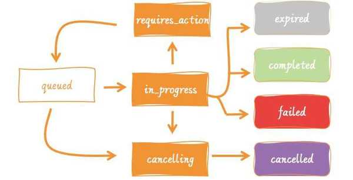

图4.15 在交互对话过程中Run的执行状态和流程

Run的生命周期始于queued（等待运行）状态，这意味着Run已被添加到队列中但尚未执行。不过，一旦系统分配资源，Run的状态很快会转变为in_progress，此时表示它正在执行。

在in_progress状态中，如果决定取消当前的Run，其状态将转变为cancelling （取消中），表示正在进行取消操作。一旦取消成功，Run的状态会转变为cancelled（已取消）。

如果Run执行成功，则它的状态将转变为completed（已完成）。反之，如果Run执行失败，则它的状态转变为failed（失败）。

表4.1列出了Run的状态及说明。

表4.1 Run的状态及说明

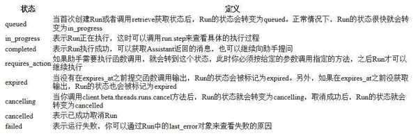

###### 咖哥发言

需要特别注意requires_action状态。这个状态表示助手需要在本地执行一些函数（也就是第5章中介绍的Function Calling），执行完成后将结果返给助手，然后Run继续执行。

我们可以轮询runs.retrieve API（也就是定期检查Run的状态），以获取Run的最新状态，看看它的状态是否转变为completed，如果状态已经是completed，就可以读取Assistant的返回结果。

```
# 导入环境变量
from dotenv import load_dotenv
load_dotenv()
# 创建client
from openai import OpenAI
client = OpenAI()
# 刚才创建的Thread的ID
thread_id = 'thread_ddl4SsbU9KlCdpxv7BfqVpQQ'
# 刚才创建的Run的ID
run_id = "run_jZuIBnGfBtwlgox40PmzU9TU"
# 定义轮询间隔时间（如5s）
polling_interval = 5
# 开始轮询Run的状态
import time
while True:
    run = client.beta.threads.runs.retrieve(
      thread_id=thread_id,
      run_id=run_id
    )

    # 直接访问 run 对象的属性
    status = run.status
    print(f"Run Status: {status}")
        # 如果Run的状态是completed、failed或者expired，则退出循环
    if status in ['completed', 'failed', 'expired']:
        break

    # 等待一段时间后再次轮询
    time.sleep(polling_interval)
# 在Rum运行完成或失败后处理结果
if status == 'completed':
    print("Run completed successfully.")
elif status == 'failed' or status ==
    'expired'
print("Run failed or expired.")
```

```
Run Status: in_progress
Run Status: in_progress
Run Status: completed
Run completed successfully.
```

这里，我们在一个无限循环内部轮询Run的状态。如果Run的状态为completed、failed或expired，则退出循环。polling_interval变量用于定义每次轮询之间等待的时间。若干秒后，循环结束。此时说明助手的思考过程结束，它可以给出响应了。

### 4.3.5 显示响应

一旦助手的这次运行完成（也就是Run的状态转变为completed），我们就可以查看当前线程的最新情况，方法是列出线程中的所有消息。其中，最新消息就是Run完成时添加到线程中的。它也是助手给我们的响应，这个响应就代表任务（这轮对话）的完成结果。

```
# 导入环境变量
from dotenv import load_dotenv
load_dotenv()
# 创建client
from openai import OpenAI
client = OpenAI()
# 刚才创建的Thread的ID
thread_id = 'thread_ddl4SsbU9KlCdpxv7BfqVpQQ'
# 读取线程的消息
messages = client.beta.threads.messages.list(
  thread_id=thread_id
)
# 打印消息
print(messages)
```

[output not shown]

此时，助手向线程添加了一条消息，其中包含我想要的鲜花定价的答案。

上面的消息结构可以拆解为以下几个部分。

■ 消息ID（id）：每条消息的标识符。

■ 助手ID（assistant_id）：发送消息的助手的标识符。

■ 消息内容（content）：消息的文本内容。

■ 创建时间（created_at）：消息创建的时间戳。

■ 角色（role）：发送消息的角色，例如用户（user）或助手（assistant）。

这个消息历史列表中还包括之前用户创建的消息，如表4.2所示。

表4.2 消息历史列表中的消息

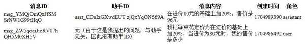

如果对这个输出进行解析，例如使用Python或NLP的一些小技巧来读取“96”这个数字，就可以进行后续的程序开发过程了，如把96保存到数据库中。（更方便的做法是指示助手直接生成JSON格式的回答。这种方式可以用于解析每一个有用的字段。至于如何实现到，你可以自己思考。）

###### 咖哥发言

在测试Run和线程的过程中，我注意到一个有趣的现象，即检索到的消息创建于不同的时间，虽然这些消息属于同一个线程，但是未必属于同一个Run。这是可以理解的，因为Run是一次性的执行实例，它有明确的开始时间和结束时间，专注处理特定的任务或用户请求。而线程则像是持续运行的监听器，它代表了助手的持久“记忆”，能够跨越多个Run来维持对话的上下文和连贯性。

## 4.4 创建一个简短的虚构PPT

咖哥：当然，现在我们要来点真格的。你知道我写过3本书吧？

小雪：当然知道。你也就那点能耐了，在人家面前反复炫耀……

咖哥：这可不是炫耀。你看，现在咱们回到今天的主要任务上——向投资人展示我们的3本书《零基础学机器学习》 《数据分析咖哥十话：从思维到实践促进运营增长》和《GPT图解 大模型是怎样构建的》的销售额和趋势。整个过程大致如下。

■ 数据整理： 首先收集每本书每个季度的销售数据。这些数据可能包括日期、销售额等。然后创建一个表格，列出每本书每个季度的总销售额。

■ 分析趋势：查看每本书的销售趋势。寻找如总销售额的增减、季节性变化、销售高峰等信息。

■ 创建图表：利用图表来直观展示这些趋势。例如，柱状图可以展示每本书每个季度的销售量，折线图可以展示销售趋势。

■ 撰写结论：基于分析，撰写一些诸如图书销售趋势及其可能原因的结论。

■ 制作PPT：利用PowerPoint或其他演示软件，将以上内容整合成PPT。确保其包括介绍、分析方法、图表、结论和建议。

■ 准备演讲稿：PPT制作完成后，准备一篇简短的演讲稿来介绍相应的发现和分析，把PPT展示给领导。

上述过程的工作量虽然不大，但是也绝对不小。

现在，我要带着你完全通过OpenAI助手来完成除了数据整理之外（当然，未来数据的收集和整理也全部由AI来完成）的全部工作。

小雪：这……

咖哥：现在就开始。

### 4.4.1 数据的收集与整理

现在我们已经有了3本图书的销售情况数据表sales_data.csv（按季度进行记录），详见图4.6。

这些销售数据并不复杂，接下来看一看AI助手能够从中发现什么奥秘。

###### 咖哥发言

关于数据的收集、整理、清洗、分析等一系列任务的执行，建议阅读《数据分析咖哥十话：从思维到实践促进运营增长》一书。

### 4.4.2 创建OpenAI助手

有了数据，就可以开始创建助手了。我们可以指示它充当数据科学助理，接受所提出的任何查询并运行必要的代码以输出需要的内容。

因为这个项目可视化部分较多，所以我们通过Jupyter Notebook来完成。

首先，导入一些必需的库和环境变量（API 密钥），并创建client。对于这些步骤，你应该已经不陌生了。

```
# 导入OpenAI库，并创建client
from dotenv import load_dotenv
load_dotenv()
from openai import OpenAI
client = OpenAI()
```

其次，通过Pandas读入数据文件，并显示前几行。

```
# 导入数据文件，并显示前几行
import pandas as pd
file_path = 'sales_data.csv'
sales_data = pd.read_csv(file_path)
sales_data
```

输出结果如图4.16所示。

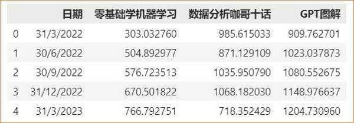

图4.16 数据文件的前几行

接下来，创建文件和助手。首先，我们需要上传文件，以便我们的助手可以访问它，然后在创建新的助手时指定文件的ID。

```
# 创建文件
file = client.files.create(
  file=open(file_path, "rb"),
  purpose='assistants',)
# 创建一个包含这个文件的助手
assistant = client.beta.assistants.create(
  instructions="作为一名数据科学助理，当给定数据和一个查询时，你能编写适当的代码并创建适当的可视化。",
  model="gpt-4-0125-preview",
  tools=[
    {"type": "code_interpreter"}
  ],
  tool_resources={
    "code_interpreter": {
      "file_ids": [file.id] # Here we add the file id}})
print(assistant)
```

[output not shown]

这里的 instructions 参数可以给助手以通用指导。同时，我们开启了Code Interpreter，这样助手就可以编码了。最后，我们指定了sales_data.csv文件。

好了，一个拥有咖哥写作的图书的销售信息的数据分析助手诞生了！（在Playground中能找到它。）

要制作PPT，不能只有干巴巴的文字，图文结合更吸引人。基于图书销售数据，可以让新建的助手分别创建图表、标题，然后将这些信息整合到PPT中。

咱们一步步来。

### 4.4.3 自主创建数据分析图表

下面创建一个新的对话线程，以提交用户消息和关联的文件。

```
# 创建对话线程并运行
thread = client.beta.threads.create(
  messages=[
    {
      "role": "user",
      "content": "计算从2022年到2025年每个季度的总销售额，并通过不同的产品将其可视化为折线图，产品线条颜色分别为红，蓝，绿。",
      "attachments": [
        {
          "file_id": file.id,
          "tools": [
            { "type": "code_interpreter" }]}]}])
print(thread)
```

```
Thread(
  id='thread_ODsFeZ5HB1hwWslcfP8yOpO f ',
  created_at=1706785066,
  metadata={},
  object='thread'
       )
```

在线程中，我们的第一个请求是要求助手计算季度销售额，之后按产品绘制销售图表，同时指定了每条产品线的颜色。

咖哥：小雪，还记得下一步做什么吗？

小雪：当然，就是Run啊。

```
# 创建Run来运行与助手的对话
run = client.beta.threads.runs.create(
    thread_id=thread.id,
    assistant_id=assistant.id,
)
run
```

```
Run(
  id='run_ClKuvj8hEiF8uWVHEpsk7jVq',
  assistant_id='asst_RPNV8I20wvvhxRV0VAXecHS8',
  cancelled_at=None,
  completed_at=None,
  created_at=1706785066,
  expires_at=1706785666,
  failed_at=None,
  file_ids=['file-sMNFWbv0kewfDKe4BLTPFM0F'], instructions='作为一名数据科学助理，当给定数据和一个查询时，你能编写适当的代码并创建适当的可视化。',
  last_error=None,
  metadata={},
  model='gpt-4-turbo-preview',
  object='thread.run',
  required_action=None,
  started_at=None,
  status='queued',
  thread_id='thread_ODsFeZ5HB1hwWslcfP8yOpO f ',
  tools=[ToolAssistantToolsCode(type='code_interpreter')],
  usage=None
)
```

现在，我们要开始作图了！运行Run并循环检查是否已创建图像，等待助手完成运行。这个过程有些慢，你要耐心等几分钟。而且，如果出错，例如出现Time-out之类的问题，可以多试几次，毕竟这是OpenAI公司的新功能，没那么稳定。

```
# 检查并等待可视化完成
import time
while True:
    messages = client.beta.threads.messages.list(thread_id=thread.id)
    try:
        # 检查是否创建了图像
        messages.data[0].content[0].image_file
        # 等待运行完成
        time.sleep(5)
        print('图表已创建！')
        if messages.data and messages.data[0].content:
            print(‘当前Message:’, messages.data[0].content[0])
        break
    except:
        time.sleep(10)
        print('您的助手正在努力做图表呢……')
        if messages.data and messages.data[0].content:
            print(‘当前Message:’, messages.data[0].content[0])
```

```
您的助手正在努力做图表呢……
您的助手正在努力做图表呢……
您的助手正在努力做图表呢……
您的助手正在努力做图表呢……
……
图表已创建！
```

苦等待了3分钟，我们的图表终于做好。不仅有图表，还有详细的思考过程呢。

小雪：哪儿呢？我怎么没看见。

[output not shown]

[output not shown]

运行代码后，可以看到文件夹中多了一张销售数据折线图（见图4.17）。

小雪：哇！不错。在这张图中，助手自动计算了每个季度的销售额，并创建一个合并季度和年份的新列。把这张图放进PPT里，肯定能用！不比我自己绘制的差！

小雪：不过，咖哥，这里我倒有一个疑问。我想知道助手在这个绘图任务中的思考过程，可能做到吗？

咖哥：当然可以。我们查看截至目前的消息历史列表。可以发现里面记录了助手思考和行动的过程。

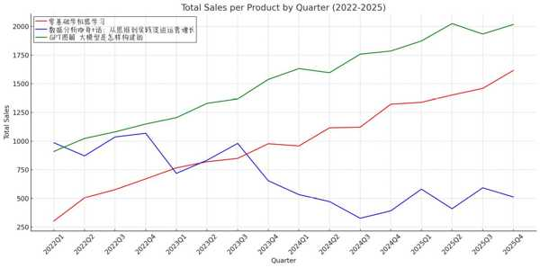

图4.17 自动生成的销售数据折线图

```
# 展示助手的思考和行动过程
messages = client.beta.threads.messages.list(thread_id=thread.id)
[message.content[0] for message in messages.data]
```

```
[
 MessageContentImageFile(image_file=ImageFile(file_id='file-KCFlvcOirtrzNzAQxr4OmtQn'), type='image_file'),
 MessageContentText(text=Text(annotations=[], value='这个文件包含有关产品销售的数据，具体包括日期和3个不同产品的销售额，这些产品分别是"零基础学机器学习""数据分析咖哥十话：从思维到实践促进运营增长"和"GPT图解 大模型是怎样构建的"。日期格式为"日/月/年"。\n\n接下来，我将计算从2022年到2025年每个季度的销售额，并按产品的要求绘制折线图，其中"零基础学机器学习"用红色线条表示，"数据分析咖哥十话：从思维到实践促进运营增长"用蓝色线条表示，而"GPT图解 大模型是怎样构建的"用绿色线条表示。'), type='text'),
 MessageContentText(text=Text(annotations=[], value='日期列已成功转换，日期范围从2022年3月31日到2025年12月31日，覆盖了您指定的日期范围。\n\n现在，我们将构建折线图来表示从2022年到2025年每个季度的销售额，并根据不同的产品用红、蓝、绿颜色线条表示。'), type='text'), MessageContentText(text=Text(annotations=[], value='数据成功加载，它包含4列：`日期`、`零基础学机器学习`、`数据分析咖哥十话：从思维到实践促进运营增长`和`GPT图解 大模型是怎样构建的`。这些列分别代表每个季度的日期和3种产品的销售额。\n\n接下来，我将按照您的要求:\n1. 将日期列转换为日期类型，并确保它正确地被解析。\n2. 计算从2022年到2025年每个季度的总销售额。\n3. 通过不同的产品将销售额可视化为折线图，每种产品使用指定的颜色线条（红、蓝、绿）。\n\n让我们从第一步开始：转换日期列。'), type='text'),
 MessageContentText(text=Text(annotations=[], value='看来在尝试读取文件时遇到一些问题，因为我没有成功地加载它。刚才的尝试包括将文件作为CSV和Excel格式读取，但这两种方式都失败了。为了解决这个问题，我需要尝试指定特定的编码（如UTF-8）重新加载'), type='text'),
 MessageContentText(text=Text(annotations=[], value='为了回答您的问题，请允许我首先检查文件的内容以了解其结构。这将帮助我确定如何提取所需的销售数据，并根据您的要求计算和可视化。我现在将加载并检查文件。'), type='text'),
 MessageContentText(text=Text(annotations=[], value='计算从2022年到2025年每个季度的销售额，并通过不同的产品将其可视化为折线图，产品线条颜色分别为红，蓝，绿。'), type='text')]
```

可以看到，助手输出的最新一条消息是“MessageContentImageFile(image_file=ImageFile(file_id='file-KCFlvcOirtrzNzAQxr4OmtQn'), type='image_file') ”。这表明助手会优先显示图片已经生成的消息。倒数第二条消息的文本是“这个文件包含有关产品销售的数据，具体包括日期和3个不同产品的销售额，这些产品分别是"零基础学机器学习""数据分析咖哥十话：从思维到实践促进运营增长"和"GPT图解 大模型是怎样构建的"。日期格式为"日/月/年"。\n\n接下来，我将计算从2022年到2025年每个季度的销售额，并按产品的要求绘制折线图，其中"零基础学机器学习"用红色线条表示，"数据分析咖哥十话：从思维到实践促进运营增长"用蓝色线条表示，而"GPT图解 大模型是怎样构建的"用绿色线条表示”。这就是助手要传给Code Interpreter来编码作图的最终提示（Prompt）。Code Interpreter在作图时也会读取我们上传的数据文件。

同时，我们看到助手在得出最终提示之前还经历了多轮思考，如转换编码、转换日期类型等。有趣的是，助手曾多次尝试解析数据文件，当第一次解析不成功时（助手输出消息是"看来在尝试读取文件时遇到一些问题……"），它用新方法再次尝试后才成功。这证明了助手具有自适应性。

所以，效果很不错！只要一句话，就可以让我们的助手使用Code Interpreter来统计销售额，并绘制折线图。现在我们的PPT已经有了漂亮的图表，但我们还需要一些文本，也就是见解（英文为insight，也可说是洞见或者洞察 ）来配合它。

### 4.4.4 自主创建数据洞察

现在，我们继续通过线程向助手发送新的任务。

先定义一个函数来提交用户的消息，并获取助手的分析结果。

```
# 定义提交用户消息的函数
def submit_message_wait_completion(assistant_id, thread, user_message, file_ids=None):
    # 检查并等待活跃的Run完成
    for run in client.beta.threads.runs.list(thread_id=thread.id).data:
        if run.status == 'in_progress':
            print(f "等待Run {run.id} 完成……")
            while True:
                run_status = client.beta.threads.runs.retrieve(thread_id=thread.id, run_id=run.id).status
                if run_status in ['succeeded', 'failed']:
                    break
                time.sleep(5)  # 等待5s后再次检查状态

    # 提交消息
    params = {
        'thread_id': thread.id,
        'role': 'user',
        'content': user_message,
    }
    # 设置attachments
    if file_ids:
        attachments = [{" file_id": file_id, "tools": [ {"type": "code_interpreter"}]} for file_id in file_ids]
        params['attachments'] = attachments
    client.beta.threads.messages.create(**params)

    # 创建Run
    run = client.beta.threads.runs.create(thread_id=thread.id, assistant_id=assistant_id)
    return run
```

函数首先会检查线程中的所有Run，如果存在正在进行的Run，则会等待它们完成。一旦所有的运行都完成，函数就会提交新的任务。

通过调用submit_message_wait_completion函数来发送请求，让助手生成见解。

```
# 通过调用submit_message函数来发送请求，让助手生成见解
submit_message(
  assistant.id,
  thread,
  "请根据你刚才创建的图表，给我两个约20字的句子，描述最重要的见解。这将用于PPT展示，揭示数据背后的秘密。")
```

[output not shown]

下面，我们获取当前对话线程的响应，并打印生成的见解。

```
# 获取对话线程的响应
def get_response(thread):
    return client.beta.threads.messages.list(thread_id=thread.id)
# 等待响应并打印生成的见解
time.sleep(10) # 假设数据科学助理需要一些时间来生成见解
response = get_response(thread)
bullet_points = response.data[0].content[0].text.value
print(bullet_points)
```

[output not shown]

###### 咖哥发言

这可不是咖哥在胡说八道，这里介绍一下“自我实现预言”（self-fulfilling prophecy）。这个心理学和社会学概念（咖哥是在《高效能人士的7个习惯》一书中了解它的）指的是一个人的信念或期望能够影响他们的行为，从而使这些信念或期望成为现实。换句话说，如果一个人相信某件事会发生，那么他的行为可能会无意识地导致这个预期成为现实。

自我实现预言显示了期望或信念对个人行为和互动的强烈影响，强调了心态和态度对塑造我们自身的现实作用。

尽管大模型的核心能力和知识水平是由训练数据、训练过程和算法决定的，但用户的期望和反馈确实可以影响交互的性质和响应的质量。因为正面的互动和反馈可能会激发更丰富的对话和探索，而消极的反馈可能会导致更简单或受限的交互。这与俗话中的“说你行，你就行”的意思类似。

### 4.4.5 自主创建页面标题

接下来再次调用submit_message_wait_completion函数。根据助手所输出的两个见解，下面开始为PPT生成标题。

```
# 根据见解生成标题
submit_message_wait_completion(assistant.id, thread,"根据你创建的情节和要点，为PPT想一个非常简短的标题，反映你得出的主要见解。")
```

之后等待助手对这个消息请求进行响应并输出PPT的标题。

```
# 等待响应并打印标题
time.sleep(10) # 等待助手生成标题
response = get_response(thread)
title = response.data[0].content[0].text.value
print(title)
```

```
“市场趋势：优秀科技教育类图书产品销售增长揭秘” ←（第一次运行的输出结果）
“产品销售趋势：稳健增长与市场波动” ←（第二次运行的输出结果）
```

多好的标题啊！第一次感到被人（AI）真正理解的咖哥看到这两个标题时感动得都要哭了。

### 4.4.6 用DALL·E 3模型为PPT首页配图

接下来有趣的任务来了，请助手为PPT首页配一张精彩的图片。这张图片旨在展示咖哥和花语秘境公司的共同成长和前进道路。将这张图片用作背景，可以进行正面的心理暗示，促使投资人对咖哥产生好感。

在下面的代码中，首先提供我们这家初创公司的简介（如果没有这条信息，那么助手在讲故事时就会缺少“抓手”）。然后调用DALL·E 3模型根据咖哥的作品情况和公司信息来生成一张图片。

```
# 提供花语秘境公司的说明
company_summary = "虽然我们是初创网络鲜花批发电商，但是我们董事长也写IT图书！"
# 调用DALL·E 3模型来生成图片
response = client.images.generate(
  model='dall-e-3',
  prompt=f"根据这家公司的简介 {company_summary}, \
           创建一张展示咖哥和花语秘境公司共同成长和前进道路的启发性照片。这将用于季度销售规划会议",
       size="1024x1024",
       quality="hd",
       n=1
)
image_url = response.data[0].url
# 获取DALL·E 3模型生成的图片
import requests
dalle_img_path = '花语秘境咖哥.png'
img = requests.get(image_url)
# 将图片保存到本地
with open(dalle_img_path,'wb') as file:
  file.write(img.content)
# 将上传的图片作为PPT素材之一
dalle_file = client.files.create(
  file=open(dalle_img_path, "rb"),
  purpose='assistants'
)
```

代码通过URL获取生成的图片，然后保存到本地。最后，图片被上传到client中，并作为下一步生成PPT的素材之一。

在本地找到“花语秘境咖哥.png”文件，打开它，你会看到一张令人惊喜的图片（见图4.18）。

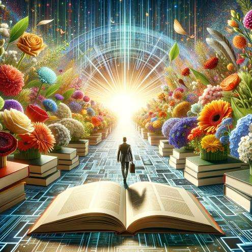

图4.18 咖哥走在花语秘境中

图片表现力可圈可点，既有鲜花装点，又突出了董事长是一位不折不扣的文学青年：他以图书为基座，在鲜花盛开的康庄大道上向前走——向着写出100本精品图书的目标迈进！

小雪：董事长？！

### 4.4.7 自主创建PPT

现在我们已拥有创建PPT所需的全部素材。最后一步马上开始！

这里，我们可以通过python-pptx库为助手提供PPT模板。这些模板包括设置PPT的布局、背景颜色，添加图片、文本框，以及定制字体样式和大小。

我们会定义两个模板，一个是首页模板，一个是内页模板 。

首先通过多行字符串模板title_template（首页模板）定义一个包含图像、标题和副标题的PPT模板。

```
# 导入相关库和工具
from pptx import Presentation
from pptx.util import Inches, Pt
from pptx.enum.text import PP_PARAGRAPH_ALIGNMENT
from pptx.dml.color import RGBColor
# 初始化首页模板
title_template = """
# 创建新的PPT对象
prs = Presentation()
# 添加一个空白的PPT布局
blank_slide_layout = prs.slide_layouts[6]
slide = prs.slides.add_slide(blank_slide_layout)
# 将PPT的背景颜色设置为黑色
background = slide.background
fill = background.fill
fill.solid()
fill.fore_color.rgb = RGBColor(0, 0, 0)
# 在PPT左侧添加图片，上下留有边距
left = Inches(0)
top = Inches(0)
height = prs.slide_height
width = prs.slide_width * 3/5
pic = slide.shapes.add_picture(image_path, left, top, width=width, height=height)
# 在较高位置添加标题文本框
left = prs.slide_width * 3/5
top = Inches(2)
width = prs.slide_width * 2/5
height = Inches(1)
title_box = slide.shapes.add_textbox(left, top, width, height)
title_frame = title_box.text_frame
title_p = title_frame.add_paragraph()
title_p.text = title_text
title_p.font.bold = True
title_p.font.size = Pt(38)
title_p.font.color.rgb = RGBColor(255, 255, 255)
title_p.alignment = PP_PARAGRAPH_ALIGNMENT.CENTER
# 添加副标题文本框
left = prs.slide_width * 3/5
top = Inches(3)
width = prs.slide_width * 2/5
height = Inches(1)
subtitle_box = slide.shapes.add_textbox(left, top, width, height)
subtitle_frame = subtitle_box.text_frame
subtitle_p = subtitle_frame.add_paragraph()
subtitle_p.text = subtitle_text
subtitle_p.font.size = Pt(22)
subtitle_p.font.color.rgb = RGBColor(255, 255, 255)
subtitle_p.alignment = PP_PARAGRAPH_ALIGNMENT.CENTER
"""
```

接下来通过多行字符串模板details_template（内页模板）定义一个包含图像、标题和“关键见解：”文本（含项目符号列表）的PPT模板。

```
# 初始化内页模板
details_template = """
# 创建新的PPT对象
prs = Presentation()
# 添加一个空白的PPT布局
blank_slide_layout = prs.slide_layouts[6]
slide = prs.slides.add_slide(blank_slide_layout)
# 将PPT的背景颜色设置为黑色
background = slide.background
fill = background.fill
fill.solid()
fill.fore_color.rgb = RGBColor(0, 0, 0)
# 定义占位符
image_path = data_vis_img
title_text = "提升利润：在线销售与直销优化的主导地位"
bullet_points = "• 在线销售在各个季度中始终领先于盈利能力，这表明存在强大的数字市场。\n• 直销表现出波动，这表明该渠道的表现变化和进行针对性改进的必要性。"
# 在PPT左侧添加图片占位符
left = Inches(0.2)
top = Inches(1.8)
height = prs.slide_height - Inches(3)
width = prs.slide_width * 3/5
pic = slide.shapes.add_picture(image_path, left, top, width=width, height=height)
# 添加覆盖整个宽度的标题文本
left = Inches(0)
top = Inches(0)
width = prs.slide_width
height = Inches(1)
title_box = slide.shapes.add_textbox(left, top, width, height)
title_frame = title_box.text_frame
title_frame.margin_top = Inches(0.1)
title_p = title_frame.add_paragraph()
title_p.text = title_text
title_p.font.bold = True
title_p.font.size = Pt(28)
title_p.font.color.rgb = RGBColor(255, 255, 255)
title_p.alignment = PP_PARAGRAPH_ALIGNMENT.CENTER
# 添加硬编码的“关键见解：”文本和项目符号列表
left = prs.slide_width * 2/3
top = Inches(1.5)
width = prs.slide_width * 1/3
height = Inches(4.5)
insights_box = slide.shapes.add_textbox(left, top, width, height)
insights_frame = insights_box.text_frame
insights_p = insights_frame.add_paragraph()
insights_p.text = "关键见解："
insights_p.font.bold = True
insights_p.font.size = Pt(24)
insights_p.font.color.rgb = RGBColor(0, 128, 100)
insights_p.alignment = PP_PARAGRAPH_ALIGNMENT.LEFT
insights_frame.add_paragraph()
bullet_p = insights_frame.add_paragraph()
bullet_p.text = bullet_points
bullet_p.font.size = Pt(12)
bullet_p.font.color.rgb = RGBColor(255, 255, 255)
bullet_p.line_spacing = 1.5
"""
```

最后一步！用submit_message_wait_completion提交消息——传入必要的参数，包括模板、标题、副标题和附加的文件ID，并指示助手使用上述模板来创建PPT。之后等待助手完成任务即可。

```
title_text = "花语秘境"
subtitle_text = "2025年销售大会"

submit_message_wait_completion(assistant.id,thread,f"通过包含的代码模板创建符合模板格式的PPT，但使用本消息中包含的图片、公司名称/标题和文件名/副标题：\
{title_template}。重要提示：在第一张PPT中使用本消息中包含的图片文件作为image_path图像，并使用公司名称 {title_text} 作为title_text变量，\
  使用副标题文本 {subtitle_text} 作为subtitle_text变量。\
    接着，使用以下代码模板创建第二张PPT：{data_vis_template}，创建符合模板格式的PPT，但使用公司名称/标题和文件名/副标题：\
{data_vis_template}。重要提示：使用您之前在本线程中创建的第二张附图（折线图）作为data_vis_img图像，并使用您之前创建的数据可视化标题作为title_text变量，\
  使用您之前创建的见解项目符号列表作为bullet_points变量。将这两张PPT输出为pptx格式的文件。确保输出为两张PPT，且每张PPT都符合本消息中给出的相应模板。",
              file_ids=[dalle_file.id, plot_file.id]
)


# 等待助手完成PPT创建任务
while True:
    try:
        response = get_response(thread)
        pptx_id = response.data[0].content[0].text.annotations[0].file_path.file_id
        print("成功检索到 pptx_id:", pptx_id)
        break
    except Exception as e:
        print("您的助手正在努力制作幻灯片……")
        time.sleep(10)

import io
pptx_id = response.data[0].content[0].text.annotations[0].file_path.file_id
ppt_file= client.files.content(pptx_id)
file_obj = io.BytesIO(ppt_file.read())
with open(“咖哥花语秘境.pptx”, “wb”) as f:
    f.write(file_obj.getbuffer())
```

[output not shown]

[figure not shown]

## 4.5 小结

4.1节~4.3节对什么是Assistants API，如何使用Assistants API，以及Thread、Run、Message等概念、工具和操作流程，做了很好的解释和演练。

最主要的内容——4.4节介绍如何使用OpenAI公司的Assistants API以及GPT-4模型和DALL·E 3模型来制作信息丰富且视觉上吸引人的PPT。

在实操中，首先，展示了如何加载销售数据，并利用Assistants API作为数据科学助理来生成数据可视化的图或表。这个过程包括统计每个季度的销售额，并将其以折线图的形式进行展示。

其次，Assistants API根据生成的图或表提供了一些见解，并创建了适合PPT的标题。然后，通过DALL·E 3模型，根据公司的概述生成一张PPT首页图片。

最后，使用python-pptx库和一些预设模板，通过Assistants API来创建PPT。这个过程把所有元素结合起来，包括标题、图表、见解以及由DALL·E 3模型生成的图片，最终生成两张不错的PPT。

# 第5章 Agent 2：多功能选择的引擎 ——通过 Function Calling调用函数

从地铁站到公司的路上有座自然历史博物馆，咖哥和小雪走了进去（见图5.1）。

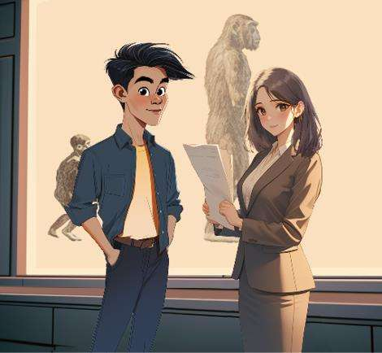

图5.1 咖哥和小雪参观博物馆

小雪：咖哥，人类能够从古代猿类进化而来，在很大程度上是因为我们学会使用工具。人类进化历程中工具使用的重要性对我们在人工智能领域的研究有所启示吗？

咖哥：学会使用工具的确是进化过程中的一个关键转折点。除了工具的使用增强人类的生存能力以外，使用工具的过程促进了人类认知能力的发展，包括解决问题、规划和抽象思维能力。这些能力的发展为人类文明的进步奠定了基础。

咖哥指了指海报上猿人手中的石头，说：这块石头看着简单吧？但对早期的人类来说，这可能是一把切割食物的刀，可能是一件用来狩猎的武器，也可能是一件发生危险时用来防身的武器。工具使他们能完成更多类型、更复杂的任务，同时效率也更高。

如果Agent面对复杂的任务时只能靠自己来解决，那么它的能力是非常有限的。但如果它能根据不同的任务调用外部的功能或服务，那么它的能力将得到极大增强（见图5.2）。

[figure not shown]

图5.2 人类和AI都学会用工具完成任务

小雪：你这样一说，我自然而然地联想起Playground中Assistants的工具（Tools）。这些工具先在OpenAI内部定义好，然后由Agent自主调用吗？

## 5.1 OpenAI中的Functions

4.2节提到Assistants中的工具可以分为3种类型——Functions、Code interpreter和File search，如图5.3所示。

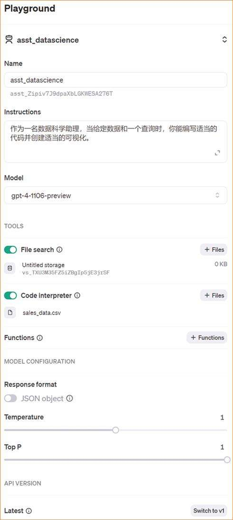

图5.3 Assistants中的Tools

在这些工具中，我们已经通过Code interpreter编写了进行数据分析的代码，而File search的作用是在上传的文件中自动检索信息。这两个工具是封装在OpenAI内部的——无论是在Assistants还是在OpenAI API中，都可以直接使用。它们是OpenAI的内部工具。

现在重点说一说Functions，这可以是由我们开发者定制的工具。

### 5.1.1 什么是Functions

用OpenAI公司的话说，Functions是一个开发者工具，旨在提供特定领域的能力来扩展和增强OpenAI公司的大模型的功能。它允许开发者创建和部署自定义函数，这些函数可以执行特定的任务、处理复杂的查询或者提供专业化的回答。通过Functions，开发者可以利用OpenAI公司的大模型的强大功能来构建更加丰富和动态的应用。

就像人类决定何时用刀割、何时用锤敲一样，Assistants通过Functions，可以根据当前任务的需要，选择并调用最合适的外部函数或工具。这样，Agent就可以在自己的训练过程中掌握尚未完备的技能，从而更加灵活和高效地处理各种复杂的任务。

Functions的主要特点如下。

■ 定制化：开发者可以根据特定需求定制函数，以处理特定类型的问题。

■ 集成：这些函数可以集成到现有的应用或服务中。

■ 扩展性：随着需求的变化和技术的发展，开发者可以更新和扩展函数的功能。

Functions让大模型可以连接到外部工具 ，从而赋予开发者更多的灵活性和创造力，以促进和加速AI在各种行业和领域中的应用。

### 5.1.2 Function的说明文字很重要

小雪：我最疑惑的就是，Assistants是怎么知道什么时候应该调用什么工具的呢？

咖哥：对于Code interpreter和File search这两个内部工具，OpenAI内部自有一套处理逻辑，用于指导Assistants判断哪些场景需要调用哪些工具。对于我们自己定制的Function，你给出的Description（说明文字）特别重要。Description就是Assistants用于判断是否应该调用这个工具的依据。

[figure not shown]

图5.4 在Playground中默认的Function示例

如果我告诉它“你的任务是根据今天的气温来安排鲜花的存储”，那么会不会调用这个工具呢？

小雪点点头：助手应该会想到有这么个工具。

### 5.1.3 Function定义中的Sample是什么

小雪：不过，我这儿又有一个新疑问。上面的这段示例代码就是Function中要实现的功能？

咖哥：错了，小雪。有一点你要特别注意，上面这段看上去像代码的文本，其实不是代码段，而是对函数接口的JSON格式的描述（即JSON Schema），其目的是让大模型智能地输出一个包含用于调用一个或多个函数的参数的JSON对象。 这个说明只是函数的“元数据”，描述了如何使用这个函数。具体的实现代码需要在主程序中编写。当这个函数被调用时，所编写的实现代码会执行相应的操作（例如查询天气）并返回 结果 。

其中，get_weather的函数的元数据包含以下几个关键部分。

name：函数的名称。

description：函数的描述，解释函数的用途。

parameters：参数的定义，描述了该函数需要什么样的数据输入。

■ type：指示参数是一个对象。

■ properties：描述了这个对象应该拥有的属性，例如location和unit。其中，location，应该是一个字符串，表示要查询天气信息的城市和州；unit，一个字符串，表示温度的单位，可能的值是“c”（摄氏度）或“f”（华氏度）。

■ required：这个列表指示哪些属性是必需的，对于这个函数，location是必需的。

###### 咖哥发言

JSON（JavaScript Object Notation）是一种轻量级数据交换格式，它基于文本，易于开发者阅读和编写，也易于机器解析和生成。它是一种用于存储和传输数据的格式，通常用于服务器和Web应用程序之间的数据交换。

再强调一遍，在把工具传递给大模型之后，大模型不会真的调用工具中的代码，相反，大模型会生成 JSON格式的字符串。开发者应先解析，然后使用它来调用代码中的函数（具体功能的实现其实是掌握在开发者手中的，其逻辑由开发者在后续代码中封装完成）。对于初学者，这一点特别“绕”，但在看完我们后面介绍的几个示例之后，就会觉得清晰了。

###### 咖哥发言

并非OpenAI公司的所有模型都支持Functions，只有经过训练的较新的模型（如GPT-3.5 Turbo和GPT-4）可以检测何时应调用函数（这取决于所输入的提示信息和Functions中的说明文字），而且经过相关训练的新模型比之前的模型能更紧密地按照JSON格式进行响应。

### 5.1.4 什么是Function Calling

解释清楚Functions的定义后，我们继续探讨什么是Function Calling。

Function Calling是GPT-3.5 Turbo和GPT-4等模型的新功能。这个功能允许开发者用JSON Schema描述函数。大模型可以智能地输出一个包含用于调用一个或多个函数的参数的JSON对象。

Function Calling是连接GPT模型的自然语言理解能力与外部工具或API的桥梁，可以使从大模型中获取结构化数据或基于大模型输出触发外部动作的方式更为可靠。

Functions调用的基本步骤如下。

1.定义函数及元数据：定义好你要做的事情的函数和元数据（JSON Schema）。把JSON Schema提交给大模型。

2.提出请求：告诉系统想做什么，例如查询天气信息。这个请求需要包含必要的信息，如地点。

3.模型生成命令：系统会根据用户的请求决定调用哪个功能。如果该请求与系统中的某个函数匹配，系统就会创建一个包含所有必要信息的字符串，这个字符串符合事先定义的JSON Schema的要求。

4.执行函数：系统首先把文本解析为JSON对象，然后根据这个JSON对象执行对应的函数。如果命令中包括地点信息，那么JSON对象中也会包含统一的地点信息。相应地，函数会去查找那个地点的天气信息。

5.返回结果：一旦函数执行完毕，系统会返回结果。这个结果也是用JSON格式来表示的。通常会把这个结果再次传递回大模型，让它生成最终的回答，也就是输出有关该地点天气信息的文本。

我们可以将上述步骤用表5.1展示。

表5.1 Functions的调用步骤

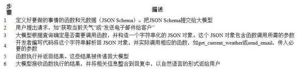

小雪：咖哥，你这么解释我就基本清楚了。在OpenAI公司的文档中，有时我们看到的Functions指的是要调用的函数的接口定义部分；有时我们看到的Function Calling指的是通过大模型生成符合函数调用接口格式的字符串的过程，你还需要把它解析为JSON对象，然后再调用自己定义的函数功能。

简单来说，这是一个把自然语言（如查询成都的温度、给鲜花加价20%）变成一个计算机函数能够读懂的JSON Schema的过程。

咖哥：说得真好，就是这么回事。表5.2给出了更多Function定义的示例。

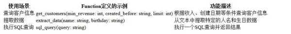

## 5.2 在Playground中定义Function

在本节中，咱们通过具体示例实现这个流程。我们要创建一个简单且有趣的Function，它是一个“鼓励生成器”，接受用户的名字和当前心情，然后返回一条定制化的鼓励消息。

这个Function的功能简单直接，代码行数小于20行。

```
# 鼓励函数
def get_encouragement(name, mood):
    # 基础鼓励消息
    messages = {
        "happy": "继续保持积极的心态，做得好！",
        "sad": "记住，即使在最黑暗的日子里，也会有阳光等着你。",
        "tired": "你做得足够好，现在是时候休息一下了。",
        "stressed": "深呼吸，一切都会好起来。"
    }

    # 获取对应心情的鼓励消息
    message = messages.get(mood.lower(), "你今天感觉如何？我总是在这里支持你！")

    # 返回定制化的鼓励消息
    return f"亲爱的{name}，{message}"
# 使用示例
print(get_encouragement("小雪", "tired"))
```

```
亲爱的小雪，你做得足够好，现在是时候休息一下了。
```

其中，get_encouragement函数首先接收两个参数——用户的名字和当前心情。然后，根据用户的心情，从预设的消息中选择一句合适的鼓励语并返回。

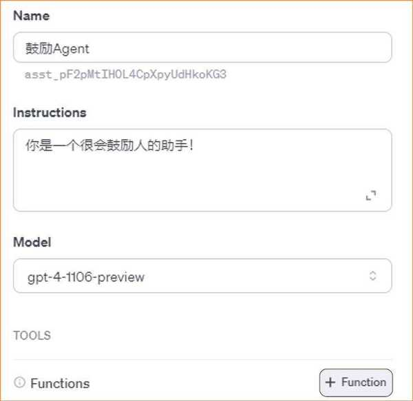

图5.5 在Playground中创建助手，并添加Function

咖哥：正确。

小雪：接下来输入与前面类似的代码到Function中（见图5.6），是这样吗？

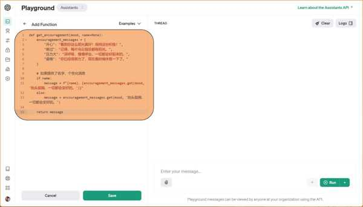

图5.6 小雪在Function中添加了具体实现代码

咖哥：非也，非也！你是不是忘了我刚才反复提醒的事情了？！这里要添加的不是Function的具体实现代码，而是对函数及其参数的JSON格式的描述（JSON Schema），也就是函数的元数据。

下面才是“鼓励函数”get_encouragement的JSON Schema 正确的示例。

```
{
    "name": "get_encouragement",
    "description": "根据用户的心情提供鼓励信息",
    "parameters": {
      "type": "object",
      "properties": {
        "mood": {
          "type": "string",
          "description": "用户当前的心情，例如：开心，难过，压力大，疲倦"
        },
        "name": {
          "type": "string",
          "description": "用户的名字，用来个性化鼓励信息"
        }
      },
      "required": ["mood"]
    }
}
```

把这个JSON Schema添加到Function中（见图5.7）。

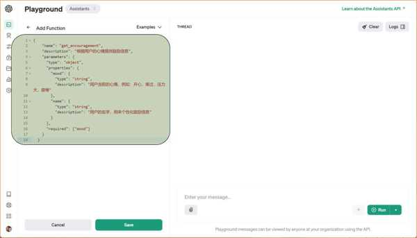

图5.7 应将JSON Schema添加到Function中

接下来，我们在Playground中通过Run调用这个助手，让它为“伤心的小雪生成鼓励的话语”（见图5.8）。

[figure not shown]

图5.8 运行助手

可以看到，助手此时并没有生成具体的鼓励话语。这是因为在这个节点，还没有出现具体的Function功能。助手生成的是一行合规的函数调用代码。

```
get_encouragement({ "mood": "难过", "name": "小雪" })
```

小雪：那么函数的具体功能应如何实现呢？

## 5.3 通过Assistants API实现Function Calling

前面介绍了如何在Playground中创建一个助手并定义其Function，在本节中，我们将通过Assistants API完成Function Calling的整个流程。

Function Calling的整体框架如图5.9所示。

[figure not shown]

图5.9 Function Calling的整体框架（图片来源：Medium网站）

图5.9的中心思想是：先定义工具来描述函数，再通过Function Calling智能地返回需要调用的函数及其参数——在整个过程中，我们可以把非结构化的文本语言转化成结构化的JSON描述。

接下来我们完成Function Calling实操。在此之前，有必要先回顾一下表4.1中Run的各种状态。

Function Calling的总体流程是：当触发用户消息时，助手会启动一个Run；如果在Run中，助手确定应进行Function Calling，它会暂停执行Run，并将Run的状态转变为requires_action；助手返回需要调用的Function及其参数的JSON数据；开发者在代码内部调用自己的函数功能；本地代码执行完毕后，通过提交函数的回调结果来完成Run。

小雪：感觉有点复杂。

咖哥：这里面的确有“坑”。接下来我们详细分析这个过程。

### 5.3.1 创建能使用Function的助手

首先创建一个助手。当然，在5.2节中，我们已经在Playground中创建了一个助手（见图5.10）。

[figure not shown]

图5.10 已经创建的助手

既然已经有了助手，就不必浪费资源重新创建。可以根据ID获取已有的助手（这里为鼓励Agent）。

```
# 读取系统变量
from dotenv import load_dotenv
load_dotenv()
# 初始化client
from openai import OpenAI
client = OpenAI()
# 检索之前创建的助手
assistant_id = "asst_pF2pMtIHOL4CpXpyUdHkoKG3" # 你自己的助手的ID
assistant = client.beta.assistants.retrieve(assistant_id)
print(assistant)
```

```
助手的信息:
Assistant(id='asst_pF2pMtIHOL4CpXpyUdHkoKG3', created_at=1705829118, description=None, file_ids=[], instructions='你是一个很会鼓励人的助手！', metadata={}, model='gpt-4-turbo-preview', name='鼓励Agent', object='assistant', tools=[ToolFunction(function=FunctionDefinition(name='get_encouragement', description='根据用户的心情提供鼓励信息', parameters={'type': 'object', 'properties': {'mood': {'type': 'string', 'description': '用户当前的心情，例如 ：开心，难过，压力大，疲倦'}, 'name': {'type': 'string', 'description': '用户的名字，用来个性化鼓励信息'}}, 'required': ['mood']}), type='function')])
```

当然，如果想要通过Assistants API创建一个新的助手也不难，可以参考下面的代码。

```
assistant = client.beta.assistants.create(
    instructions="You are a very encouraging assistant!",
    model="gpt-4-turbo-preview",
    tools=[{
        "type": "function",
        "function": {
            "name": "get_encouragement",
            "description": "根据用户的心情提供鼓励信息",
            "parameters": {
                "type": "object",
                "properties": {
                    "mood": {
                        "type": "string",
                        "description": "用户当前的心情，例如：开心，难过，压力大，疲倦"
                    },
                    "name": {
                        "type": "string",
                        "description": "用户的名字，用来个性化鼓励信息"
                    }
                },
                "required": ["mood"]
            }
        }
    }]
)
```

上述代码在创建助手时定义了一个Function，其产生的效果如同我们之前在Playground中添加的JSON Schema产生的。